# Algebra Qualifying Exam Review

# 1 Topics and Remarks

(DZG) on the structure of these notes: these are *extremely* disorganized at the moment, and only reflect some amalgamation of all of the random notes I made to myself while studying for qualifying exams. As a result, things are bound to be out of order, and likely useless pedagogically unless you’ve seen most of the material before. Moreover, this has been a long-running document (started in my undergrad years, so pre-2018), and since I’ve forgotten and rewritten certain things at various points, there may even be duplicated material (e.g. propositions stated/proved in multiple places, repeated exercises or statements, etc).

In any case, I’d love to hear if you do find it useful! Readers are welcome to email me with any questions, comments, errors/typos, suggestions for improvement, or just to say hello! 😄

Adapted from remark written by Roy Smith, August 2006:

“As a general rule, students are responsible for knowing both the theory (proofs) and practical applications (e.g. **how to find the Jordan or rational canonical form** of a given matrix, **or the Galois group of a given polynomial**) of the topics mentioned.”

## 1.1 General References

- David Dummit and Richard Foote, Abstract Algebra, Wiley, 2003. [1]
- Kenneth Hoffman and Ray Kunze, Linear Algebra, Prentice-Hall, 1971. [2]
- Thomas W. Hungerford, Algebra, Springer, 1974. [3]
- Roy Smith, Algebra Course Notes (843-1 through 845-3). [4]
  - Note: scroll down the page to find links to his course notes.

## 1.2 Group Theory

> References: [1], [3], [4] “The first 6 chapters (220 pages) of Dummit and Foote are excellent. All the definitions and proofs of these theorems on groups are given in Smith’s web based lecture notes for math 843 part 1.”

### 1.2.1 Topics

Chapters 1-9 of Dummit and Foote

- **The first isomorphism theorem**,
- Fundamental theorem of finite abelian groups
- Left and right cosets
- Normalizer
- Lagrange’s theorem
- Isomorphism theorems
- Lagrange’s Theorem
- Group generated by a subset
- Subgroups and quotient groups
- Fundamental homomorphism theorems
- Direct and semi-direct products
  - Recognition of internal direct product
  - Recognition of semi-direct product
- Composite groups
- Structures of special types of groups such as:
  - p-groups
  - Dihedral,
    - Cyclic groups
    - Free groups
      - Generators and relations
  - Symmetric and Alternating groups
    - Cycle decompositions
- Group actions with applications to the structure of groups such as
  - **The Sylow Theorems**
    - Proof of Sylow theorems
  - Orbit stabilizer theorem
  - Orbits act on left cosets of subgroups
  - Action of $G$ on itself by conjugation
  - Class equation
  - Cayley’s theorem
- The simple groups of order between 60 and 168 have prime order
- The simplicity of $A_n$, for $n \geq 5$
- Solvable groups
- Subgroups of index $p$, the smallest prime dividing $\# G$, are normal
- $p$-groups
- $p^2$ groups are abelian
- Automorphisms
  - Inner automorphisms
- $A_n$ is simple for $n\geq 5$
- Classification of groups of order $pq$
- Commutator subgroup
- Nilpotent groups
- Upper central series
- Lower central series
- Derived series
- Solvable groups
- Fratini’s argument
- The Jordan Holder theorem

> The proof of Jordan-Holder is seldom tested on the qual**, but proofs are always of interest.

## 1.3 Linear Algebra

> References: [1],[2],[4]

### 1.3.1 Topics

- Determinants
- Eigenvalues and eigenvectors
- Cayley-Hamilton Theorem
- Canonical forms for matrices
- Linear groups ($\operatorname{GL}_n , {\operatorname{SL}}_n, \mathrm{O}_n, \mathrm{U}_n$)
- Duality
  - Dual spaces,
  - Dual bases,
  - Induced dual map,
  - Double duals
- Finite-dimensional spectral theorem

## 1.4 Rings

> References: [1],[3],[4]
- DF chapters 13,14 (about 145 pages).
- Smith:
  - 843-2, sections 11,12, and 16-21 (39 pages)
  - 844-1, sections 7-9 (20 pages)
  - 844-2, sections 10-16, (37 pages)
- DF Chapters 7, 8, 9.

### 1.4.1 Topics

- Properties of ideals and quotient rings
- The fundamental isomorphism theorems for rings
- $I$ maximal iff $R/I$ is a field
- Zorn’s lemma
  - Every vector space has a basis
  - Maximal ideals exist
  - Construct algebraic field closures
  - Why it is unnecessary in countable or noetherian rings.

  > Smith discusses extensively in 844-1.
- Chinese Remainder Theorem
- Euclidean algorithm
- Primes and irreducibles
- Gaussian integers
- Localization of a domain
- Field of fractions
- Factorization in domains
- Factorization in $Z[i]$
- Characterizations and properties of special rings such as:
  - Euclidean $\implies$ PID $\implies$ UFD
  - Domains
    - Primes are irreducible
  - UFDs
    - Have GCDs
    - Sometimes PIDs
  - PIDs
    - Noetherian
    - Irreducibles are prime
    - Are UFDs
    - Have GCDs
    - Results about PIDs *(DF Section 8.2)*
      - Example of a PID that is not a Euclidean domain *(DF p.277)*
      - Proof that a Euclidean domain is a PID and hence a UFD
      - Proof that ${\mathbb{Z}}$ and $k[x]$ are UFDs *(p.289 Smith, p.300 DF)*
      - A polynomial ring in infinitely many variables over a UFD is still a UFD *(Easy, DF, p.305)*
  - Euclidean domains
    - Are PIDs
- Gauss’s important theorem on unique factorization of polynomials:
  - ${\mathbb{Z}}[x]$ is a UFD
  - $R[x]$ is a UFD when $R$ is a UFD
- Polynomial rings
- Polynomials
  - Gauss’ lemma
  - Remainder and factor theorem
  - Eisenstein’s criterion *(DF p.309)* > Stated only for monic polynomials – proof of general case identical. > See Smith’s notes for the full version.
  - Reducibility
  - Rational root test
- Cyclic product structure of $({\mathbb{Z}}/n{\mathbb{Z}})^{\times}$

  > Exercise in DF, Smith 844-2, section 18
- Gröbner bases and division algorithms for polynomials in several variables *(DF 9.6.)*

## 1.5 Modules

> References: [1],[3],[4]

### 1.5.1 Topics

- Fundamental homomorphism theorems for rings and modules
- Applications to the structure of:
  - Finitely generated abelian groups
  - Canonical forms of matrices
- Classification of finitely generated modules over PIDs *(with emphasis on Euclidean Domains)*
- Modules over PIDs and canonical forms of matrices. *DF sections 10.1, 10.2, 10.3, and 12.1, 12.2, 12.3.*
  - Constructive proof of decomposition: DF Exercises 12.1.16-19

  > Smith 845-1 and 845-2: Detailed discussion of the constructive proof.

## 1.6 Field Theory

### 1.6.1 Topics

> References: [1],[3],[4]
- Algebraic extensions of fields
- Properties of finite fields
- Separable extensions
- Fundamental theorem of Galois theory
- Computations of Galois groups
  - of polynomials of small degree
  - of cyclotomic polynomials
- Solvability of polynomials by radicals

# 2 Group Theory

Summary of useful qual tips:

- Slightly obvious but good to remember:
  - Subgroups of abelian groups are automatically normal.
  - If $N$ is normal in $G$, then $N$ is normal in any subgroup containing it.
  - If $N\leq G$ is the unique group of order $\# N$, then $N$ is normal (since any conjugate must have the same size).
  - Using the subgroup correspondence: if $L/H\leq G/H$ then $L\leq G$ has size $\#(L/H)\#H$.
- Sizes and structure:
  - Quotienting by bigger groups yields smaller indices:
    $$\begin{align*}
    1 \leq H \leq H \leq K \leq G \quad\text{ apply} [G: {-}] &&\implies \# G = [G:1] \geq [G:H] \geq [G:K] \geq [G:G] = 1
    .\end{align*}$$
  - $x$ is central iff $[x] = \left\{{e}\right\}$.
  - Unions aren’t (generally) subgroups, intersections always are.
  - Coprime order subgroups intersect trivially.
  - Distinct subgroups of order $p^n, p^m$ can intersect trivially *or* in subgroups of order $p^{\ell}$.
- Conjugacy:
  - Sizes of conjugacy classes divide $\# G$ (by orbit-stabilizer).
  - Conjugate subgroups have equal cardinality.
  - Normal subgroups absorb conjugacy classes, and are thus unions of conjugacy classes.
  - Reasoning about conjugacy classes: in $S_n$ they’re precisely determined by cycle type, i.e. a partition of $n$.
  - Remembering the class equation: for literally any group action $\phi: G\curvearrowright X$, one has $X = \mathrm{Fix} (\phi) {\textstyle\coprod}' {\mathrm{Orb}}(x_i)$ as a disjoint union of fixed points and nontrivial orbits, since orbits partition $X$. Then take your action to be $G\curvearrowright G$ by $\phi: g.x\mathrel{\vcenter{:}}= gxg^{-1}$ to get $\mathrm{Fix} (\phi) = Z(G)$ and ${\mathrm{Orb}}(x_i) = \left\{{gx_ig^{-1}}\right\} = [x_i]$ the conjugacy classes. Now apply orbit stabilizer to get ${\mathrm{Orb}}(x) \cong G/{\operatorname{Stab}}(x)$ where ${\operatorname{Stab}}(x) = Z(x) = C_G(x)$ the centralizer.
- Cosets:
  - Cosets partition a group.
  - Anything dealing with indices $[G:H]$: try just listing the cosets.
  - $aH = bH \iff ab^{-1}\in H$.
  - Showing subgroup containment: $K \subseteq H$ iff $kH = H$ for all $k\in K$.
- Sylows:
  - If $S_p$ is normal, then $S_p$ is characteristic. This is useful if $H\leq G$ and $P\in{\operatorname{Syl}}_p(H)$ is normal in $H$, then $P$ is also normal in $G$.

## 2.1 Big List of Notation

I use the following notation throughout:

| Notation | Definition |
| --- | --- |
| $C_G(x)$ | Centralizer of an element $\mathrel{\vcenter{:}}=\left\{{g\in \Gamma {~\mathrel{\Big\|}~}[g, x] = 1}\right\} \subseteq \Gamma$ |
| $C_G(H)$ | Centralizer of an subgroup $\mathrel{\vcenter{:}}=\left\{{g\in \Gamma {~\mathrel{\Big\|}~}[g, x] = 1\,\, \forall h\in H}\right\} = \displaystyle\bigcap_{h\in H} C_H(h) \subseteq G$ |
| $C(H)$ | Conjugacy Class $\mathrel{\vcenter{:}}=\left\{{ ghg ^{-1} {~\mathrel{\Big\|}~}g\in G}\right\} \leq G \subseteq G$ |
| $Z(G)$ | Center $\mathrel{\vcenter{:}}=\left\{{ x\in G {~\mathrel{\Big\|}~}\forall g\in G,\, gxg ^{-1} = x }\right\} \subseteq G$ |
| $N_G(H)$ | Normalizer $\mathrel{\vcenter{:}}=\left\{{ g\in G {~\mathrel{\Big\|}~}gHg ^{-1} = H }\right\} \subseteq G$ |
| $\mathrm{Inn}(G)$ | Inner Automorphisms $\mathrel{\vcenter{:}}=\left\{{ \varphi _g(x) \mathrel{\vcenter{:}}= gxg ^{-1} }\right\} \subseteq \mathop{\mathrm{Aut}}(G)$ |
| $\mathrm{Out}(G)$ | Outer Automorphisms $\mathop{\mathrm{Aut}}(G) / \mathop{\mathrm{Inn}}(G) \mapsfrom \mathop{\mathrm{Aut}}(G)$ |
| $[g h]$ | Commutator of Elements $\mathrel{\vcenter{:}}= ghg ^{-1} \in G$ |
| $[G H]$ | Commutator of Subgroups $\mathrel{\vcenter{:}}=\left\langle{ \left\{{ [gh] {~\mathrel{\Big\|}~}g \in G,\, h \in H }\right\} }\right\rangle \leq G$ |
| ${\mathcal{O}}_x,\, Gx$ | Orbit of an Element $\mathrel{\vcenter{:}}=\left\{{ gx {~\mathrel{\Big\|}~}x \in X}\right\}$ |
| $\mathrm{Stab}_G(x),\, G_x$ | Stabilizer of an Element $\mathrel{\vcenter{:}}=\left\{{ g \in G {~\mathrel{\Big\|}~}gx = x }\right\} \subseteq G$ |
| $X/G$ | Set of Orbits $\mathrel{\vcenter{:}}=\left\{{ G_x {~\mathrel{\Big\|}~}x \in X }\right\} \subseteq 2^X$ |
| $X^g$ | Fixed Points $\left\{{x \in X {~\mathrel{\Big\|}~}\forall g \in G,\, gx = x}\right\} \subseteq X$ |
| $2^X$ | The powerset of $X$ $\mathrel{\vcenter{:}}=\left\{{ U \subseteq X }\right\}$ |

For any $p$ dividing the order of $G$, $\mathrm{Syl}_p(G)$ denotes the *set* of Sylow${\hbox{-}}p$ subgroups of $G$.

## 2.2 Definitions

An set morphism that is *either* injective or surjective between sets of the same size is automatically a bijection. It turns out that a group morphism between groups of the same size that is either injective or surjective is automatically a bijection, and the inverse is automatically a group morphism, so bijective group morphisms are isomorphisms.

If $a, b\in {\mathbb{Z}}$ with $\gcd(a, b) = d$, then there exist $s,t\in {\mathbb{Z}}$ such that
$$\begin{align*}
as + bt = d
.\end{align*}$$

This $d$ can be computed using the extended Euclidean algorithm.

Useful context clue! In particular, this works when $a, b$ are coprime and $d=1$, since you can write $x^1 = x^{as + bt} = x^{as}x^{bt}$ to get interesting information about orders of elements. If you see “coprime” in a finite group question, try the division algorithm.

The **order** of an element $g\in G$, denoted $n \mathrel{\vcenter{:}}= o(g)$, is the smallest $n\in {\mathbb{Z}}^{\geq 0}$ such that $g^n = e$.

Show that the order of any element in a group divides the order of the group.

An expression of the form $G = \left\langle{S {~\mathrel{\Big|}~}R}\right\rangle$ where $S$ is a set of elements and $R$ a set of words defining relations means that $G \mathrel{\vcenter{:}}= F[S] / { \operatorname{cl}} _n(R)$ where $F[S]$ is the free group on the set $S$ and ${ \operatorname{cl}} _n(R)$ is the normal closure, the smallest normal subgroup of $F[S]$ containing $R$.

Finding morphisms between presentations: if $G$ is presented with generators $g_i$ with relations $r_i$ and $H$ is any group containing elements $h_i$ also satisfying $r_i$, there is a group morphism
$$\begin{align*}
\phi: G &\to H \\
g_i &\mapsto h_i \quad \forall i
.\end{align*}
Why this exists: the presentation yields a surjective morphism \(\pi: F(g_i) \to G\) with \(G\cong F(g_i) / \ker \pi\). Define a map \(\psi: F(g_i) \to H\) where \(g_i\mapsto h_i\), then since the \(h_i\) satisfy the relations \(r_i\), \(\ker \pi \subseteq \ker \psi\). So \(\psi\) factors through \(\ker \pi\) yielding a morphism \(F/\ker \pi \to H\).$$

## 2.3 Subgroups

A subset $H\subseteq G$ is a **subgroup** iff

1. Closure: $HH \subset H$
2. Identity: $e\in H$
3. Inverses: $g\in H \iff g^{-1}\in H$.

If $H\subset G$, then $\left\langle{H}\right\rangle$ is the smallest subgroup containing $H$:
$$\begin{align*}
\left\langle{H}\right\rangle = \cap\left\{{H{~\mathrel{\Big|}~}H\subseteq M \leq G}\right\} M = \left\{{ h_1^{\pm 1} \cdots h_n^{\pm 1} {~\mathrel{\Big|}~}n\geq 0, h_i \in H}\right\}
\end{align*}
where adjacent \(h_i\) are distinct.$$

The **commutator subgroup** of $G$ is denoted $[G, G] \leq G$. It is the subgroup *generated* by all elementary commutators:
$$\begin{align*}
[G, G] \mathrel{\vcenter{:}}=\left\langle{ aba^{-1}b^{-1}{~\mathrel{\Big|}~}a, b\in G }\right\rangle
.\end{align*}
It is the smallest normal subgroup \(N{~\trianglelefteq~}G\) such that \(G/N\) is abelian, so if \(H\leq G\) and \(G/H\) is abelian, \(H\subseteq [G, G]\).$$

> Note that elements in $[G, G]$ are generally *products* of elementary commutators, and not elementary themselves, since we’re taking the group generated by them.

If $H \subseteq G$ and $a,b\in H \implies ab^{-1}\in H$, then $H\leq G$.

**(Click to expand proof)**

- Identity: $a=b=x\implies xx^{-1}=e\in H$
- Inverses: $a=e, b=x \implies x^{-1}\in H$.
- Closure: let $x, y\in H$, then $y^{-1}\in H$ by above, so $xy = x(y^{-1})^{-1}\in H$.
- Show that the intersection of two subgroups is again a subgroup.
  - Hint: one-step subgroup test.
- Show that if $H\mathrel{\vcenter{:}}= C_m, K\mathrel{\vcenter{:}}= C_n \leq G$ are cyclic, then $H \cap K = C_{d}$ where $d \mathrel{\vcenter{:}}=\gcd(m, n)$.
- Show that the intersection of two subgroups with coprime orders is trivial.
- Show that the union of two subgroups $H, K$ is a subgroup iff $H \subset K$, and so is generally *not* a subgroup.
- Show that subgroups with the *same* prime order are either equal or intersect trivially.
- **Important for Sylow theory**: show (perhaps by example) that if $S_1, S_2$ are distinct subgroups of order $p^k$, then it’s possible for their intersection to be trivial **or** for them to intersect in a subgroup of order $p^\ell$ for $1\leq \ell \leq k-1$.
- Give a counterexample where $H,K\leq G$ but $HK$ is not a subgroup of $G$.

## 2.4 Conjugacy

The **conjugacy class** of $h$ is defined as
$$\begin{align*}
C(h) \mathrel{\vcenter{:}}=\left\{{ ghg^{-1}{~\mathrel{\Big|}~}g\in G }\right\}
.\end{align*}$$

$[e] = \left\{{ e }\right\}$ is always in a conjugacy class of size one – this is useful for counting and divisibility arguments. Conjugacy classes are **not** subgroups in general, since they don’t generally contain $e$. However, by orbit-stabilizer and the conjugation action, their sizes always divide the order of $G$.

**Useful qual fact**: $[x] = \left\{{ x }\right\} \iff x\in Z(G)$, i.e. having a trivial conjugacy class is the same as being central.

Two subgroups $H, K \leq G$ are **conjugate** iff there exists some $g\in G$ such that $gHg^{-1}= K$. Note that all conjugate subgroups have the same cardinality.

Show that the size of a conjugacy class divides the order of a group.

Show that if $H < G$ is a proper subgroup, then $\displaystyle\bigcup_{g\in G} gHg^{-1}\subset G$ is a proper subset.

> Hint: consider the intersection and count. Try Orbit-stabilizer?

**(Click to expand solution)**

Strategy: bound the cardinality. All conjugates of $H$ have the same cardinality, say $\# H = m$. Suppose there are $n$ distinct conjugates of $H$. Then they intersect only at the identity, so count their elements:
$$\begin{align*}
\# \displaystyle\bigcup_{g\in G} gHg^{-1}= 1 + n(m-1)
.\end{align*}
Use that \(n = [G: N_G(H)]\) by Orbit-Stabilizer, and \(N_G(H) \leq G \implies n \leq n' \mathrel{\vcenter{:}}=[G:H]\). Now note \(n'm = \# H[G:H] = \# G\) by Lagrange:
\begin{align*}
\# \displaystyle\bigcup_{g\in G} gHg^{-1}
&= 1 + n(m-1) \\
&\leq 1 + n'(m-1) \\
&= 1 + n'm -n' \\
&= 1 + \# G - n' \\
&= \# G - (n' - 1) \\
&< \# G && \iff n' \mathrel{\vcenter{:}}=[G:H] > 1
.\end{align*}$$

Show that normal groups absorb conjugacy classes: if $N{~\trianglelefteq~}G$ and $[g_i]$ is a conjugacy class in $g$, either $[g_i] \subseteq N$ or $[g_i] \cap N = \emptyset$.

Prove that the size of a conjugacy class of $g_i$ is the index of its centralizer, $[G: Z(g_i)] \mathrel{\vcenter{:}}=[G: C_G(g_i)]$.

### 2.4.1 Normal Subgroups

A subgroup $N\leq G$ is **normal** iff $gH = Hg$ for every $g\in G$, or equivalently $gHg^{-1}= H$ for all $g$, so $H$ has only itself as a conjugate. We denote this by $N{~\trianglelefteq~}G$. Equivalently, for every inner automorphism $\psi \in \mathop{\mathrm{Inn}}(G)$, $\psi(N) = N$.

$N{~\trianglelefteq~}G \iff N = {\textstyle\coprod}' [h_i]$ is a disjoint union of conjugacy classes, where the index set for this union is one $h_i$ from each conjugacy class.

**(Click to expand proof)**

Note that $C(h_i) = \left\{{ gh_i g^{-1}{~\mathrel{\Big|}~}g\in G }\right\}$, and $gh_i g^{-1}\in H$ since $H$ is normal, so $C(h_i) \subseteq G$ for all $i$. Conversely, if $C(h_i) \subseteq H$ for all $h_i \in H$, then $gh_ig^{-1}\in H$ for all $i$ and $H$ is normal.

- Show that if $H, K {~\trianglelefteq~}G$ and $H\cap K = \emptyset$, then $hk=kh$ for all $h\in H,k\in K$.
- Show that if $H,K{~\trianglelefteq~}G$ are normal subgroups that intersect trivially, then $[H, K] = 1$ (so $hk = kh$ for all $k$ and $h$).

Prove that if $G$ is a $p{\hbox{-}}$group, every subgroup $N{~\trianglelefteq~}G$ intersects the center $Z(G)$.

> Hint: use the class equation.

**(Click to expand solution)**

Another solution:

- Idea: use the class equation to force $p$ to divide $\#(H \cap Z(G))$. Applying it to $H$ yields
  $$\begin{align*}
  H = Z(H) {\textstyle\coprod}_{i=1}^m [h_i]
  ,\end{align*}
  where the \([h_i]\) are conjugacy classes of size greater than 1.$$
- Now use that $Z(H) = Z(G) \cap H$, and since $p$ divides the LHS the result will follow if $p$ divides the size of the disjoint union on the RHS.
- This is true because each $\#[h_i] \neq 1$ and $[h_i]$ divides $\# H$ which divides $\# G$ which is a power of $p$. So $p\divides \# [h_i]$ for each $i$.

## 2.5 Centralizing and Centers

The **centralizer of an element** is defined as
$$\begin{align*}
Z(h) \mathrel{\vcenter{:}}= C_G(h) \mathrel{\vcenter{:}}=\left\{{ g\in G {~\mathrel{\Big|}~}ghg^{-1}= h }\right\}
,\end{align*}
the elements of \(G\) the stabilize \(h\) under conjugation.$$

The **centralizer of a subset** $H$ is defined as
$$\begin{align*}
Z(H) \mathrel{\vcenter{:}}= C_G(H) \mathrel{\vcenter{:}}=\displaystyle\bigcap_{h\in H} C_G(h) \mathrel{\vcenter{:}}=\left\{{g\in G {~\mathrel{\Big|}~}ghg^{-1}= h ~\forall h\in H}\right\}
,\end{align*}
the elements of \(G\) that simultaneously stabilize all of \(H\) pointwise under conjugation.$$

$$\begin{align*}
N_G(H) = \left\{{g\in G {~\mathrel{\Big|}~}gHg^{-1}= H}\right\} = \displaystyle\bigcup_{M\in S} M, \quad S \mathrel{\vcenter{:}}=\left\{{H{~\mathrel{\Big|}~}H {~\trianglelefteq~}M \leq G}\right\}
\end{align*}
Contrast to the centralizer: these don’t have to fix \(H\) pointwise, but instead can permute elements of \(H\).$$

$C_G(S) {~\trianglelefteq~}N_G(H)$ for any $H$.

The **center** of $G$ is defined as \begin{align*} Z(G) = \left\{{ g\in G {~\mathrel{\Big|}~}[g, h] = e \, \forall h\in H}\right\} = \left\{{ g\in G {~\mathrel{\Big|}~}Z(g) = G }\right\} ,\end{align*} the subgroup of *central* elements: those $g\in G$ that commute with every element of $G$.

- Show that if $G/Z(G)$ is cyclic then $G$ is abelian.
- Show that $G/N$ is abelian iff $[G, G] \leq N$.
- Show that normal subgroups are not necessarily contained in $Z(G)$.
  - Hint: consider the order 3 subgroup of $S_3$.

**(Click to expand solution)**

The $G/Z(G)$ theorem:

- Write $H\mathrel{\vcenter{:}}= Z(G)$ and $G/H = \left\langle{xH}\right\rangle$ as a cyclic quotient.
- Fix $a, b\in G$, then $aH = x^n H$ and $bH = x^m H$.
- So $ax^{-n} = h_1, bx^{-m} = h_2$ where the $h_i$ are now central.
- Now write $ab = (x^n h_1)(x^m h_2) = ba$ by commuting everything.

## 2.6 Cosets

$$\begin{align*}
K\leq H \leq G \implies [G: K] = [G:H] [H: K]
.\end{align*}$$

If $H\leq K \leq G$, then
$$\begin{align*}
\# G = [G:1] \geq [G:H] \geq [G:K] \geq [G:G] = 1
.\end{align*}
In particular, If \(H, K\leq G\) are just arbitrary, since \(H \cap K \leq H, K\) we have \([H: H \cap K] \geq [G:H] \text{ and } [G:K]\).$$

**(Click to expand proof)**

Write $G/H \cap K \mathrel{\vcenter{:}}= G/J = \left\{{ h_1J, \cdots, h_m J }\right\}$ as distinct cosets where $m\mathrel{\vcenter{:}}=[G:H]$ and the $h_i$ are all in $H$. Then $i\neq j\implies h_i h_j^{-1}\not \in H \cap K$, but $h_i h_j^{-1}\in H$ since subgroups are closed under products and inverses, which forces $h_i h_j^{-1}\not\in K$. So $h_i K \neq h_j K$, meaning there are at least $m$ cosets in $G/K$, so $[G:K] \geq m$.

Any two cosets $xH, yH$ are either equal or disjoint.

**(Click to expand proof)**

- $x\in xH$, since $e\in H$ because $H$ is a subgroup and we can take $h=e$ to get $x = xe \mathrel{\vcenter{:}}= xh \in xH$.
- The reverse containment is clear, so $G = \displaystyle\bigcup_{x\in G} xH$ is a union of its cosets.
- Suppose toward a contradiction that $\ell \in xH \cap yH$ we’ll show $xH = yH$.
- Write $\ell =xh_1 =yh_2$ for some $h_i$, then
  $$\begin{align*}
  xh_1 = yh_2 &\implies x = yh_2 h_1^{-1}\\
  xh_3\in xH &\implies xh_3 = (yh_2h_1^{-1}) h_3 \in yH
  ,\end{align*}
  so \(xH \subseteq yH\).$$
- A symmetric argument shows $y_H \subseteq xH$.[^1]

$$\begin{align*}
aH = bH \iff a^{-1}b \in H \iff b^{-1}a\in H
.\end{align*}$$

**(Click to expand proof)**

[^2]
$$\begin{align*}
aH = bH \iff a\in bH \iff a=bh \text{ for some } h \iff b^{-1}a = h \iff ba^{-1}\in H
.\end{align*}$$

The **index** $[G: H]$ of a subgroup $H\leq G$ is the number of left (or right) cosets $gH$.

If you can reduce a problem to showing $X \subseteq H$, it suffices to show $xH = H$ for all $x\in X$.

Cosets form an equivalence relation and thus partition a group. Nice trick: write $G/H = \left\{{ g_1 H, g_2 H,\cdots, g_n H }\right\}$, then $G = {\textstyle\coprod}_{i\leq n} g_i H$.

If $H{~\trianglelefteq~}G$ and $G$ is finite then
$$\begin{align*}
[G: H] = {\left\lvert {G/H} \right\rvert} = {{\left\lvert {G} \right\rvert} \over {\left\lvert {H} \right\rvert}}
.\end{align*}$$

Show that if $G$ is finite then ${\left\lvert {G} \right\rvert}/{\left\lvert {H} \right\rvert} = [G: H]$.

## 2.7 Special Groups

A **dihedral group** of order $2n$ is given by
$$\begin{align*}
D_n = \left\langle{r, s {~\mathrel{\Big|}~}r^n, s^2, rsr^{-1}= s^{-1}}\right\rangle = \left\langle{r, s {~\mathrel{\Big|}~}r^n, s^2, (rs)^2 }\right\rangle
\end{align*}
The \(r\) is a cycle of length \(n\), and \(s\) is a reflection.$$

Examples of explicit cycle presentations:

- $D_4 = \left\langle{(1,2,3,4), (1,3)}\right\rangle$ which is a $2\pi/4$ rotation and a reflection through the diagonal line $y=-x$ in a square.
- $D_5 = \left\langle{(1,2,3,4,5), (1,5)(2,4)}\right\rangle$ which is a $2\pi/5$ rotation and a reflection about the line through vertex $3$ in a pentagon.

The **Quaternion group** of order 8 is given by
$$\begin{align*}
Q &= \left\langle{x,y,z {~\mathrel{\Big|}~}x^2 = y^2 = z^2 = xyz = -1}\right\rangle \\
&= \left\langle{x, y {~\mathrel{\Big|}~}x^4 = y^4, x^2 = y^2, yxy^{-1}= x^{-1}}\right\rangle
\end{align*}
Mnemonic: multiply clockwise to preserve sign, counter-clockwise to negate sign. Everything squares to \(-1\), and the triple product is \(-1\):$$

[figure not shown]

> Link to Diagram

A subgroup $H\leq S_n$ is **transitive** iff its action on $\left\{{1, 2, \cdots, n}\right\}$ is transitive, i.e. for each pair $(i, j)$ there is some element $\sigma\in H$ such that $\sigma(i) = j$. Note that $\sigma$ may not fix other elements, and can have other effects!

If ${\left\lvert {G} \right\rvert} = p^k$, then $G$ is a **p-group.**

### 2.7.1 Cyclic Groups

$G$ is cyclic of order $n \mathrel{\vcenter{:}}=\# G$ iff $G$ has a unique subgroup of order $d$ for each $d$ dividing $n$.

**(Click to expand proof)**

$\impliedby$: Use that $\sum_{d\divides n} \phi(d) = n$, and that there are at most $\phi(d)$ elements of order $d$, forcing equality.

$\implies$: If $G = \left\langle{ a }\right\rangle$ with $a^n=e$, then for each $d\divides n$ take $H_d \mathrel{\vcenter{:}}=\left\langle{ a^{n\over d} }\right\rangle$ for existence.

- Show that any cyclic group is abelian.
- Show that every subgroup of a cyclic group is cyclic.
- Show that
  $$\begin{align*}\phi(n) = n \prod_{p\mathrel{\Big|}n}\qty{1 - {1\over p}}.\end{align*}$$
- Compute $\mathop{\mathrm{Aut}}({\mathbb{Z}}/n{\mathbb{Z}})$ for $n$ composite.
- Compute $\mathop{\mathrm{Aut}}(\qty{{\mathbb{Z}}/p{\mathbb{Z}}}^n)$.

### 2.7.2 Symmetric Groups

The transposition presentation:
$$\begin{align*}
S_n \mathrel{\vcenter{:}}=\left\langle{ \sigma_1, \cdots, \sigma_{n-1} {~\mathrel{\Big|}~}\sigma_i^2, [\sigma_i, \sigma_j]\, (j\neq i+1), \sigma_i \sigma_{i+1} \sigma_i = \sigma_{i+1} \sigma_i \sigma_{i+1} }\right\rangle
.\end{align*}$$

Writing a cycle as a product of transpositions, the map defined by
$$\begin{align*}
\operatorname{sgn}: S_n &\to ({\mathbb{Z}}/2, +) \\
\prod_{i\leq 2k} (a_i b_i) &\mapsto 0 \\
\prod_{i\leq 2k+1} (a_i b_i) &\mapsto 1
.\end{align*}$$

- The kernel is the alternating group:
  - **Even** cycles
  - For a single cycle: has **odd** length
  - Have an **even** number of even length cycles.
  - Can be written as an **even** number of transpositions.
  - Examples: $(1,2,3)$ or $(1,2)(3,4)$ in $S_4$.
  - Non-examples: $(1,2)$ or $(1,2,3,4)$ in $S_4$, since they have an odd number of even length cycles.
- The fiber over 1 is everything else:
  - **Odd** cycles
  - For a single cycle: has **even** length
  - Have an **odd** number of even length cycles.
  - Can be written as an **odd** number of transpositions

> Mnemonic: the cycle parity of a $k{\hbox{-}}$cycle is the usual integer parity of $k-1$.

The **alternating group** is the subgroup of **even** permutations, i.e.
$$\begin{align*}
A_n \mathrel{\vcenter{:}}=\left\{{\sigma \in S_n {~\mathrel{\Big|}~}\operatorname{sgn}(\sigma) = 0}\right\}
.\end{align*}
These are the permutations with an even number of even length cycles.$$

For $n\geq 3$, $A_n$ is generated by 3-cycles.

**(Click to expand proof)**

- $(ab)(ab) = ()$
- $(ab)(ac) = (abc)$
- $(ab)(cd) = (abc)(adc)$.

$$\begin{align*}
A_3 =
\left\{{ \operatorname{id}, (1,2,3), (1,3,2) }\right\}
,\end{align*}
which has cycle types \((1,1,1)\) and \((3)\).$$

$$\begin{align*}
A_4 =
& \{\operatorname{id}, \\
& (1,3)(2,4),
(1,2)(3,4),
(1,4)(2,3), \\
& (1,2,3),
(1,3,2), \\
& (1,2,4),
(1,4,2), \\
& (1,3,4),
(1,4,3), \\
& (2,3,4),
(2,4,3) \}
,\end{align*}
which has cycle types \((1,1,1,1), (2,2), (3, 1)\).$$

$A_5$ is too big to write down, but has cycle types

- $(1,1,1,1,1)$
- $(2,2,1)$
- $(3,1,1)$
- $(5)$
- $\sigma \circ (a_1 \cdots a_k)\circ \sigma^{-1} = (\sigma(a_1), \cdots \sigma(a_k))$
- Conjugacy classes are determined by cycle type
- The order of a cycle is its length.
- The order of an element is the least common multiple of the sizes of its disjoint cycles.
- Disjoint cycles commute.
- $A_{n\geq 5}$ is *simple*.

## 2.8 Exercises

- Show that if $G$ is a finite group acting transitively on a set $X$ with at least two elements, then there exists $g \in G$ which fixes no point of $X$.
- Let $p$ be prime. For each abelian group $K$ of order $p^2$, how many subgroups $H\leq {\mathbb{Z}}^{\times 3}$ are there with ${\mathbb{Z}}^3/H \cong K$?
- Let $\# G = pq$, with $p,q$ distinct primes. Show that $G$ has a nontrivial proper normal subgroup, and if $p\not\equiv 1\operatorname{mod}q$ and $q\not \equiv 1 \operatorname{mod}p$ then $G$ is abelian.
- Let $G$ be a finite group and let $p$ be the smallest prime dividing $\# G$, and assume $G$ has a normal subgroup of order $p$. Show that $H \subset Z(G)$.
- Let $G$ be finite and $P$ a Sylow 2-subgroup. Assume $P$ is cyclic and generated by $x$. Show that the sign of the permutation of $G$ corresponding to $x\mapsto gx$ is 1, and deduce that $G$ has a nontrivial quotient of order 2.

## 2.9 Counting Theorems

$$\begin{align*}H \leq G \implies \# H \divides \# G.\end{align*}
Moreover, there is an equality \([G:H] = \# G/ \# H\) when \(G\) is finite.$$

**(Click to expand proof)**

Write $G/H = \left\{{g_0 H, g_1 H, \cdots, g_N H}\right\}$ for some $N \mathrel{\vcenter{:}}=[G:H]$. Since cosets are equal or disjoint and have equal cardinality,
$$\begin{align*}
G = {\textstyle\coprod}_{k \leq N} g_k H \implies \#G = \sum_{k\leq N} \# \qty{g_k H} = \sum_{k\leq N} \# H = N \# H
,\end{align*}
so \(\# G = N \# H\), \(\#H\) divides \(\# G\) and \(N = [G:H]\) divides \(\# G\).$$

$$\begin{align*}
\# G = \#(G/H) \#H \mathrel{\vcenter{:}}=[G:H] \, \# H
,\end{align*}
or written another way,
\begin{align*}
\#(G/H) = \# G/ \# H
.\end{align*}$$

The order of every element divides the size of $G$, i.e.
$$\begin{align*}
g\in G \implies o(g) \divides o(G) \implies g^{{\left\lvert {G} \right\rvert}} = e
.\end{align*}$$

There do **not** necessarily exist $H \leq G$ with ${\left\lvert {H} \right\rvert} = n$ for every $n \divides {\left\lvert {G} \right\rvert}$. Counterexample: take $G = A_5$, then $\# G = 5!/2 = 60$ but $G$ has no subgroup of order $30$. If it did, this would be index 2 and thus normal, but $A_{n\geq 5}$ is simple.

Another direct counterexample: ${\left\lvert {A_4} \right\rvert} = 12$ but has no subgroup of order 6. If such an $H$ existed, it can’t contain every 3-cycle, since $A_4$ is generated by 3-cycles. For $x$ any 3-cycle *not* in $H$, use that $\# A_4/H = 2$ and consider $H, xH, x^2H$. $x\not\in H$, so $H\neq xH$, but two must be equal:

- $x^2H = H$: use $x^2 = x^{-1}$ since $x^3=e$, but $x\in H \implies x^{-1}\in H$, $\contradiction$
- $xH = x^2H$: the fundamental theorem of cosets forces $x^{-1}x^2 \in H$, so $x\in H$. $\contradiction$

For every prime $p$ dividing ${\left\lvert {G} \right\rvert}$. there is an element (and thus a subgroup) of order $p$.

> This is a partial converse to Lagrange’s theorem, and strengthened by Sylow’s theorem.

**(Click to expand proof)**

See https://kconrad.math.uconn.edu/blurbs/grouptheory/cauchypf.pdf.

## 2.10 Group Actions

An action of $G$ on $X$ is a group morphism
$$\begin{align*}
\phi:G \times X &\rightarrow X \\
(g,x) &\mapsto g x
\end{align*}
or equivalently
\begin{align*}
\phi: G &\to \mathop{\mathrm{Aut}}(X) \\
g &\mapsto (x \mapsto \phi_g (x) \mathrel{\vcenter{:}}= g\cdot x)
\end{align*}
satisfying$$

1. $e\cdot x = x$
2. $g\cdot (h\cdot x) = (gh)\cdot x$

For a group $G$ acting on a set $X$,

| Notation | Definition |
| --- | --- |
| ${\mathcal{O}}(x) = Gx = \left\{{g\cdot x {~\mathrel{\Big\|}~}g\in G}\right\} \subseteq X$ | Orbit |
| ${\operatorname{Stab}}(x) = G_x = \left\{{ g \in G {~\mathrel{\Big\|}~}g\cdot x=x }\right\} \leq G$ | Stabilizer |
| $X/G \subseteq 2^X$ | Set of Orbits |
| $\mathrm{Fix} = X^G = \left\{{x\in X {~\mathrel{\Big\|}~}g\cdot x = x\, \forall g\in G}\right\} \subseteq X$ | Set of Fixed Points |

Note that being in the same orbit is an equivalence relation which partitions $X$, and $G$ acts transitively if restricted to any single orbit. Also, $x\in \mathrm{Fix}$ iff ${\mathrm{Orb}}(x) = \left\{{x}\right\}$ and ${\operatorname{Stab}}_G(x) = G$.

For any group action, the kernel is the intersection of all stabilizers:
$$\begin{align*}
\ker \psi = \displaystyle\bigcap_{x\in X} G_x
.\end{align*}$$

A group action $G\curvearrowright X$ is **transitive** iff for all $x, y\in X$ there exists a $g\in G$ such that $g\cdot x = x$. Equivalently, the action has a single orbit.

If $G\curvearrowright X$ transitively, then for any choice of $x\in X$ there is an isomorphism of sets given by
$$\begin{align*}
\Phi: G/G_{x} &\xrightarrow{\sim} X \\
gG_{x} &\mapsto g\curvearrowright x
.\end{align*}$$

**(Click to expand proof)**

- Injectivity: $\Phi(gG_x) = \Phi(hG_x) \iff g\curvearrowright x=h\curvearrowright x \iff gh^{-1}\curvearrowright x = x \iff gh^{-1}\in G_x \iff gG_x = hG_x$.
- Well-definedness: use $gG_x = hG_x \iff gh^{-1}\in G_x \iff g^{-1}h \curvearrowright x = x$. Then $g (g^{-1}h) \curvearrowright x = g \curvearrowright x$ on one hand, and on the other $(gg^{-1})h\curvearrowright x = h\curvearrowright x$, so
  $$\begin{align*}
  \Phi(hG_x) \mathrel{\vcenter{:}}= h\curvearrowright x = (gg^{-1}) h\curvearrowright x = g(g^{-1}h)\curvearrowright x = g\curvearrowright x = \Phi(gG_x)
  .\end{align*}$$
- Surjectivity: equivalent to the action being transitive.

If $X\in {G{\hbox{-}}\mathsf{Set}}$, then for any points $x_i\in X$ in the same orbit, the stabilizers $G_{x_0}$ and $G_{x_1}$ are conjugate.

Note that if $G$ acts transitively, this says all stabilizers are conjugate.

**(Click to expand proof)**

- Fix $x\in X$ and $y\in {\mathrm{Orb}}(x)$, so $g.x=y$ for some $g$.
- Let $H_x \mathrel{\vcenter{:}}={\operatorname{Stab}}(x)$ and $H_y\mathrel{\vcenter{:}}={\operatorname{Stab}}(y)$, the claim is that $H_x = g^{-1}H_y g$.
- Now just check:
  $$\begin{align*}
  h\in H_x &\iff hx = x \\
  &\iff hg^{-1}y = g^{-1}y \\
  &\iff ghg^{-1}y = y \\
  &\iff ghg^{-1}\in H_y \\
  &\iff h\in g^{-1}H_y g
  ,\end{align*}
  so \(H_x = g^{-1}H_y g\).$$

$$\begin{align*}\# {Gx} = [G: G_x] = \# {G} / \#{G_x} \quad \text{if $G$ is finite}
.\end{align*}$$

> Mnemonic: $G/G_x \cong Gx$.

## 2.11 Examples of Orbit-Stabilizer and the Class Equation

A useful mnemonic: for any group action $\phi: G\curvearrowright X$, using that orbits partition $X$ we always have
$$\begin{align*}
X = \mathrm{Fix} (\phi) \displaystyle\coprod_{x}' {\mathrm{Orb}}(x)
,\end{align*}
where \(\mathrm{Fix} (\phi)\) is the union of all orbits of size 1, and the remaining union is over distinct nontrivial orbits, taking one representative \(x\) from each.$$

An application of group actions: if $G$ is simple, $H < G$ proper, and $[G:H] = n$, then there exists an injective map $\phi: G \hookrightarrow S_n$.

**(Click to expand proof)**

- Define a group action $\phi: G\curvearrowright G/H \mathrel{\vcenter{:}}=\left\{{eH, g_1 H, \cdots, g_{n-1} H}\right\}$ acting on the $n$ cosets of $H$ by left-translation $g.(g_k H) = (gg_k) H$.
- Then use that $\operatorname{Sym}(G/H) \leq S_n$, so $\operatorname{im}\phi \leq S_n$ is a subgroup.
- Since $G$ is simple and $\ker \phi \leq G$, we have $\ker \phi = 1, G$. If $\ker \phi = 1$, $\phi$ is injective and we’re done.
- Otherwise $\ker \phi = G$, and acting on $eH$ yields $gH = H$ for all $g$, forcing $H=G$ and $n=1$, contradicting that $H<G$ is proper. $\contradiction$

### 2.11.1 Left Translation

Let $G$ act on itself by left translation, where $\phi: g \mapsto (h\mapsto gh)$.

- The orbit ${\mathrm{Orb}}(x) = G$ is the entire group.
  - This action is transitive.
- The set of fixed points $\mathrm{Fix} (\phi) = \left\{{g\in G {~\mathrel{\Big|}~}gx=x \,\forall x\in G }\right\} = \left\{{ e }\right\}$ is just the identity.
- The stabilizer ${\operatorname{Stab}}(x) = \left\{{ g\in G{~\mathrel{\Big|}~}gx=x }\right\} = \left\{{ e }\right\}$ is just the identity.
- The kernel is the identity.
- Orbit stabilizer just says $G \cong G/\left\{{e}\right\}$.

### 2.11.2 Conjugation: The Class Equation and Burnside’s Lemma

Let $G$ act on *itself* by conjugation, so $\phi: g.x = gxg^{-1}$.

- The orbit ${\mathrm{Orb}}(g) = [g]$ is the **conjugacy class** of $g$.
  - Thus the action is transitive iff $G$ has only one single conjugacy class, which can only happen if $\# G = 1, 2$. On the other extreme, the orbits are all size 1 iff $G$ is abelian.
- The set of fixed points $\mathrm{Fix} (\phi) = Z(G)$ is the **center**.
- The stabilizer is ${\operatorname{Stab}}(g) = Z(g)$, the **centralizer** of $g$ in $G$.
- The kernel is the intersection of all centralizers, i.e. again the **center** $Z(G)$.
- Orbit-stabilizer says $[g] = G/Z(g)$, so **the size of a conjugacy class is the index of the centralizer**.

Worth reiterating: $[G: Z(g)]$ is the number of elements in the conjugacy class $[g]$, and each $g \in Z(G)$ has a singleton conjugacy class $[g] = \left\{{g}\right\}$. Applying the fixed-point count trick and substituting in orbit-stabilizer yields
$$\begin{align*}
G &= \mathrm{Fix} (\phi) \displaystyle\coprod_{x}' {\mathrm{Orb}}(x) \\
&= Z(G) \displaystyle\coprod_{g}' [g]\\
&= Z(G) \displaystyle\coprod_{g}' {G\over Z(g) }
.\end{align*}$$

Now taking cardinalities yields the class equation:

$$\begin{align*}
\# {G} = \# {Z(G)} + \sum_{\substack{\text{One $g$ from} \\ \text{each nontrivial} \\ \text{conj. class}}} [G: Z(g)]
\end{align*}$$

As a reminder,
$$\begin{align*}
Z(g) &= \left\{{h\in G {~\mathrel{\Big|}~}hgh^{-1}= g}\right\} \text{ is the centralizer of } g\\
Z(G) &= \left\{{h\in G {~\mathrel{\Big|}~}hgh^{-1}= g\,\, \forall g\in G}\right\} = \displaystyle\bigcap_{g\in G} Z(g) \text{ is the center of } G
.\end{align*}$$

- Show that $p$ groups have nontrivial centers.
- Show that groups of order $p^2$ are abelian.

**(Click to expand solution)**

$p{\hbox{-}}$groups have nontrivial centers:

- Abusing notation by identifying sets with their cardinalities, the class equation says $G = Z(G) + \sum_{g}' [G: Z(g)]$ where the terms in the sum are all bigger than 1.
- Reducing mod $p$ yields $0 = Z(g) + 0$, since $p$ must divide $[G:Z(g)]$ when $[G:Z(g)] > 1$ because $G = [G:Z(g)]Z(g)$ and $p$ divides the LHS.
- So $p$ divides $Z(g)$, making $Z(g)$ nontrivial.

$p^2$ groups are abelian:

- $Z(G) = 1,p,p^2$, and by above we know $Z(G)\neq 1$. If $Z(G) = p^2$ we’re done, so assume $Z(G) = p$.
- Then $G/Z(G) = p$ and groups of order $p$ are cyclic, so the $G/Z(G)$ theorem applies and $G$ is abelian.

For $G$ a finite group acting on $X$,
$$\begin{align*}
\# {X/G} = \frac{1}{\# G }\sum_{g\in G} \# \mathrm{Fix} (g)
,\end{align*}
where \(X/G = \left\{{{\mathrm{Orb}}(x_1), \cdots, {\mathrm{Orb}}(x_n)}\right\}\) is the set or orbits and \(\mathrm{Fix} (g) = \left\{{x\in X {~\mathrel{\Big|}~}gx=x}\right\}\) are the fixed points under \(g\).$$

> Slogan: the number of orbits is equal to the average number of fixed points.

**(Click to expand proof)**

Strategy: form the set $A \mathrel{\vcenter{:}}=\left\{{ (g,x) \in G\times X {~\mathrel{\Big|}~}g\curvearrowright x = x }\right\}$ and write/count it in two different ways. Write ${\operatorname{Stab}}(x) = \left\{{g\in G {~\mathrel{\Big|}~}gx=x}\right\}$ and $\mathrm{Fix} (g) = \left\{{x\in X{~\mathrel{\Big|}~}gx = x}\right\}$.

First union over $G$, where the inner set lets $x$ vary:
$$\begin{align*}
A = \displaystyle\coprod_{g_0\in G} \left\{{ (g_0, x) {~\mathrel{\Big|}~}g_0 x = x }\right\} \cong \displaystyle\coprod_{g_0\in G} \left\{{g_0}\right\}\times \mathrm{Fix} (g_0) \subseteq G\times X
.\end{align*}$$

Then union over $X$, where the inner set lets $g$ vary:
$$\begin{align*}
A = \displaystyle\coprod_{x_0\in X} \left\{{ (g, x_0) {~\mathrel{\Big|}~}gx_0= x_0 }\right\} \cong \displaystyle\coprod_{x_0\in X} {\operatorname{Stab}}(x_0) \times\left\{{ x_0 }\right\} \subseteq G\times X
.\end{align*}
Taking cardinalities, and using the fact that \(\left\{{p}\right\} \times A \cong A\) as sets for any set \(A\), we get the following equality
\begin{align*}
\sum_{g_0\in G} \# \mathrm{Fix} (g_0)
= \# A
= \sum_{x_0\in X} \# {\operatorname{Stab}}(x_0)
.\end{align*}$$

Now rearrange orbit-stabilizer:
$$\begin{align*}
{\mathrm{Orb}}(x_0) = G/{\operatorname{Stab}}(x_0) \implies \# {\operatorname{Stab}}(x_0) = \# G/ \# {\mathrm{Orb}}(x_0)
,\end{align*}
and use this to rewrite the RHS:
\begin{align*}
\sum_{g_0\in G} \# \mathrm{Fix} (g_0)
&= \sum_{x_0\in X} \# {\operatorname{Stab}}(x_0) \\
&= \sum_{x_0\in X} {\# G \over \# {\mathrm{Orb}}(x_0)} \\
&= \# G \sum_{x_0\in X} {1 \over \# {\mathrm{Orb}}(x_0)} \\ \\
\implies {1\over \# G} \sum_{g_0\in G} \# \mathrm{Fix} (g_0)
&= \sum_{x_0\in X} {1\over \# {\mathrm{Orb}}(x_0)}
,\end{align*}
so it suffices to show the right-hand side sum is the number of orbits, \(\#(X/G)\).$$

Proceed by partitioning the sum up according to which orbit each term comes from:
$$\begin{align*}
\sum_{x_0\in X}\qty{1\over \# {\mathrm{Orb}}(x_0)}
&= \sum_{{\mathrm{Orb}}(x_0) \in X/G} \qty{ \sum_{y\in {\mathrm{Orb}}(x_0)} \qty{1\over \# {\mathrm{Orb}}(x_0)} }\\
&= \sum_{{\mathrm{Orb}}(x_0) \in X/G} \qty{1\over \# {\mathrm{Orb}}(x_0)}\sum_{y\in {\mathrm{Orb}}(x_0)} 1 \\
&= \sum_{{\mathrm{Orb}}(x_0) \in X/G} \qty{1\over \# {\mathrm{Orb}}(x_0)} \# {\mathrm{Orb}}(x_0) \\
&= \sum_{{\mathrm{Orb}}(x_0) \in X/G} 1 \\
&= \#(X/G)
.\end{align*}$$

### 2.11.3 Conjugation on Subgroups

Let $G$ act on $X \mathrel{\vcenter{:}}=\left\{{H {~\mathrel{\Big|}~}H\leq G}\right\}$ (its set of *subgroups*) by conjugation.

- The orbit ${\mathcal{O}}(H) = \left\{{gHg^{-1}{~\mathrel{\Big|}~}g\in G}\right\}$ is the **set of conjugate subgroups** of $H$.
  - This action is transitive iff all subgroups are conjugate.
- The fixed points $\mathrm{Fix} (G)$ form the set of **normal subgroups** of $G$.
- The stabilizer ${\operatorname{Stab}}(H) = N_G(H)$ is the **normalizer** of $H$ in $G$.
- The kernel is the intersection of all normalizers: $\ker \phi = \displaystyle\bigcap_{H\leq G} N_G(H)$.
- Applying Orbit-stabilizer yields that the number of conjugates is the index of the normalizer:
  $$\begin{align*}
  \# {\left\{{ gHg ^{-1} {~\mathrel{\Big|}~}g \in G }\right\} } = [G: N_G(H)]
  .\end{align*}$$

### 2.11.4 Left Translation on Cosets

For a fixed proper subgroup $H< G$, let $G$ act on its cosets $X \mathrel{\vcenter{:}}= G/H \mathrel{\vcenter{:}}=\left\{{gH{~\mathrel{\Big|}~}g\in G}\right\}$ by left translation.

- The orbit ${\mathcal{O}}(xH) = G/H$, the entire set of cosets.
  - Note that this is a *transitive* action, since the trivial coset $eH\in G/H$ and its orbit is $gH$ as $g$ ranges over $G$, hitting every coset representative.
- The stabilizer ${\operatorname{Stab}}(xH) = xHx^{-1}$, a **conjugate subgroup** of $H$.
  - This is because
    $$\begin{align*}
    {\operatorname{Stab}}(xH) &= \left\{{g\in G{~\mathrel{\Big|}~}gxH = xH}\right\} \\
    &= \left\{{g\in G {~\mathrel{\Big|}~}x^{-1}g x\in H}\right\} \\
    &= \left\{{g\in G{~\mathrel{\Big|}~}gx\in xH}\right\}\\
    &= \left\{{g\in G{~\mathrel{\Big|}~}g\in xHx^{-1}}\right\} \\
    &= xHx^{-1}
    .\end{align*}$$
- There are no fixed points, i.e. $\mathrm{Fix} (G) = \emptyset$, since the action is transitive.
- The kernel of this action is $\ker \phi = \displaystyle\bigcap_{g\in G} gHg^{-1}$, the intersection of all conjugates of $H$, sometimes called the **normal core** of $H$.
  - Note that if $\ker \phi = G$ then $H$ is normal, and if $\ker \phi = 1$ then at least one conjugate doesn’t intersect $H$ nontrivially.

If $G$ is a finite group and $p\mathrel{\vcenter{:}}=[G:H]$ is the smallest prime dividing $\# G$, then $H{~\trianglelefteq~}G$.

**(Click to expand proof)**

- Let $\phi: G\curvearrowright X\mathrel{\vcenter{:}}=\left\{{xH}\right\}$, noting that $\# X = p$ and $\operatorname{Sym}(X) \cong S_p$.
- Then $K\mathrel{\vcenter{:}}=\ker \phi$, and importantly $K \supseteq H$ since $K$ is the intersection of stabilizers, and contains ${\operatorname{Stab}}(eH) \supseteq H$ since $gH = H \implies g\in H$.
- Since $G$ is finite and $K\leq G$, we have $\#(G/K)$ dividing $\# G$, since
  $$\begin{align*}
  [G:K] = \# (G/K) = \# G/ \# K \implies \# G = \#(G/K) \# K
  .\end{align*}$$
- Now
  $$\begin{align*}
  G/K \cong K' \leq S_p \implies \#(G/K)\divides p!
  .\end{align*}$$
- So $\# (G/K)$ divides $\gcd( \# G, p!)=p$, using that $p$ was the minimal prime dividing $\# G$. This forces $\#(G/K)$ to be 1 or $p$.
- If it’s $p$:
  - Then $p = [G:K] = [G:H]$ and since $K\supseteq H$ this forces $K=H$. Kernels are automatically normal, so we’re done.
- If it’s 1:
  - Then $[G:K] = 1$ and $K = \ker \phi = G$.
  - Identifying $\ker \phi = \displaystyle\bigcap_{xH\in G/H} {\operatorname{Stab}}(xH)$, we have ${\operatorname{Stab}}(xH) = xHx^{-1}= G$ for all $x$, which says $H$ is normal.

Prove the Poincaré theorem for groups: if $H\leq G$ are possibly infinite groups with finite index $n\mathrel{\vcenter{:}}=[G:H]$, then there exists an $N{~\trianglelefteq~}H$ where $[N: H] < n!$.

# 3 Sylow Theorems

Useful facts:

- Counting contributions to $\# G$ from ${\operatorname{Syl}}_p(G)$: writing $\# G = p^k m$ so that $\# S_p = p^k$, using that every order $p$ element is in some $S_p$ one gets at least $n_p(\ell - 1)$ for some constant $\ell > 1$.
  - **Warning**: every $S_p$ is the same size, so it’s tempting to take $\ell \mathrel{\vcenter{:}}=\# S_p = p^k$. But this only works if one knows the $S_p$ intersect trivially, e.g. if $k=1$. Otherwise, the best one can do without more information $\ell = p$, i.e. the $S_p$ all intersect trivially or in subgroups of order $p$.
  - **Warning**: This isn’t quite a count of elements of order $p$, since elements in $S_p$ can have orders $p^{k'}$ for other $k'\leq k$.
- When counting: just leave the identity out of every calculation, and add it back in as a $+1$ for the final count.

A **$p{\hbox{-}}$group** is a group $G$ such that every element is order $p^k$ for some $k$. If $G$ is a finite $p{\hbox{-}}$group, then ${\left\lvert {G} \right\rvert} = p^j$ for some $j$.

If $G\curvearrowright X$ for $G$ a $p{\hbox{-}}$group, then letting $\mathrm{Fix} (G) \mathrel{\vcenter{:}}=\left\{{x\in X {~\mathrel{\Big|}~}gx=x}\right\}$, one has
$$\begin{align*}
\# X \equiv \# \mathrm{Fix} (G) \operatorname{mod}p
.\end{align*}$$

**(Click to expand proof)**

- Use the fixed-point count trick:
  $$\begin{align*}
  \# X = \# \mathrm{Fix} (G) + \sum_{x}' \# {\mathrm{Orb}}(x)
  .\end{align*}
  Note that the result follows immediately by reducing \(\operatorname{mod}p\) if the sum is zero \(\operatorname{mod}p\).$$
- Letting $x$ be an element with a nontrivial orbit, we have $\# {\mathrm{Orb}}(x) > 1$, so ${\operatorname{Stab}}(x) \neq G$ since orbit-stabilizer would yield $\# {\mathrm{Orb}}(x) = [G:{\operatorname{Stab}}(x)] = 1$.
- Now use that $\# {\mathrm{Orb}}(x) = \# G/ \#{\operatorname{Stab}}(x) = p^k/p^\ell$ where $0< \ell < k$ with strict inequalities. So $\# {\mathrm{Orb}}(x) = p^{k-\ell} \neq 1$, and $p$ divides its size.

## 3.1 Statements of Sylow

> For full proofs (some of which I’ve borrowed), see Keith Conrad’s notes: https://kconrad.math.uconn.edu/blurbs/grouptheory/sylowpf.pdf

Some setup and notation: assume

- ${\left\lvert {G} \right\rvert} = p^k m$ where $(p, m) = 1$,
- $S_p$ a Sylow${\hbox{-}}p$ subgroup, and
- $n_p$ the number of Sylow${\hbox{-}}p$ subgroups.

### 3.1.1 Sylow 1 (Cauchy for Prime Powers)

$$\begin{align*}
\forall p^n \text{ dividing } {\left\lvert {G} \right\rvert} \text{, there exists a subgroup of size } p^n
.\end{align*}$$

Sylow $p{\hbox{-}}$subgroups exist for any $p$ dividing ${\left\lvert {G} \right\rvert}$, and are maximal in the sense that every $p{\hbox{-}}$subgroup of $G$ is contained in a Sylow $p{\hbox{-}}$subgroup. If ${\left\lvert {G} \right\rvert} = \prod p_i^{\alpha_i}$, then there exist subgroups of order $p_i^{\beta_i}$ for every $i$ and every $0 \leq \beta_i \leq \alpha_i$. In particular, Sylow $p{\hbox{-}}$subgroups always exist.

**(Click to expand proof)**

- Let $\# G = p^k m$. Idea: Induct up by showing that if $\# H = p^i$ for $i\leq k$, one can product a bigger subgroup $\tilde H \supseteq H$ with $[\tilde H : H] = p$. This makes $\# \tilde H = p^{i+1}$.
- Let $H\leq G$ so that $H$ is a $p{\hbox{-}}$group.
- Let $H\curvearrowright G/H$ by left-translation.
- Use the lemma that $\#(G/H)\equiv \mathrm{Fix} _H(G/H)\operatorname{mod}p$
- Identify $\mathrm{Fix} _H(G/H) = N_G(H)$, since fixing $xH$ means $gxH = xH \implies gHg^{-1}\subseteq H \implies gHg^{-1}= H$ for all $g\in G$.
  $$\begin{align*}
  xH \in \mathrm{Fix} _H(G/H)
  &\iff gxH &= xH \forall g\in H\\
  &\iff x^{-1}g x H \in H \forall g\in H\\
  &\iff x^{-1}H x^{-1}= H \\
  &\iff x\in N_G(H)
  ,\end{align*}
  so \(\mathrm{Fix} _H(G/H) = \left\{{gH {~\mathrel{\Big|}~}g\in N(H)}\right\} = N_G(H)/ H\) are cosets whose representatives are normalizers of \(H\).$$
- Since $H{~\trianglelefteq~}N_G(H)$, these cosets form a group.
- We have $[G:H] = \#(N_G(H) / H)$, and if $i<k$ then $p$ divides $[G: H]$.
- So $N_G(H)/H$ is a $p{\hbox{-}}$group and has a subgroup $L$ of order $p$ by Cauchy.
- Use the subgroup correspondence: $L\leq N_G(H)/H$ corresponds to some $L' \leq G$ with $H \subseteq L' \subseteq N_G(H)$ and $L = L'/H$. Now use that $\# L = p$ implies $\#(L' / H) = [L':H] = p$, so $\# L' = [L':H]\#H = p\#H = p^{i+1}$ as desired.

### 3.1.2 Sylow 2 (Sylows are Conjugate)

All Sylow${\hbox{-}}p$ subgroups $S_p$ are conjugate, i.e.
$$\begin{align*}
S_p^i, S_p^j \in \mathrm{Syl}_p(G) \implies \exists g \text{ such that } g S_p^i g^{-1}= S_p^j
\end{align*}$$

$$\begin{align*}
n_p = 1 \iff S_p {~\trianglelefteq~}G
.\end{align*}$$

**(Click to expand proof)**

- Let $S_1, S_2\in {\operatorname{Syl}}_p(G)$, and let $S_1\curvearrowright G/S_2$ by left-translation.
- Use the lemma:
  $$\begin{align*}
  \# (G/S_2) \equiv \mathrm{Fix} _{S_1}(G/S_2) \operatorname{mod}p
  .\end{align*}$$
- $[G:S_2] = m$ is coprime to $p$, so there is a fixed point, say $xS_2$ where $gxS_2 = xS_2$ for all $g\in S_1$.
  $$\begin{align*}
  gxS_2 = xS_2 \forall g\in S_1 \\
  \implies gx \in xS_2 \forall g\in S_1 \\
  \implies S_1 x \subseteq xS_2 \\
  \implies S_1 \subseteq xS_2 x^{-1}
  ,\end{align*}
  where we now get equality since these sets have the same cardinality.$$

### 3.1.3 Sylow 3 (Numerical Constraints)

1. $n_p \divides m~$, and in particular, $n_p \leq m$.
2. $n_p \equiv 1 \operatorname{mod}p$.
3. $n_p = [G : N_G(S_p)]$ where $N_G$ is the normalizer.

**(Click to expand proof)**

- $n_p\equiv 1 \operatorname{mod}p$:
  - Fix a $P\in {\operatorname{Syl}}_p(G)$, and let $P\curvearrowright{\mathcal{S}}\mathrel{\vcenter{:}}={\operatorname{Syl}}_p(G)$ by conjugation.
  - Apply the lemma to get $n_p \equiv \mathrm{Fix} _{{\mathcal{S}}}(P) \operatorname{mod}p$. The claim is that there is just one fixed point.
  - If $Q\in \mathrm{Fix} _{{\mathcal{S}}}(P)$, then $pQp^{-1}= Q$ for all $p\in P$, so $P$ normalizes $Q$ and $P \subseteq N_G(Q) \leq G$.
  - Then $P, Q \in {\operatorname{Syl}}_p(N_G(Q))$, which by Sylow II are conjugate.
  - Since $Q{~\trianglelefteq~}N_G(Q)$, there is only one conjugate of $Q$, and $P=Q$.
  - So $P$ is the only fixed point.
- $n_p \divides m$:
  - Let $G\curvearrowright X\mathrel{\vcenter{:}}={\operatorname{Syl}}_p(G)$ by conjugation; this is transitive by Sylow II and there is one orbit.
  - Then $\# X$ must divide $\# G$, so $n_p$ divides $\# G = p^k m$.
  - Using $n_p \equiv 1 \operatorname{mod}p$, we can’t have $n_p\divides p^k$, and so $n^p$ must divide $m$.
- $n_p = [G: N_G(P)]$ for any $P\in {\operatorname{Syl}}_p(G)$:
  - Let $G\curvearrowright{\operatorname{Syl}}_p(G)$ by conjugation and apply orbit-stabilizer to get $n_p = [G: {\operatorname{Stab}}(P)]$
  - Identify ${\operatorname{Stab}}(P) = N_G(P)$.

## 3.2 Corollaries and Applications

By Sylow 3, $p$ does not divide $n_p$.

Every $p{\hbox{-}}$subgroup of $G$ is contained in a Sylow $p{\hbox{-}}$subgroup.

**(Click to expand proof)**

Let $H \leq G$ be a $p{\hbox{-}}$subgroup. If $H$ is not *properly* contained in any other $p{\hbox{-}}$subgroup, it is a Sylow $p{\hbox{-}}$subgroup by definition. Otherwise, it is contained in some $p{\hbox{-}}$subgroup $H^1$. Inductively this yields a chain $H \subsetneq H^1 \subsetneq \cdots$, and by Zorn’s lemma $H\mathrel{\vcenter{:}}=\cup_i H^i$ is maximal and thus a Sylow $p{\hbox{-}}$subgroup.

## 3.4 Automorphism Groups

Some facts about common automorphism groups, and how to count and reason about them. There’s a good reference here: https://www.whitman.edu/documents/Academics/Mathematics/SeniorProject_BrianSloan.pdf

Let $\varphi$ be the totient function, and note that a cyclic group $C_n$ has precisely $\phi(n)$ choices of generators. One can compute
$$\begin{align*}
\phi(p) &= p-1 \\
\phi(p^k) &= p^{k-1}(p - 1) \\
\phi(p^kq^\ell) &= \phi(p^k)\phi(q^\ell) \quad\text{when } \gcd(q, p) = 1
.\end{align*}$$

- Automorphisms of cyclic groups are completely known:
  $$\begin{align*}
  \mathop{\mathrm{Aut}}(C_n) \cong C_n^{\times}
  ,\end{align*}
  which has size \(\phi(n)\) but is not generally isomorphic to \(C_{\phi(n)}$$

Warning: $C_n^{\times}$ is not always cyclic!! For example, $C_8^{\times}\cong C_2^2 \neq C_{4}$. In fact, $C_n^{\times}$ cyclic iff $n=2,4,p^k, 2p^k$ for $p$ an odd prime.

- For $p$ an odd prime, $\mathop{\mathrm{Aut}}(C_p) \cong C_p^{\times}\cong C_{p-1}$ is cyclic.
- For $p^k$ an odd prime power, $\mathop{\mathrm{Aut}}(C_{p^k}) \cong C_{\varphi(p^k)}$ is cyclic.
- For $2^k$ with $k\geq 1$, $C_{2^k}^{\times}\cong C_{2}\times C_{2^{k-2}}$.
- If $G, H$ have coprime order then $\mathop{\mathrm{Aut}}(G \times H) \cong \mathop{\mathrm{Aut}}(G) \times\mathop{\mathrm{Aut}}(H)$. One can then compute a general order by factoring $n = \prod_{k=1}^\ell p_k^{n_k}$ to get a decomposition
  $$\begin{align*}
  C_n= C_{\prod_{k=1}^\ell p_k^{n_k}}= \prod_{k=1}^{\ell} C_{p_k^{n_k}}
  ,\end{align*}
  and thus
  \begin{align*}
  \mathop{\mathrm{Aut}}(C_n)
  &\cong \mathop{\mathrm{Aut}}\qty{\prod_{k=1}^{\ell} C_{p_k^{n_k}} }\\
  &\cong \prod_{k=1}^\ell \mathop{\mathrm{Aut}}\qty{C_{p_k^{n_k}}} \\
  &\cong \prod_{k=1}^\ell C_{p_k^{n_k}}^{\times}\\
  &\cong C_{2^{\ell}}^{\times}\times\prod_{\substack{k=1 \\ p_k\neq 2} }^\ell C_{p_k^{n_k}}^{\times}\\
  &\cong \qty{C_2 \times C_{2^{\ell-2}} } \times\prod_{\substack{k=1 \\ p_k\neq 2} }^\ell C_{m_k} && m_k \mathrel{\vcenter{:}}=\varphi(p_k^{n_k}) \\
  &\cong \qty{C_2 \times C_{2^{\ell-2}} } \times\prod_{\substack{k=1 \\ p_k\neq 2} }^\ell C_{m_k} && m_k \mathrel{\vcenter{:}}= p_k^{n_k-1}(p_k-1)
  .\end{align*}$$
- $\mathop{\mathrm{Aut}}(C_p^n) \cong \operatorname{GL}_n({\mathbb{F}}_p)$ which has size
  $$\begin{align*}
  \# \operatorname{GL}_n({\mathbb{F}}_p) = \prod_{k=0}^{n-1}(p^n-p^k) = (p^n-1)(p^n-p)(p^n-p^2)\cdots(p^n-p^{n-1})
  .\end{align*}$$
- Counting homs: $\# \mathop{\mathrm{Hom}}_{\mathsf{Grp}}(C_n, C_m) = \gcd(n ,m)$.
- If $\sigma \in \mathop{\mathrm{Aut}}(H)$ and $\tau \in \mathop{\mathrm{Aut}}(N)$, then $N \rtimes_\psi H \cong N \rtimes_{\tau \circ \psi \circ \sigma} H$.
- So if $\operatorname{GL}_n$ shows up in a semidirect product, it suffices to consider similarity classes of matrices (i.e. just use canonical forms).
- $\mathop{\mathrm{Inn}}(G) \cong G/Z(G)$.

Some examples of writing automorphism groups as products of cyclic groups:
$$\begin{align*}
\mathop{\mathrm{Aut}}(C_{2^2\cdot 3}) &\cong \mathop{\mathrm{Aut}}(C_{2^2})\times\mathop{\mathrm{Aut}}(C_3) \cong \qty{C_2 \times C_{2^{2-2}}} \times C_{\phi(3)} = \qty{C_2}\times C_2 \\
\mathop{\mathrm{Aut}}(C_{2^3\cdot 3}) &\cong \mathop{\mathrm{Aut}}(C_{2^3})\times\mathop{\mathrm{Aut}}(C_3) \cong \qty{C_2 \times C_{2^{3-2}}}\times C_{\phi(3)} = \qty{C_2 \times C_2}\times C_2 \\
\mathop{\mathrm{Aut}}(C_{2^4\cdot 3}) &\cong \mathop{\mathrm{Aut}}(C_{2^4})\times\mathop{\mathrm{Aut}}(C_3) \cong \qty{C_2 \times C_{2^{4-2}}}\times C_{\phi(3)} = \qty{C_2 \times C_{2^2}}\times C_2\\
\mathop{\mathrm{Aut}}(C_{2^2\cdot 7}) &\cong \mathop{\mathrm{Aut}}(C_{2^2})\times\mathop{\mathrm{Aut}}(C_7) \cong \qty{C_2 \times C_{2^{2-2}}}\times C_{\phi(7)}\cong C_2 \times C_6 \\
\mathop{\mathrm{Aut}}(C_{2\cdot 3\cdot 5}) &\cong \mathop{\mathrm{Aut}}(C_2) \times\mathop{\mathrm{Aut}}(C_3) \times\mathop{\mathrm{Aut}}(C_5) \cong 1\times C_{\phi(3)}\times C_{\phi(5)} \cong C_2 \times C_4
.\end{align*}$$

## 3.5 Isomorphism Theorems

If $\phi:G\to H$ is a group morphism then
$$\begin{align*}G/\ker \phi \cong \operatorname{im}\phi.\end{align*}$$

Note: for this to make sense, we also have

- $\ker \phi {~\trianglelefteq~}G$
- $\operatorname{im}\phi \leq G$

If $\phi: G\to H$ is surjective then $H\cong G/\ker \phi$.

If $S \leq G$ and $N {~\trianglelefteq~}G$, then
$$\begin{align*}
\frac{SN}{N} \cong \frac{S}{S\cap N} \quad \text{ and }\quad {\left\lvert {SN} \right\rvert} = \frac{{\left\lvert {S} \right\rvert} {\left\lvert {N} \right\rvert}}{{\left\lvert {S\cap N} \right\rvert}}
.\end{align*}$$

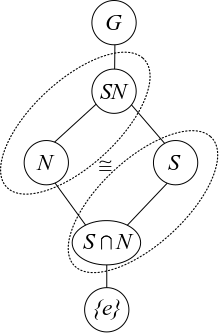

The 2nd “Diamond” Isomorphism Theorem

For this to make sense, we also have

- $SN \leq G$,
- $S\cap N {~\trianglelefteq~}S$,

If we relax the conditions to $S, N \leq G$ with $S \in N_G(N)$, then $S\cap N {~\trianglelefteq~}S$ (but is not normal in $G$) and the 2nd Isomorphism Theorem still holds.

Suppose $N, K \leq G$ with $N {~\trianglelefteq~}G$ and $N\subseteq K \subseteq G$.

1. If $K\leq G$ then $K/N \leq G/N$ is a subgroup
2. If $K{~\trianglelefteq~}G$ then $K/N {~\trianglelefteq~}G/N$.
3. Every subgroup of $G/N$ is of the form $K/N$ for some such $K \leq G$.
4. Every *normal* subgroup of $G/N$ is of the form $K/N$ for some such $K {~\trianglelefteq~}G$.
5. If $K{~\trianglelefteq~}G$, then we can cancel normal subgroups:
   $$\begin{align*}
   \frac{G/N}{K/N} \cong \frac{G}{K}
   .\end{align*}$$

Suppose $N {~\trianglelefteq~}G$, then there exists a correspondence:

$$\begin{align*}
\left\{
H < G {~\mathrel{\Big|}~}N \subseteq H
\right\}
\rightleftharpoons
\left\{
H {~\mathrel{\Big|}~}H < \frac G N
\right\}
\\
\left\{{\substack{
\text{Subgroups of $G$} \\
\text{containing $N$}
}}\right\} \rightleftharpoons
\left\{{\substack{
\text{Subgroups of the } \\
\text{quotient $G/N$}
}}\right\}
.\end{align*}$$

In words, subgroups of $G$ containing $N$ correspond to subgroups of the quotient group $G/N$. This is given by the map $H \mapsto H/N$.

$N {~\trianglelefteq~}G$ and $N \subseteq H < G \implies N {~\trianglelefteq~}H$.

## 3.6 Products

If $H,K \leq G$ and $H \leq N_G(K)$ (or $K {~\trianglelefteq~}G$) then $HK \leq G$ is a subgroup.

$$\begin{align*}
\gcd(p, q) = 1 \implies {\mathbb{Z}}/p{\mathbb{Z}}\times{\mathbb{Z}}/q{\mathbb{Z}}\cong {\mathbb{Z}}/pq{\mathbb{Z}}
.\end{align*}$$

We have $G \cong H \times K$ when

1. $H, K {~\trianglelefteq~}G$
2. $G = HK$.
3. $H\cap K = \left\{{e}\right\} \subset G$

> Note: can relax to $[h,k] = 1$ for all $h, k$.

Prove the “recognizing direct products” theorem. Can the conditions be relaxed?

Things are particularly nice when the orders of $H$ and $k$ are coprime. For 3, $x\in H \cap K$ implies that the order of $x$ divides $\gcd(\# H, \# K) = 1$, so $H \cap K = \left\{{e}\right\}$. Thus for 2, one only needs that $\#(HK) = \# G$.

**(Click to expand proof)**

With these conditions, the following map is an isomorphism:
$$\begin{align*}
\Gamma: H\times K &\to G \\
(h, k) &\mapsto hk
.\end{align*}$$

- This is a group morphism by condition (1):
  $$\begin{align*}
  \Gamma(h_1, k_1) \Gamma(h_2, k_2)
  &\mathrel{\vcenter{:}}=(h_1 k_1) (h_2 k_2) = h_1 ({ \color{red} k_1 h_2 } ) k_2 \\
  &= h_1 ( { \color{red} h_2 k_1 } ) k_2 \\
  &= (h_1 h_2) ( k_1 k_2) \\
  &\mathrel{\vcenter{:}}=\Gamma( (h_1, k_1)(h_2, k_2) )
  .\end{align*}$$
- This is surjective by condition (2)
- This is injective by condition(3) and checking the kernel:
  $$\begin{align*}
  \ker \Gamma = \left\{{ (h,k) {~\mathrel{\Big|}~}hk = 1_G,\, hk = 1_G}\right\} \implies h = k ^{-1} \implies hk \in K \cap H = \left\{{1_G}\right\}
  .\end{align*}$$

We have $G \cong \prod_{i=1}^n H_i$ when

- $H_i {~\trianglelefteq~}G$ for all $i$.
- $G = H_1 \cdots H_n$
- $H_k \cap H_1 \cdots \widehat{H_k} \cdots H_n = \emptyset$

> Note on notation: intersect $H_k$ with the amalgam *leaving out* $H_k$.

We have $G \cong N \rtimes_\psi H$ when

- $N {~\trianglelefteq~}G$
- $G = NH$
- $H \curvearrowright N$ by conjugation via a map
  $$\begin{align*}
  \psi: H \to \mathop{\mathrm{Aut}}(N) \\
  h \mapsto h({-})h^{-1}
  .\end{align*}$$

> Relaxed condition: $H, N {~\trianglelefteq~}G$ for direct product, or just $H\leq G$ for a semidirect product.

## 3.7 Classification: Finitely Generated Abelian Groups

If $G$ is a finitely generated abelian group, then there is a decomposition
$$\begin{align*}
G \cong {\mathbb{Z}}^r \times \prod_{k=1}^m C_{n_k}
\quad \text{ where } n_1 \divides \cdots \divides n_m
,\end{align*}
into a free group and a finite number of cyclic groups, where \(r\in {\mathbb{Z}}^{\geq 0}\) is unique and the \(n_i\) are uniquely determined.$$

If $G$ is a finitely generated abelian group, then there is a unique list of **not necessarily distinct** prime powers $p_k^{e_k}$ such that
$$\begin{align*}
G \cong {\mathbb{Z}}^r \times\prod_{k=1}^m C_{p^k}^{e_k}
,\end{align*}
where \(r\in {\mathbb{Z}}^{\geq 0}\) is uniquely determined.$$

Given any presentation of a group as a product of cyclic groups $G = \prod {\mathbb{Z}}_i/m_i$, with the $m_i$ not necessarily distinct,

- Factor all of the $m_i$ into prime powers, keeping the exponents intact.
- Organize into a table whose columns correspond to individual primes $p_i$.
  - Within an individual column for the prime $p_k$, write all terms of the form $p_k^{e_k}$ (with exponents intact)
  - Arrange the terms from lowest at the top to highest at the bottom. Push everything down so that the bottom-most rows are all filled out.
- For **elementary divisors**, just list out all of elements of the table individually, running across rows.
- For **invariant factors**, iterate a process of taking the largest of each prime power (i.e. the bottom row) at each step, deleting that row, and continuing in the same fashion.

> Note: this sounds much more complicated than it actually is. Try it!

Suppose $G$ is given to you as a product of cyclic groups whose sizes factor in the following way
$$\begin{align*}
p_1^{e_1}p_1^{e_2}p_1^{e_3} \cdot p_2^{f_1}p_2^{f_2} \cdot p_3^{g_1} p_3^{g_2} p_3^{g_3} \cdot p_4^{h_1}
.\end{align*}$$

Assemble these into a table, grouped by prime factor $p_i$, being careful not to separate primes from their exponents:

| $p_1$ | $p_2$ | $p_3$ | $p_4$ |
| --- | --- | --- | --- |
| $p_1^{e_1}$ |  | $p_3^{g_1}$ |  |
| $p_1^{e_2}$ | $p_2^{f_1}$ | $p_3^{g_2}$ |  |
| $p_1^{e_3}$ | $p_2^{f_2}$ | $p_3^{g_3}$ | $p_4^{h_1}$ |

For elementary divisors: take columns, which just amounts to listing them again:
$$\begin{align*}
&\quad {\mathbb{Z}}/p_1^{e_1} \times{\mathbb{Z}}/p_1^{e_2} \times{\mathbb{Z}}/p_1^{e_3} \\
&\quad \times{\mathbb{Z}}/p_2^{f_1} \times{\mathbb{Z}}/p_2^{f_2} \\
&\quad \times{\mathbb{Z}}/p_3^{g_1} \times{\mathbb{Z}}/p_3^{g_2} \times{\mathbb{Z}}/p_3^{g_3} \\
&\quad \times{\mathbb{Z}}/p_4^{h_1}
.\end{align*}$$

For invariant factors: take rows (grouped by CRT)
$$\begin{align*}
& \quad {\mathbb{Z}}/ \qty{p_1^{e_3} p_2^{f_2} p_3^{g_3} p_4^{h_1}} \\
&\quad \times{\mathbb{Z}}/ \qty{p_1^{e_2} p_2^{f_1} p_3^{g_2}} \\
&\quad \times{\mathbb{Z}}/\qty{p_1^{e_1} p_3^{g_1} }
.\end{align*}$$

$$\begin{align*}
G = {{\mathbb{Z}}_{2}\times{\mathbb{Z}}_{2}\times{\mathbb{Z}}_{2}\times{\mathbb{Z}}_{3}\times{\mathbb{Z}}_{3}\times{\mathbb{Z}}_{5^2}}
\end{align*}$$

I’ll use a shortcut for the table: instead of listing columns, I just list the prime powers for a single $p$ in increasing order in the same cell. Then just always take the largest prime power in each cell at each stage:

| $p = 2$ | $p= 3$ | $p =5$ |
| --- | --- | --- |
| $2,2,2$ | $3,3$ | $5^2$ |

$\implies n_m = 5^2 \cdot 3 \cdot 2$

| $p = 2$ | $p= 3$ | $p =5$ |
| --- | --- | --- |
| $2,2$ | $3$ | $\emptyset$ |

$\implies n_{m-1} = 3 \cdot 2$

| $p = 2$ | $p= 3$ | $p =5$ |
| --- | --- | --- |
| $2$ | $\emptyset$ | $\emptyset$ |

$\implies n_{m-2} = 2$

and thus the invariant factor form is
$$\begin{align*}
G\cong {\mathbb{Z}}_2 \times {\mathbb{Z}}_{3\cdot 2} \times {\mathbb{Z}}_{5^2 \cdot 3 \cdot 2}
\end{align*}$$

$$\begin{align*}
G \mathrel{\vcenter{:}}={\mathbb{Z}}_2 \times {\mathbb{Z}}_2 \times {\mathbb{Z}}_{2^3} \times {\mathbb{Z}}_{5^2\cdot 7}
\end{align*}
Make the table by factoring the order of each cyclic piece, being careful not to combine terms that come from distinct summands (e.g. not combining the two copies of \(2^1\)), and to keep exponents from factorizations intact as a single term (e.g. the \(2^3\)):$$

| $2$ | $5$ | $7$ |
| --- | --- | --- |
| $2$ |  |  |
| $2$ |  |  |
| $2^3$ | $5^2$ | $7$ |

Reading across rows from bottom to top (and using CRT to merge everything within a row) yields invariant factors on the LHS below. Reading down columns, left to right (merging nothing) yields elementary divisors on the right-hand side below

$$\begin{align*}
{\mathbb{Z}}_2 \times {\mathbb{Z}}_2 \times {\mathbb{Z}}_{2^3 \cdot 5^2 \cdot 7}
\cong
{\mathbb{Z}}_2 \times {\mathbb{Z}}_2 \times {\mathbb{Z}}_{2^3} \times {\mathbb{Z}}_{5^2} \times {\mathbb{Z}}_7
.\end{align*}$$

If $\# G \mathrel{\vcenter{:}}= n = \prod_{k=1}^m p_k^{e_k}$, then there are exactly $\prod_{k=1}^m P(e_k)$ abelian groups of order $n$, where $P$ is the integer partition function.

One can compute $P(6) = 11$, where all of the partitions are given by
$$\begin{align*}
&[6], \\
&[5, 1], \\
&[4, 2], \\
&[4, 1, 1], \\
&[3, 3], \\
&[3, 2, 1], \\
&[3, 1, 1, 1], \\
&[2, 2, 2], \\
&[2, 2, 1, 1], \\
&[2, 1, 1, 1, 1], \\
&[1, 1, 1, 1, 1, 1]
.\end{align*}$$

In practice, it is easy to list all of the partitions out for a given $n$, but it’s also useful to have a systematic way to generate them and actually check that you have them all.

There is a recurrence relation
$$\begin{align*}
P_k(n) = P_k(n-k) + P_{k-1}(n-1)
,\end{align*}
which follows from the fact that one can obtain a partition of \(n\) with \(k\) parts by either$$

- Taking a partition of $n-k$ into $k$ parts and adding 1 to each part, e.g. $[1,1,1,3] \mapsto [2,2,2,4]$
- Taking a partition of $n-1$ into $k-1$ parts and adding a new standalone part $1$, e.g. $[1,1,2,5] \mapsto [1,1,2,5,1]$.

Summing over $k$ yields the following, which can be recursed:
$$\begin{align*}
P(n)
&= \sum_{k=1}^n P_k(n-k) + P(n-1) \\
&= \sum_{k=1}^n P_k(n-k) + \sum_{k=1}^{n-1} P_k(n-1-k) + P(n-2) \\
&= \cdots
,\end{align*}
where \(P_k(m) = 0\) for \(k>m\) and \(P_m(m) = 1\).$$

One can compute that $P(5) = 7$, and the formula recovers this:
$$\begin{align*}
P(5)
&= \sum_{k=1}^5 P_{k}(5-k) + P(4) \\
&= \qty{ P_1(4) + P_2(3) } + P(4) \\
&= \qty{ P_1(4) + P_2(3) } + \qty{P_1(3) + P_2(2)} + P(3) \\
&= \qty{ P_1(4) + P_2(3) } + \qty{P_1(3) + P_2(2)} + \qty{P_1(2)} + P(2) \\
&= \qty{ P_1(4) + P_2(3) } + \qty{P_1(3) + P_2(2)} + \qty{P_1(2)} + \qty{P_1(1) + P(1)} \\
&= \qty{1 + 1 } + \qty{1 + 1} + \qty{1} + \qty{1 + 1} \\
&= 7
.\end{align*}
Note that you could just stop at the third line, since \(P(3) = 3\) is easy to enumerate: \([1,1,1], [1,2], [3]\).$$

Suppose $\# G = n = p^3 q^4$. Compute that $p(3) = 3$ and $p(4) = 5$, so there should be 15 abelian groups of this order. Enumerate the partitions:

- For 3: $[1,1,1], [1,2], [3]$
- For 4: $[1,1,1,1], [1,2,1], [1,3], [2,2], [4]$

Now for every distinct pair taking one from the first line and one from the second, we get a group of that order. A partition of $m$ of the form $[a,b,c, \cdots]$ contributes a group of the form ${\mathbb{Z}}_{m^a} \times{\mathbb{Z}}_{m^b} \times{\mathbb{Z}}_{m^c} \cdots$.

Crossing $[1,1,1]$ with everything:

- $\qty{{\mathbb{Z}}_p \times{\mathbb{Z}}_p \times{\mathbb{Z}}_p} \times\qty{{\mathbb{Z}}_q \times{\mathbb{Z}}_q \times{\mathbb{Z}}_q \times{\mathbb{Z}}_q} \mapsfrom [1,1,1] \times[1,1,1,1]$
- $\qty{{\mathbb{Z}}_p \times{\mathbb{Z}}_p \times{\mathbb{Z}}_p} \times\qty{{\mathbb{Z}}_q \times{\mathbb{Z}}_{q^2} \times {\mathbb{Z}}_q} \mapsfrom [1,1,1]\times[1,2,1]$
- $\qty{{\mathbb{Z}}_p \times{\mathbb{Z}}_p \times{\mathbb{Z}}_p} \times\qty{{\mathbb{Z}}_q \times{\mathbb{Z}}_{q^3}} \mapsfrom [1,1,1] \times[1,3]$
- $\qty{{\mathbb{Z}}_p \times{\mathbb{Z}}_p \times{\mathbb{Z}}_p} \times\qty{{\mathbb{Z}}_{q^2} \times{\mathbb{Z}}_{q^2}} \mapsfrom [1,1,1] \times[2,2]$
- $\qty{{\mathbb{Z}}_p \times{\mathbb{Z}}_p \times{\mathbb{Z}}_p} \times{\mathbb{Z}}_{q^4} \mapsfrom [1,1,1]\times[4]$

Crossing $[1, 2]$ with everything:

- $\qty{ {\mathbb{Z}}_p \times{\mathbb{Z}}_{p^2} } \times\qty{{\mathbb{Z}}_q \times{\mathbb{Z}}_q \times{\mathbb{Z}}_q \times{\mathbb{Z}}_q} \mapsfrom [1,2]\times[1,1,1,1]$
- $\qty{ {\mathbb{Z}}_p \times{\mathbb{Z}}_{p^2} } \times\qty{{\mathbb{Z}}_q \times{\mathbb{Z}}_{q^2} \times{\mathbb{Z}}_q} \mapsfrom [1,2] \times[1,2,1]$
- $\qty{ {\mathbb{Z}}_p \times{\mathbb{Z}}_{p^2} } \times\qty{{\mathbb{Z}}_q \times{\mathbb{Z}}_{q^3}} \mapsfrom [1,2] \times[1,3]$
- $\qty{ {\mathbb{Z}}_p \times{\mathbb{Z}}_{p^2} } \times\qty{{\mathbb{Z}}_{q^2} \times{\mathbb{Z}}_{q^2}} \mapsfrom [1,2] \times[2,2]$
- $\qty{ {\mathbb{Z}}_p \times{\mathbb{Z}}_{p^2} } \times{\mathbb{Z}}_{q^4} \mapsfrom [1, 2]\times[4]$

And so on!

## 3.8 Classification: Groups of Special Orders

General strategy: find a normal subgroup (usually a Sylow) and use recognition of semidirect products.

- [Keith Conrad: Classifying Groups of Order 12](https://kconrad.math.uconn.edu/blurbs/grouptheory/group12.pdf)
- Order $pqr$: ?
- Order $p^2q$: ?

Every group $G$ of prime order $p\geq 2$ is cyclic and thus isomorphic to ${\mathbb{Z}}/p$.

**(Click to expand proof)**

Supposing that $g\neq e$, it generates a cyclic subgroup $H \mathrel{\vcenter{:}}=\left\langle{g}\right\rangle \leq G$ of order dividing $p$ by Lagrange. Since $g\neq e$, $\#H = p = \# G$.

Every group $G$ of order $p^2$ is abelian, and thus isomorphic to either $C_{p^2}$ or $C_p^2$.

**(Click to expand proof)**

Quotient by the center to get $m\mathrel{\vcenter{:}}=\#G/Z(G) \in \left\{{ 1, p, p^2 }\right\}$. By cases:

- Since $G$ is a $p{\hbox{-}}$group, $G$ has nontrivial center, so $m\neq 1$
- If $m=p$, then $G/Z(G)$ is cyclic and thus $G$ is abelian by the $G/Z(G)$ theorem.
- If $m=p^2$, $Z(G) = G$ and $G$ is abelian, done.

If $G$ is a group of order $pq$ where without loss of generality $q<p$, then

1. If $q\notdivides p-1$ then $G$ is cyclic and $G\cong S_p \times S_q \cong C_{pq}$.
2. If $q\divides p-1$ then $G\cong S_q \rtimes_\psi S_p$ where $S_p {~\trianglelefteq~}G$ and $\psi: S_q \to \mathop{\mathrm{Aut}}(S_p)$, and $G$ has a presentation
   $$\begin{align*}
   G\cong \left\langle{a, b {~\mathrel{\Big|}~}a^p, b^q, bab^{-1}= a^\ell}\right\rangle \\ \\
   \ell \not\equiv 1 \operatorname{mod}p && \ell^q \equiv 1 \operatorname{mod}p
   .\end{align*}$$

**(Click to expand proof)**

- Suppose $q<p$.
- Apply the Sylow theorems to $p$:
  - $n_p \cong 1 \operatorname{mod}p \implies n_p \in \left\{{ 1, p+1, 2p+1, \cdots }\right\}$.
  - $n_p \divides q \implies n_p \in \left\{{ 1, q }\right\}$.
  - Since $1<q<p<p+1$, this forces $n_p = 1$
- Suppose $q\notdivides p-1$ and apply the Sylow theorems to $q$:
  - $n_q \equiv 1\operatorname{mod}q \implies n_q \in \left\{{ 1, q+1, 2q+1,\cdots }\right\}$
  - $n_q \divides p \implies n_q\in \left\{{ 1, p }\right\}$
  - Now note that if $n_q\neq 1$, then $n_q=p$ and $p$ is of the form $kq+1$ for some $k$.
  - **Use of assumption**: then $p=kq+1 \iff p-1 = kq \iff q\divides p-1$, which is precisely what we assumed is *not* the case.
- So $n_p = n_q = 1$ and $S_p, S_q {~\trianglelefteq~}G$.
- Apply recognition of direct products:
  - $S_p, S_q \leq G$: check.
  - $S_p, S_q {~\trianglelefteq~}G$: check.
  - $S_p \cap S_q = \left\{{ e }\right\}$: check, because they are coprime order.
  - $S_p S_q = G$: follows from a counting argument:
    $$\begin{align*}
    \# S_pS_q = {\# S_p \# S_q \over \# \qty{S_p \cap S_q}} = {pq \over 1} = \# G
    .\end{align*}
    If \(G\) is finite, then \(AB\leq G\) with \(\#AB = \#G\) implies \(AB = G\).$$

**(Click to expand proof)**

- Suppose $q \divides p-1$, the previous argument for $S_p$ works, but the argument for $S_q$ doesn’t, so we get a semidirect product.
- Work up to isomorphism:
  $$\begin{align*}
  S_p \cong {\mathbb{Z}}/p = \left\langle{a{~\mathrel{\Big|}~}a^p}\right\rangle
  &{~\trianglelefteq~}G \\ \\
  S_q \cong {\mathbb{Z}}/q =\left\langle{b{~\mathrel{\Big|}~}b^q}\right\rangle
  &\leq G
  .\end{align*}$$
- We have
  $$\begin{align*}
  G&\cong {\mathbb{Z}}/q \rtimes_{\psi} {\mathbb{Z}}/p
  && \psi: {\mathbb{Z}}/q \to \mathop{\mathrm{Aut}}\qty{{\mathbb{Z}}/p} \\ \\
  \implies G &\cong\left\langle{a,b {~\mathrel{\Big|}~}a^p, b^q,\,\, aba^{-1}= \psi(b) = b^\ell }\right\rangle && \text{for some }\ell
  .\end{align*}
  Since \({\mathbb{Z}}/q\) is cyclic, such a morphism is determined by the image of the generator \([1]_q \in {\mathbb{Z}}/q\).
  Note that \([1]_q \mapsto \operatorname{id}_{{\mathbb{Z}}/p}\) is such a morphism, and yields the direct product again.$$
- Identify $\mathop{\mathrm{Aut}}({\mathbb{Z}}/p) \cong \qty{\qty{{\mathbb{Z}}/p}^{\times}, \times } \cong \qty{ {\mathbb{Z}}/(p-1), +}$.
- So we need to classify morphisms
  $$\begin{align*}
  \psi: {\mathbb{Z}}/q\to {\mathbb{Z}}/(p-1)
  .\end{align*}
  Consider \(\operatorname{im}\psi \leq {\mathbb{Z}}/(p-1)\).
  Sending \([1]_q\) to the identity in \(\mathop{\mathrm{Aut}}({\mathbb{Z}}/p)\) yields the direct product again, so pick nontrivial morphisms.
  Since \(\# \operatorname{im}\psi \divides q\) which is prime, its order is equal to \(q\).
  Since \(q\divides p-1\) and \({\mathbb{Z}}/(p-1)\) is cyclic of order \(p-1\), by Cauchy’s theorem there is a unique subgroup of order \(q\), say \(C_q \leq {\mathbb{Z}}(p-1)\)
  We can send \([1]_q\) to \([\alpha]_{p-1} \in {\mathbb{Z}}/(p-1)\) where \(\alpha\) is any generator of \(C_q\), of which there are \(\phi(q) = q-1\) nontrivial choices.$$
- Thus there are $q-1$ distinct nontrivial choices for the action $\psi: {\mathbb{Z}}/q \to {\mathbb{Z}}/(p-1)$.

All choices yield isomorphic semidirect products.

- Use that $G\mathrel{\vcenter{:}}= A\rtimes_{\psi} N$ with $\psi:A\to \mathop{\mathrm{Aut}}(N)$ is an $\mathop{\mathrm{Aut}}(N)$ and $\mathop{\mathrm{Aut}}(A)$ module, where $f \in \mathop{\mathrm{Aut}}(N)$ and $\pi\in \mathop{\mathrm{Aut}}(A)$ act in the following ways:
  $$\begin{align*}
  \pi &\curvearrowright A\rtimes_\psi N = A \rtimes_{\psi \circ \pi } N \\
  f &\curvearrowright A\rtimes_\psi N = A \rtimes_{\gamma_f \circ \psi } N
  .\end{align*}
  where
  \begin{align*}
  \gamma_f: \mathop{\mathrm{Aut}}(N) &\to \mathop{\mathrm{Aut}}(N) \\
  \psi &\mapsto f\circ \psi \circ f^{-1}
  .\end{align*}
  These actions preserve the group isomorphism type of \(G$$
- However, since $C_q \leq {\mathbb{Z}}/(p-1)$ and $\mathop{\mathrm{Aut}}(C_q) \cong {\mathbb{Z}}/(q-1)$, there are exactly $q-1$ automorphisms of the image $C_q$, say $\left\{{\pi_k}\right\}_{k=1}^{q-1}$.
- So $\psi \circ \pi_k: {\mathbb{Z}}/q \to {\mathbb{Z}}/(p-1)$ for $1\leq k \leq q-1$ yields $q-1$ distinct actions, and we’re done.

If $N{~\trianglelefteq~}G$ and $P\in {\operatorname{Syl}}_p(H)$ then $G = N_G(P)H$.

**(Click to expand proof)**

- Let $g\in G$, then since $P\leq H {~\trianglelefteq~}G$ we have $gPg^{-1}\subseteq gHg^{-1}= H$.
- So $P' \mathrel{\vcenter{:}}= gPg^{-1}\in {\operatorname{Syl}}_p(H)$ for all $g$, and since Sylows in $H$ are all conjugate, we can write $P' = h^{-1}Ph^{-1}$ for some $h\in H$.
- This says $hPh^{-1}= gPg^{-1}$ and thus $P = (g^{-1}h)P (h^{-1}g) = (h^{-1}g)^{-1}P (h^{-1}g)$.
- But then $g^{-1}h \in N_G(P)$ so $g\in N_G(P)H$.

Every finite $p$ group is solvable.

**(Click to expand proof)**

- By induction on $k$ in $\# G = p^k$: if $\# G = p$ then $G$ is abelian and automatically solvable.
- Inductively, for $\# G = p^k$, now consider $Z(G)\neq 1$ since we’re in a $p{\hbox{-}}$group.
- If $G/Z(G)$ is abelian, use the general fact: $H$ solvable and $G/H$ solvable implies $G$ solvable.
  - Here $Z(G)$ and $G/Z(G)$ are both abelian and thus solvable.
- Otherwise $G/Z(G)$ is a $p{\hbox{-}}$group of size $p^{k-1}$ and thus solvable by hypothesis.

If $\# G = pq$ with $p<q$ distinct primes, then $G$ has a normal subgroup of size $q$.

This is immediate from Sylow theory: $[n_q]_q = 1, n_q \divides p, p<q$ forces $n_q = 1$.

If $|G| = pqr$ where $p<q<r$ are distinct primes then $G$ is solvable.

**(Click to expand proof)**

Idea:

- Get a normal subgroup $R$ of order $r$, so $\# (G/R) = pq$.
- Get a normal subgroup $Q_1$ of order $q$ in $G/R$, which corresponds to $Q{~\trianglelefteq~}G$ of order $qr$ containing $R$. Note that $R{~\trianglelefteq~}Q$ since normality descends to subgroups.
- Now $G\to Q\to R \to 1$ is a subnormal series whose quotients are all cyclic and thus abelian:
  - $\#(G/Q) = pqr/qr = p$,
  - $\#(Q/R) = qr/r = q$,
  - $\#(R/1) = r$,

Proof of first claim: let $m\mathrel{\vcenter{:}}=\# G = pqr$, then $G$ has a normal subgroup of order $r$.

- Claim: at least one of the Sylows for $p,q,$ or $r$ is normal.
  - If none of the Sylow $p,q,r$ groups are normal, then $n_r \geq r$ and $n_p \geq q$. Counting the contributions from just ${\operatorname{Syl}}_q(G)$ and ${\operatorname{Syl}}_p(G)$ yields
    $$\begin{align*}
    n_q(q-1) + n_r(r-1) \geq pr(q-1) + pq(r-1) = pqr + p(qr -q - r)
    .\end{align*}$$
  - If this is to be at most $m$, it must be that $qr-q-r$ is negative (since $p>1$ and otherwise this would yield more than $pqr$ elements).
  - But if this holds,
    $$\begin{align*}
    qr-q-r \leq 0 \iff q(r-1) \leq r \iff q\leq {r\over r-1}
    .\end{align*}
    But \(q>2\) be assumption, and \(1\leq {r\over r-1}\leq 2\) for any number \(r\). \(\contradiction\).$$
  - So there is one of $S_p , S_q, S_r$ that is normal in $G$.
- Now if $S_r$ is normal we’re done, so suppose not and $n_r > 1$. Claim: we can get another subgroup of order $r$
  - Let $N$ be the normal Sylow, so either $N\in {\operatorname{Syl}}_p(G)$ or $N\in {\operatorname{Syl}}_q(G)$.
  - Then $G/N$ has order $r\ell$ for either $\ell = q$ or $\ell = p$ respectively.
  - In either case, $\ell < r$. Using the lemma, $G/N$ has a normal subgroup of size $r$, say $R/N \leq G/N$.
  - Then by the subgroup correspondence theorem, $R$ corresponds to a normal subgroup $R'{~\trianglelefteq~}G$ of size $r\ell$ with $r<\ell$.
  - Applying the same lemma to $R'$ immediately yields a normal subgroup $R''$ of order $r$ in $R'$
  - Now use that $R'' \operatorname{char} R'$ since Sylows are characteristic, and $R'{~\trianglelefteq~}G$, so $R''{~\trianglelefteq~}G$ too.

## 3.9 Series of Groups

A **normal series** of a group $G$ is a sequence $G \to G^1 \to G^2 \to \cdots$ such that $G^{i+1} {~\trianglelefteq~}G_i$ for every $i$.

A **central series** for a group $G$ is a terminating normal series $G \to G^1 \to \cdots \to \left\{{e}\right\}$ such that each quotient is **central**, i.e. $[G, G^i] \leq G^{i-1}$ for all $i$.

A **composition series** of a group $G$ is a finite normal series such that $G^{i+1}$ is a *maximal proper* normal subgroup of $G^i$.

Any two composition series of a group have the same length and isomorphic composition factors (up to permutation).

A group $G$ is **simple** iff $H{~\trianglelefteq~}G \implies H = \left\{{e}\right\}, G$, i.e. it has no non-trivial proper subgroups.

If $G$ is *not* simple, then $G$ is an extension of any of its normal subgroups. I.e. for any $N{~\trianglelefteq~}G$, $G \cong E$ for some extension of the form $N\to E\to G/N$.

Set $G^0 = G$ and $G^{i+1} = [G, G^i]$, then $G^0 \geq G^1 \geq \cdots$ is the *lower central series* of $G$.

> Mnemonic: “lower” because the chain is descending. Iterate the adjoint map $[{-}, G]$, if this terminates then the map is nilpotent, so call $G$ nilpotent!

Set $Z_0 = 1$, $Z_1 = Z(G)$, and $Z_{i+1} \leq G$ to be the subgroup satisfying $Z_{i+1}/Z_i = Z(G/Z_i)$. Then $Z_0 \leq Z_1 \leq \cdots$ is the *upper central series* of $G$.

Equivalently, since $Z_i{~\trianglelefteq~}G$, there is a quotient map $\pi:G\to G/Z_i$, so define $Z_{i+1} \mathrel{\vcenter{:}}=\pi^{-1}(Z(G/Z_i))$ (?).

> Mnemonic: “upper” because the chain is ascending. “Take higher centers.”

Set $G^{(0)} = G$ and $G^{(i+1)} = [G^{(i)}, G^{(i)}]$, then $G^{(0)} \geq G^{(1)} \geq \cdots$ is the *derived series* of $G$.

## 3.10 Solvability

A useful way to extract normal subgroups: let $G$ act on literally anything by $\phi: G\to \mathop{\mathrm{Aut}}(X)$. Then $\ker \phi {~\trianglelefteq~}G$ is always a normal subgroup. Some examples:

- $G\curvearrowright G$ by $x\mapsto gx$.
- $G\curvearrowright\left\{{H\leq G}\right\}$ by $H\mapsto gH$ or $H\mapsto gHg^{-1}$.
- $G\curvearrowright\left\{{{\operatorname{Syl}}_p(G)}\right\}$ for a fixed $p$ by $S_p \mapsto gS_p g^{-1}$.
- $G\curvearrowright H$ for $H{~\trianglelefteq~}G$ by inner automorphisms $h\mapsto ghg^{-1}$.

A group $G$ is **solvable** iff $G$ has a terminating normal series with abelian composition factors, i.e.
$$\begin{align*}
G \mathrel{\vcenter{:}}= G_n > G_{n-1} > \cdots > G_2 > G_1 \mathrel{\vcenter{:}}=\left\{{ e }\right\} && \text{ with } G^{i}/G^{i+1}\text{ abelian for all } i
.\end{align*}$$

If $G = { \mathsf{Gal}} (L/K)$ is a Galois group corresponding to a polynomial $f$, then $G$ is solvable as a group iff $f$ is solvable in radicals: there is a tower of extensions $K = F_0 \subset F_1 \subset F_2 \subset \cdots \subset F_m = L$ where

1. $F_i = F_{i-1}(\alpha_i)$ where $\alpha_i^{m_i } \in F_{i-1}$ for some power $m_i \in {\mathbb{Z}}^{\geq 0}$, and
2. $F_m \supseteq \operatorname{SF}(f)$ contains a splitting field for $f$.

A group $G$ is solvable iff its derived series terminates.

Some useful facts about solvable groups:

- $G$ is solvable iff $G$ has a terminating *derived series*.
- Solvable groups satisfy the 2 out of 3 property
- Abelian $\implies$ solvable
- Every group of order less than 60 is solvable.

# 4 Ring Theory

A subset $S\subseteq R$ is a subring iff

- $(S, +)$ forms an abelian subgroup (so closed under addition and contains inverses)
- $(S, \cdot)$ forms a submonoid (so closed under multiplication)
- $I + J = \left\{{i+j {~\mathrel{\Big|}~}i\in I, j\in J}\right\} = \left\langle{I, J}\right\rangle$ is the smallest ideal containing $I$ and $J$.
- $IJ = \left\{{\sum_{k\leq N} x_k y_k {~\mathrel{\Big|}~}x_k\in I, y_k \in J, N\in {\mathbb{Z}}^{\geq 0}}\right\}$ is the ideal generated by all finite sums of products.
- $I \cap J$ is an ideal, $I\cup J$ is generally **not** an ideal
- Ideals are *comaximal* if $I + J = \left\langle{ 1 }\right\rangle$.
- If $I+J = \left\langle{ 1 }\right\rangle$ then $I \cap J = IJ$.

The ideal **generated** by $\left\{{a, b}\right\}$ is defined as
$$\begin{align*}
\left\langle{a, b}\right\rangle \mathrel{\vcenter{:}}= Ra + Rb \mathrel{\vcenter{:}}=\left\{{ r_1 a + r_2 b {~\mathrel{\Big|}~}r_i \in R}\right\}
.\end{align*}$$

More generally for a set $S = \left\{{s_k}\right\}$,
$$\begin{align*}
\left\langle{S}\right\rangle \mathrel{\vcenter{:}}=\sum_{k=1}^{\# S} Rs_k \mathrel{\vcenter{:}}=\left\{{ \sum r_k s_k {~\mathrel{\Big|}~}r_k\in R, s_k\in S}\right\}
.\end{align*}$$

- $\left\langle{p, q}\right\rangle = \left\langle{\gcd(p, q)}\right\rangle {~\trianglelefteq~}{\mathbb{Z}}$.

## 4.1 Isomorphism Theorems

These are all basically the same for modules.

For any ring morphism $f:A\to B$ there is SES of rings
$$\begin{align*}
0 \to \ker f \to A \to \operatorname{im}(f) \to 0
,\end{align*}
and thus \(A/\ker f \cong \operatorname{im}f\). If \(f\) is surjective, then \(A/\ker f \cong B\).$$

More traditionally stated:

- $\ker \phi \in \operatorname{Id}(A)$
- $\operatorname{im}\phi \leq B$ is a subring (not necessarily an ideal)
- $R/\ker \phi \cong \operatorname{im}\phi$.

Let $R\in \mathsf{Ring}, S\leq R, I\in \operatorname{Id}(R)$, then there is an isomorphism:
$$\begin{align*}
{S+I \over I} {\xrightarrow{\sim}}{S\over S \cap I}
.\end{align*}$$

Where it’s also true that this statement makes sense:

- $S+I \leq R$ is a subring.
- $S \cap I {~\trianglelefteq~}S$

For $I\in \operatorname{Id}(R)$, the canonical quotient map $\phi: R \to R/I$ induces a bijective correspondence:
$$\begin{align*}
\left\{{\substack{
J \in \operatorname{Id}(R) {~\mathrel{\Big|}~}J\supseteq I
}}\right\}
&\rightleftharpoons
\operatorname{Id}(R/I) \\
J \mathrel{\vcenter{:}}=\phi^{-1}(\mkern 1.5mu\overline{\mkern-1.5muJ\mkern-1.5mu}\mkern 1.5mu) &\mapsfrom \mkern 1.5mu\overline{\mkern-1.5muJ\mkern-1.5mu}\mkern 1.5mu \\
J &\mapsto \mkern 1.5mu\overline{\mkern-1.5muJ\mkern-1.5mu}\mkern 1.5mu \mathrel{\vcenter{:}}=\phi(J)
,\end{align*}
where \(\phi: R\to R/I\) is the canonical quotient morphism.$$

More traditionally:

- If $S, I \in \operatorname{Id}(R)$ with $S$ containing $I$ then
  $$\begin{align*}
  S/I \leq R/I
  .\end{align*}$$
- Every ideal in $\operatorname{Id}(R/I)$ is of the form $\mkern 1.5mu\overline{\mkern-1.5muS\mkern-1.5mu}\mkern 1.5mu \mathrel{\vcenter{:}}= S/I$ for some $S\in \operatorname{Id}(R)$ containing $I$.
- If $I, J \in \operatorname{Id}(R)$ with $I \subseteq J \subseteq R$ then there is an isomorphism
  $$\begin{align*}
  {R/I \over J/I} {\xrightarrow{\sim}}{R\over J}
  .\end{align*}$$

Moreover, $A\leq R$ is a subring containing $I$ iff $A/I \in \operatorname{Id}(R/I)$.

Show that if $J\in \operatorname{Id}(R)$ (with $J\supseteq I$) is radical/prime/maximal iff $\mkern 1.5mu\overline{\mkern-1.5muJ\mkern-1.5mu}\mkern 1.5mu \in \operatorname{Id}(R/I)$ is radical/prime/maximal.

## 4.2 Important Techniques

$R \in \mathsf{Field}\iff \operatorname{Id}(R) = \left\{{ 0, R }\right\}$.

**(Click to expand proof)**

$\implies$: If $0\neq x\in I{~\trianglelefteq~}R$, using that $R^{\bullet}= R^{\times}$, $x$ is a unit. So $x^{-1}\in R$, and $xx^{-1}\mathrel{\vcenter{:}}= 1 \in I$ so $I = R$.

$\impliedby$: Let $x\in R^{\bullet}$, then $Rx = R$ so $1\in Rx$ and $1=rx$ for some $r\in R$. This forces $x=r^{-1}$.

- $R/{\mathfrak{m}}$ is a field $\iff {\mathfrak{m}}\in \operatorname{mSpec}(R)$ is maximal.
- $R/{\mathfrak{p}}$ is an integral domain $\iff {\mathfrak{p}}\in \operatorname{Spec}(R)$ is prime.
- $R/J$ is reduced $\iff J$ is radical.

**(Click to expand proof)**

Use the ideal correspondence theorem: $\operatorname{Id}(R/{\mathfrak{m}})$ are ideals of $R$ containing ${\mathfrak{m}}$:
$$\begin{align*}
&\quad R/{\mathfrak{m}}\in \mathsf{Field}\\
&\iff \not\exists J/{\mathfrak{m}}\in \operatorname{Id}(R/{\mathfrak{m}})^{\bullet}\text{ such that } J \in \operatorname{Id}(R) \\
&\iff \not\exists {\mathfrak{m}}\subsetneq J \subsetneq R \\
&\iff J\in \operatorname{mSpec}(R)
.\end{align*}$$

**(Click to expand proof)**

$\impliedby$: Show $xy = 0$ with $x\neq 0$ forces $y=0$. Let $x, y\in {\mathfrak{p}}\in \operatorname{Spec}R$, so $x = a + I, y = b + I$ for some $a,b\in R$. If $xy=0 \operatorname{mod}{\mathfrak{p}}$ with $y\neq 0\operatorname{mod}{\mathfrak{p}}$, we can check
$$\begin{align*}
xy = (a+{\mathfrak{p}})(b+{\mathfrak{p}}) \mathrel{\vcenter{:}}=(ab) + {\mathfrak{p}}= 0 + {\mathfrak{p}}\implies ab\in {\mathfrak{p}}
.\end{align*}
Since \({\mathfrak{p}}\) is prime and \(x\neq 0 \implies a\not\in{\mathfrak{p}}\), so \(b\in {\mathfrak{p}}\). But then
\begin{align*}
y \mathrel{\vcenter{:}}= b + {\mathfrak{p}}= 0 + {\mathfrak{p}}= 0 \operatorname{mod}{\mathfrak{p}}
.\end{align*}$$

$\implies$: Let $a,b\in R$ with $xy\in {\mathfrak{p}}$, we want to show that if $x\not \in {\mathfrak{p}}$ then $y\in {\mathfrak{p}}$. Note $x\not \in {\mathfrak{p}}\iff x \cong 0 \operatorname{mod}{\mathfrak{p}}$. Setting $x\mathrel{\vcenter{:}}= a + {\mathfrak{p}}, y\mathrel{\vcenter{:}}= b + {\mathfrak{p}}$ yields
$$\begin{align*}
xy \mathrel{\vcenter{:}}=(a+{\mathfrak{p}})(b+{\mathfrak{p}}) \mathrel{\vcenter{:}}= ab + {\mathfrak{p}}= 0 \operatorname{mod}{\mathfrak{p}}
.\end{align*}
Since \(R/{\mathfrak{p}}\) is a domain, assuming \(x\neq 0 \operatorname{mod}{\mathfrak{p}}\) we have \(y = 0 \operatorname{mod}{\mathfrak{p}}\), so \(y\in {\mathfrak{p}}\).$$

Note that this yields a quick proof that $\operatorname{mSpec}R \subseteq \operatorname{Spec}R$, using that $\mathsf{Field}\leq \mathsf{IntDomain}$:
$$\begin{align*}
I \text{ maximal } \iff R/I \in \mathsf{Field}{\color{blue} \implies } R/I \in \mathsf{IntDomain} \iff I \text{ prime}
.\end{align*}$$

If ${\mathfrak{m}}$ is maximal and $x \in R\setminus{\mathfrak{m}}$ then ${\mathfrak{m}}+ Rx = R = \left\langle{ 1}\right\rangle$.

## 4.3 Undergrad Review

Notation:

- $\left\langle{ a }\right\rangle \mathrel{\vcenter{:}}= Ra \mathrel{\vcenter{:}}=\left\{{ ra {~\mathrel{\Big|}~}r \in R }\right\}$ is the ideal generated by a single element.
- $R = \left\langle{ 1 }\right\rangle$ is equivalently the ideal generated by 1.

### 4.3.1 Basics

A **ring** is a triple $(R, +, \cdot) \in \mathsf{CRing}$ such that

- $(R, +)\in {\mathsf{Ab}}{\mathsf{Grp}}$,
- $(R, \cdot) \in \mathsf{Mon}$
- Distributivity: $a(b+c) = ab + ac$.

Some of the most important examples of rings:

- The usual suspects: ${\mathbb{Z}}, {\mathbb{Q}}$
  - Their analogs: number fields $K \mathrel{\vcenter{:}}={\mathbb{Q}}(\zeta)$, their rings of integers ${\mathbb{Z}}_K$ or ${\mathcal{O}}_K$,
- Gaussian integers ${\mathbb{Z}}(i)$
- Fields $k = {\mathbb{F}_{p^n}}, {\mathbb{R}}$
- Fraction fields of rings $\operatorname{ff}(R)$, e.g. $\operatorname{ff}({\mathbb{Z}}) = {\mathbb{Q}}$.
- Polynomial rings $R { \left[ {{ {x}_1, {x}_2, \cdots, {x}_{n}}} \right] }$, particularly for $R=k$ a field
- Power series rings $R { \left[ {{ {x}_1, {x}_2, \cdots, {x}_{n}}} \right] }$.
  - Formal power series rings $R { \left[\left[ {{ {x}_1, {x}_2, \cdots, {x}_{n}}} \right] \right] }$.
- ${ {\mathbb{Z}}_p }\mathrel{\vcenter{:}}=\left\{{a/b {~\mathrel{\Big|}~}p \notdivides b }\right\}$ the ring of $p{\hbox{-}}$adic integers
- Rings of germs, e.g. $C^\infty(X, Y)$ where $f\sim g$ iff there exists some $U \subseteq X$ with ${ \left.{{f}} \right|_{{U}} } = { \left.{{g}} \right|_{{U}} }$.

A morphism $f\in \mathsf{CRing}(X, Y)$ satisfies:

- $f(1_X) = 1_Y$
- $f(a(b+c)) = f(a)f(b) + f(a)f(c)$

Important notes:

- $\ker f \mathrel{\vcenter{:}}= f^{-1}(\left\{{0}\right\})$.
- A bijective ring morphisms is automatically an isomorphism in $\mathsf{CRing}$.
- $\ker f {~\trianglelefteq~}X$ is an ideal, but $\operatorname{im}f \leq Y$ is only a subring in general.
- For any ideal $I{~\trianglelefteq~}R$ there is a quotient map $R\to R/I$, it’s useful to write cosets as $a+I$.
- For quotients, $x \equiv y \operatorname{mod}I \iff x-y \in I$.

An **ideal** $I{~\trianglelefteq~}R$ is a subset where $(I, +) \leq (R, +) \in {\mathsf{Grp}}$ is a subgroup and for $x\in R, i\in I$, $xi \in I$. Equivalently,

- $RI \subseteq I$
- $I + I \subseteq I$

Note that $0$ is in every ideal.

Using that every ring has a ${\mathsf{{\mathbb{Z}}}{\hbox{-}}\mathsf{Mod}}$ structure, the **characteristic** of a ring $R$ is the smallest $n$ such that $n\curvearrowright 1_R = 0_R$, i.e. $\sum_{i=1}^n 1_R = 0_R$.

### 4.3.2 Elements

An element $r\in R$ is **divisible** by $q \in R$ if and only if there exists some $c \in R$ such that $r = qc$. In this case, we sometimes write $q\divides r$.

An element $r\in R$ is a **unit** if $r\divides 1$: there exists an $s\in R$ such that $rs = sr = 1$. Then $r^{-1}\mathrel{\vcenter{:}}= s$ is uniquely determined, and the set of units $(R^{\times}, \cdot) \in {\mathsf{Ab}}{\mathsf{Grp}}$ forms a group.

An element $r\in R$ is **irreducible** iff
$$\begin{align*}
r=ab \implies a \in R^{\times}\text{ or } b\in R^{\times}
\end{align*}$$

An element $p\in R$ is **prime** iff
$$\begin{align*}
a,b \in R^{\times}\setminus\left\{{0}\right\}, \quad ab\divides p \implies a\divides p \text{ or } b\divides p
.\end{align*}$$

If $R$ is an integral domain, prime $\implies$ irreducible. If $R$ is a UFD, then irreducible $\implies$ prime, so this is an iff.

$a, b\in R$ are **associates** iff there exists a $u\in R^{\times}$ such that $a = ub$. Equivalently, $a\divides b$ and $b\divides a$.

### 4.3.3 Ideals

- $\operatorname{Id}({\mathbb{Z}}) = \left\{{ \left\langle{m}\right\rangle {~\mathrel{\Big|}~}m \in {\mathbb{Z}}^{\geq 0}}\right\}$
- $\operatorname{mSpec}{\mathbb{Z}}= \left\{{ \left\langle{p}\right\rangle {~\mathrel{\Big|}~}p\neq 0 \text{ is prime} }\right\}$
- $\operatorname{Spec}{\mathbb{Z}}= \operatorname{mSpec}{\mathbb{Z}}\cup\left\{{ \left\langle{0}\right\rangle }\right\}$.
- For $k$ a field and $f\in k[x_1, \cdots, x_{n}]$ irreducible, $\left\langle{f}\right\rangle \in \operatorname{Spec}k[x_1, \cdots, x_{n}]$.
  - ${\mathfrak{m}}\mathrel{\vcenter{:}}=\left\{{ f = \sum_I a_I x^I\in k[x_1, \cdots, x_{n}]{~\mathrel{\Big|}~}a_0 = 0 }\right\} \in \operatorname{mSpec}k[x_1, \cdots, x_{n}]$ (i.e. this is the ideal of polynomials with no constant term).

If $I{~\trianglelefteq~}R$ is a proper ideal $\iff I$ contains no units.

**(Click to expand proof)**

$r\in R^{\times}\cap I \implies r^{-1}r \in I \implies 1\in I \implies x\cdot 1 \in I \quad \forall x\in R$.

If $I_1 \subseteq I_2 \subseteq \cdots$ are ideals then $\cup_j I_j$ is an ideal.

An ideal $I{~\trianglelefteq~}R$ is **irreducible** if it can not be written as the intersection of two larger ideals, i.e. there are not $J_1, J_2 \supseteq I$ such that $J_1 \cap J_2 = I$.

${\mathfrak{p}}$ is a **prime** ideal $\iff$
$$\begin{align*}
ab\in {\mathfrak{p}}\implies a\in {\mathfrak{p}}\text{ or } b\in {\mathfrak{p}}
.\end{align*}$$

In $R$ a UFD, an element $r\in R$ is prime $\iff r$ is irreducible.

For $R$ an integral domain, prime $\implies$ irreducible, but generally not the converse. Take $R \mathrel{\vcenter{:}}= k[x, y]/\left\langle{x^2-y^3}\right\rangle \cong k[x^2, y^3]$, which is a domain, But here $[x^2] = [y^3]$ as equivalence classes where $[y^3]$ is irreducible since every element in $r\in R$ has $\deg_y(r) = 0,3,6,\cdots$. But $[y^3]$ is not prime since it divides $[x^2]$ but doesn’t divide $[x]$.

The **prime spectrum** (or just the **spectrum**) of $R$ is defined as
$$\begin{align*}
\operatorname{Spec}(R) = \left\{{{\mathfrak{p}}{~\trianglelefteq~}R {~\mathrel{\Big|}~}{\mathfrak{p}}\text{ is prime}}\right\}
.\end{align*}$$

An ideal ${\mathfrak{m}}$ is **maximal** iff whenever $I{~\trianglelefteq~}R$ with ${\mathfrak{m}}\subsetneq I$ a proper containment then $I = R$.

Some examples. Reminder: maximal always implies prime, and for PIDs, prime *and nonzero* implies maximal. Maximals quotient to fields, primes to domains.

- Prime and maximal:
  - $p{\mathbb{Z}}\in \operatorname{Id}({\mathbb{Z}})$. Maximal (and thus prime) since ${\mathbb{Z}}/p$ is a field and a domain.
  - $\left\langle{2, x}\right\rangle \in \operatorname{Id}({\mathbb{Z}}[x])$. Maximal (and thus prime) ${\mathbb{Z}}[x]/\left\langle{2, x}\right\rangle \cong {\mathbb{Z}}/2$ is a field and a domain.
- Prime but not maximal:
  - $\left\langle{0}\right\rangle \in \operatorname{Id}({\mathbb{Z}})$, since $m{\mathbb{Z}}\supseteq\left\langle{0}\right\rangle$ for any $m$.
  - $\left\langle{x}\right\rangle \in R[x]$ over any integral domain since $R[x]/\left\langle{x}\right\rangle \cong R$ is a domain (making it maximal), but $R$ can be chosen not to be a field (making it non-prime).
- Not prime, not maximal:
  - $m{\mathbb{Z}}\in \operatorname{Id}({\mathbb{Z}})$, since $m$ composite implies ${\mathbb{Z}}/m$ is not a domain since it has nonzero zero divisors. For example, in ${\mathbb{Z}}/6$, $[3]$ is a zero divisors since $[2][3] = 0$.
- Useful examples:
  - $\operatorname{mSpec}{\mathbb{Z}}= \left\{{p{\mathbb{Z}}}\right\}$ and $\operatorname{Spec}{\mathbb{Z}}= \left\{{p{\mathbb{Z}}}\right\} \cup\left\langle{0}\right\rangle$.
  - $\operatorname{mSpec}{\mathbb{C}}[x] = \left\{{x-a {~\mathrel{\Big|}~}a\in {\mathbb{C}}}\right\}$, since over a PID $\left\langle{\alpha}\right\rangle$ is maximal iff $\alpha$ is irreducible, and over ${\mathbb{C}}$ irreducibles are degree 1.
  - $\operatorname{mSpec}k[x_1, \cdots, x_{n}] = \left\{{\left\langle{x-a_1, x-a_2, \cdots, x-a_n}\right\rangle {~\mathrel{\Big|}~}a_k \in k}\right\}$.
- A ring with no maximal ideals: the Prüfer $p{\hbox{-}}$group ${\mathbb{Z}}(p^\infty) = \left\{{\zeta_{p^k}}\right\}_{k=1}^{\infty}$ with the trivial ring structure $xy = 0$. The subgroups are $H_k \mathrel{\vcenter{:}}=\left\{{\zeta_{p^k}}\right\}$, which form an increasing chain that doesn’t stabilize.

The **max spectrum** of $R$ is defined as
$$\begin{align*}
\operatorname{mSpec}(R) = \left\{{{\mathfrak{m}}{~\trianglelefteq~}R {~\mathrel{\Big|}~}{\mathfrak{m}}\text{ is maximal}}\right\}
.\end{align*}$$

$3\in {\mathbb{Z}}[\sqrt{-5}]$. Check norm to see irreducibility, but $3 \divides 9 = (2+\sqrt{-5})(2-\sqrt{-5})$ and doesn’t divide either factor.

Maximal ideals of $R[x]$ are of the form $I = (x - a_i)$ for some $a_i \in R$.

## 4.4 Types of Rings

A **division ring** is any (potentially noncommutative) ring $R$ for which $R\setminus\left\{{0}\right\}\subset {\mathbb{R}}^{\times}$, i.e. every nonzero element is a unit and thus has a multiplicative inverse.

An element $r\in R$ is a **zero-divisor** iff there exists an $a\in R\setminus\left\{{0}\right\}$ such that $ar = ra = 0$, i.e. $r\divides 0$. Equivalently, the map
$$\begin{align*}
r\cdot: R &\to R \\
x &\mapsto rx
\end{align*}
fails to be injective.$$

A ring is an **integral domain** if and only if it has no nonzero zero divisors:
$$\begin{align*}
a, b\in R\setminus\left\{{0}\right\}, ab = 0 \implies a = 0 {\operatorname{ { or } }} b = 0
.\end{align*}$$

Examples of integral domains: ${\mathbb{Z}}, k { \left[ {{ {x}_1, {x}_2, \cdots, {x}_{n}}} \right] }$. Non-examples: ${\mathbb{Z}}/6, \operatorname{Mat}(2\times 2; k)$

A **field** is a commutative division ring, i.e. every nonzero element is a uni, i.e. every nonzero element is a unit

Show that TFAE:

- $A\in \mathsf{Field}$
- $A$ is a simple ring, so $\operatorname{Id}(A) = \left\{{ 0, A }\right\}$.
- If $B\in \mathsf{Field}$ is nonzero then every ring morphism $A\to B$ is injective.

Every field is an integral domain, but e.g. ${\mathbb{Z}}$ is an integral domain that is not a field.

### 4.4.1 The Big Ones

An ideal $I {~\trianglelefteq~}R$ if **principal** if there exists an $a\in R$ such that $I = \left\langle{a}\right\rangle$, i.e. $I = Ra$.

A ring $R$ is a **principal ideal domain** iff every ideal is principal.

Let $R$ be a PID.

- Show primes are maximal, so $\operatorname{Spec}R \subseteq \operatorname{mSpec}R$ and nonzero ideals are prime iff maximal.
- Show that $R$ is Noetherian.
- Show that every element is a finite product of irreducibles.
- Show that in a PID, every maximal ideal is generated by an *irreducible* element.
- Show that not ${\mathbb{Z}}$ is Noetherian but not Artinian.
  - Hint: take a chain $n{\mathbb{Z}}\supseteq n^2{\mathbb{Z}}\supseteq\cdots$.

A ring $R$ is a **unique factorization domain** iff $R$ is an integral domain and every $r\in R\setminus\left\{{0}\right\}$ admits a decomposition
$$\begin{align*}
r = u \prod_{i=1}^n p_i
\end{align*}
where \(u\in R^{\times}\) and the \(p_i\) irreducible, which is unique up to associates.$$

An integral domain $R$ is **Euclidean** if $R$ admits a degree function $d:R\to {\mathbb{Z}}_{\geq 0}$ such that for all $x,y\in R$ there exist $q,r\in R$ with $x = qy + r$ and either $f(r) < f(y)$ or $r=0$.

### 4.4.2 Others

A ring $R$ is **Noetherian** if the ACC holds: every ascending chain of ideals $I_1 \leq I_2 \cdots$ stabilizes in the sense that there exists some $N$ such that $I_N = I_{N+1} = \cdots$.

A ring $R$ is **reduced** if $R$ contains no nonzero nilpotent elements.

A ring $R$ is **local** iff it contains a unique maximal ideal ${\mathfrak{m}}$, so $\operatorname{mSpec}R = \left\{{ 0, {\mathfrak{m}}}\right\}$. As a consequence, there is a uniquely associated **residue field** $\kappa \mathrel{\vcenter{:}}= R/{\mathfrak{m}}$.

Show that if $R$ is a nonzero ring where every element is either a unit or nilpotent, then $R$ is local.

Show that if $p\in \operatorname{Spec}R$ then $R \left[ { \scriptstyle p^{-1}} \right]$ is local.

Suppose ${\mathfrak{m}}\in \operatorname{mSpec}R$ is a proper maximal ideal. Show that under either of the following two conditions, $R$ is local:

- $R\setminus{\mathfrak{m}}\subseteq R^{\times}$, so every element of $R\setminus{\mathfrak{m}}$ is a unit, or
- $1 + {\mathfrak{m}}\subseteq R^{\times}$

**(Click to expand solution)**

- Sketch: ${\mathfrak{m}}$ must contain every non-unit.
  - If $I \neq R$ then $I$ contains no units, so $I\subseteq N \mathrel{\vcenter{:}}= R\setminus R^{\times}$, i.e. $I$ is contained in the non-units. But $N \subseteq {\mathfrak{m}}$ since no element of ${\mathfrak{m}}$ is a unit and no element of $R\setminus{\mathfrak{m}}$ is a non-unit.
- Sketch: show that every $r\in R\setminus{\mathfrak{m}}$ is a unit and apply the first part.
  - If $r\in R\setminus{\mathfrak{m}}$ then $\left\langle{r, {\mathfrak{m}}}\right\rangle = R = \left\langle{ 1 }\right\rangle$ so $rt + m = 1$ for some $t\in R, m\in {\mathfrak{m}}$, so $rt = 1-m \in 1 + {\mathfrak{m}}\subseteq R^{\times}$ by assumption. Now apply (1).

A **Dedekind domain** is an integral domain for which the monoid $\operatorname{Id}(R)$ of nonzero ideals of $R$ satisfies unique factorization: every ideal can be decomposed uniquely into a product of prime ideals.

Show that a Dedekind domain $R$ is a PID iff $R$ is a UFD.

A **valuation ring** is an integral domain $R$ such that for every $x\in \operatorname{ff}(R)$, $x\in R$ or $x^{-1}\in R$.

A **discrete valuation ring** or **DVR** is a local PID with a *unique* maximal ideal.

A commutative ring $R$ is **regular** if $R$ is Noetherian and for every $p\in \operatorname{Spec}R$ the localization $R \left[ { \scriptstyle p^{-1}} \right]$ is a *regular local ring*: it has a maximal ideal ${\mathfrak{m}}$ which admits a minimal generating set of $n$ elements where $n$ is the Krull dimension of $R \left[ { \scriptstyle p^{-1}} \right]$.

Motivation: if $R = {\mathcal{O}}_{X, x}$ is the ring of germs at $x$ of an algebraic variety $X$, then $R$ is regular iff $X$ is nonsingular at $x$.

## 4.5 Comparing and Transporting Ring Types

- $R$ a commutative division ring $\implies R$ is a field
- $R$ a finite integral domain $\implies R$ is a field.
- ${\mathbb{F}}$ a field $\iff {\mathbb{F}}[x]$ is a PID.
- ${\mathbb{F}}$ is a field $\iff {\mathbb{F}}$ is a commutative simple ring.
- $R$ is a UFD $\iff R[x]$ is a UFD.
- $R$ a PID $\implies R[x]$ is a UFD
- $R$ a PID $\implies R$ Noetherian

Show that $R[x]$ a PID $\iff R$ is a field.

**(Click to expand solution)**

Hint: take $r\in R$, then $\left\langle{r, x}\right\rangle = \left\langle{f}\right\rangle$ for some $f$. Write $r = fp$ and $x = fq$ for $p, q\in R[x]$, show $\deg f = 0$ and $\deg q = 1$. Write $f = c$ a constant, $q(x) = ax + b$ to get $c(ax+b)=x \implies ca=1 \implies c\in R^{\times}\implies \left\langle{f}\right\rangle = R[x]$. Conclude by writing $1= ar_1(x) + xr_2(x)$, evaluate at $x=0$ to get $a^{-1}= r_1(0)$.

A polynomial ring over a PID is not necessarily a PID: take $\left\langle{2, x}\right\rangle {~\trianglelefteq~}{\mathbb{Z}}[x]$.

Fields $\subset$ Euclidean domains $\subset$ PIDs $\subset$ UFDs $\subset$ Integral Domains $\subset$ Rings

Sketch proofs of the inclusions:

- Field $\implies$ Euclidean: given $x,y$ we need to write $x=qy+r$, so just take $q=y^{-1}$ and $r=0$.
- Euclidean $\implies$ PID: to divide is to contain, and the Euclidean algorithm terminates to yield a gcd. Alternatively, pick an element $a\in I$ of minimal degree. If $I\neq Ra$ pick $b\in Ra$ that $a$ doesn’t divide and write $b = aq + r$ with $d(r) < d(a)$. Then $r = b-aq \in I$. $\contradiction$
- PID $\implies$ UFD:
  - To get existence, use that PIDS are Noetherian, maximals are generated by irreducibles, and irreducibles are prime. Write $a =a_1 b_1$ a proper factorization to get a proper containment $\left\langle{a}\right\rangle \subset \left\langle{a_1}\right\rangle$ that eventually stabilizes to yield an irreducible factor $a_r$. Use the same idea to write $a$ as finitely many irreducible factors.
  - To get uniqueness, write $a = \prod p_i = \prod q_i$ as primes and divide everything over.
- A Euclidean Domain that is not a field: $k[x]$ for $k$ a field.
  - *Proof*: Use that $k$ a field implies $k[x]$ is a PID, and PID implies UFD. But this is not a field since the element $x$ is not invertible.
- A PID that is not a Euclidean Domain: ${\mathbb{Z}}\left[\frac{1 + \sqrt{-19}}{2}\right]$.
  - *Proof*: complicated.
- A UFD that is not a PID: ${\mathbb{Z}}[x]$.
  - *Proof*: ${\mathbb{Z}}$ a UFD implies ${\mathbb{Z}}[x]$ is a UFD, but $\left\langle{2, x}\right\rangle = 2{\mathbb{Z}}[x] + x{\mathbb{Z}}[x] = \left\{{\sum r_ix^i {~\mathrel{\Big|}~}r_0 \in 2{\mathbb{Z}}}\right\}$ is not principal. Why: if $\left\langle{2, x}\right\rangle = \left\langle{f}\right\rangle$ and $f$ is constant, then every polynomial in this ideal has even coefficients and thus misses $g(x) \mathrel{\vcenter{:}}= x$. Otherwise, $\deg f \geq 1$ and we miss 2, which has degree zero.
- An integral domain that is not a UFD: ${\mathbb{Z}}[\sqrt{-5}]$
  - *Proof*: $(2+\sqrt{-5})(2-\sqrt{-5})=9=3\cdot 3$, where all factors are irreducible (check norm).
- A ring that is not an integral domain: ${\mathbb{Z}}/4$
  - *Proof*: $[2]_4$ is a zero divisor since $[2]_4 [2]_4 = [0]_4$.

## 4.6 Radicals

For an ideal $I{~\trianglelefteq~}R$, the **radical**
$$\begin{align*}
\sqrt{I} \mathrel{\vcenter{:}}=\left\{{r\in R{~\mathrel{\Big|}~}r^n\in I\text{ for some } n\geq 0}\right\}
,\end{align*}
so \(x^n \in I \implies x\in \sqrt{I}\).$$

An ideal is **radical** iff $\sqrt{I} = I$.

In general, “radical” refers to “bad elements” of some type to be quotiented out, not necessarily $\sqrt{{-}}$.

An element $r\in R$ is **nilpotent** if $r^n = 0$ for some $n \in {\mathbb{Z}}^{\geq 0}$.

The binomial expansion works in any ring:
$$\begin{align*}
(a+b)^n = \sum_{k\leq n} {n\choose k} a^k b^{n-k}
.\end{align*}$$

This is useful when considering nilpotents or radicals.

Notation: let $N$ or $N(R)$ be the set of nilpotents in $R$. Let $ZD$ or $ZD(R)$ be the set of zero divisors. Let $U, U(R), R^{\times}$ be the units of $R$.

- Show that every nilpotent is either zero or a zero divisor.
  - Solution: $a^m=0$ with $a\neq 0$ and $m>1$, then $x x^{m-1} = 0$, so $x^{m-1}$ is a nontrivial element annihilating $x$.
- Show that $R$ commutative and unital and $x$ nilpotent implies $1+x$ is a unit, and moreover $N + R^{\times}= R^{\times}$ (the sum of a nilpotent and unit is a unit).
  - Solution: expand $1/(1+x) = \sum_{k=0}^\infty (-x)^k = \sum_{k=0}^n (-x)^k \mathrel{\vcenter{:}}= f(x)$, so $(1+x)f(x) =1$. Now use that $RN = N$ since $x^n=0$ implies $(rx)^n = rxrx\cdots rx = r^n x^n = 0$. Taking $n + u\in N + R^{\times}$, then $u+n = u^{-1}(1 + u^{-1}n) \in R^{\times}R^{\times}$ since $u^{-1}n\in N$ and $1+u^{-1}\in R^{\times}$ by the first part.
- Show that $f(x) = \sum a_k x^k \in R[x]$ iff $f\in R[x]^{\times}\iff a_0\in R^{\times}, a_{k>1}\in N$.
  - Solution: use that if $a_k$ is nilpotent, $a_k x^k$ is nilpotent. Then $a_0$ a unit at $a_1 x$ nilpotent implies $a_0 + a_1 x$ is a unit, and inductively $f$ is a unit. If $f$ is a unit, take $fg=1$ with $f = \sum_{k=0}^na_k x^k$ and $g = \sum_{k=0}^m a_k x^k$. Write $fg(x) = \sum_{k=0}^{n+m} c_k x^k$ where $c_k = \sum_{j=0}^k a_j b_{k-j}$. Using $fg=1$, $c_{0} = a_0 b_0 = 1$ so $a_0, b_0$ are units, and proceed inductively by descending coefficients, checking that $a_n b_m$ is the $r=0$ case.
- Show that $f(x) \in N(R[x]) \iff a_k \in N(R)$ for all $k$.
  - Solution: $f$ nilpotent with $f(x) = \sum a_k x^k$ implies $f^m=0$, and check the leading term $a_n^m x^{nm}$. Induct down: $f, a_nx^n$ nilpotent implies $f - a_n x^n$ nilpotent. Conversely, if $a_i^{n_i} = 0$, use that $N(R) {~\trianglelefteq~}R$ form an ideal.
- Show that $f\in ZD(R[x]) \iff f\neq 0$ and $rf(x) = 0$ for some $r\in R$.

The **nilradical** of $R \in \mathsf{CRing}$ is
$$\begin{align*}
{\sqrt{0_{R}} } \mathrel{\vcenter{:}}=\left\{{x\in R {~\mathrel{\Big|}~}x \text{ is nilpotent}}\right\}
.\end{align*}$$

Show ${\sqrt{0_{R}} } {~\trianglelefteq~}R$ is an ideal and $A/{\sqrt{0_{R}} }$ is reduced.

**(Click to expand solution)**

- $R{\sqrt{0_{R}} } \subseteq R$: For $r$ nilpotent of order $n$ and $x\in R$, $xr$ is nilpotent since
  $$\begin{align*}
  (xr)^n = (xr)(xr)\cdots(xr) = x^n r^n = x^n 0 = 0
  .\end{align*}$$
- $R^2 \subseteq R$, for $r,s\in {\sqrt{0_{R}} }$ write $r^{n} = s^m = 0$, then
  $$\begin{align*}
  (r+s)^{N} = \sum_{k\geq 0}{N \choose k} r^k s^{N-k}
  ,\end{align*}
  so just choose \(N\) large enough so that either \(k>n\) or \(N-k> m\) always holds, e.g. \(N\mathrel{\vcenter{:}}= n+m-1\).$$
- $R/{\sqrt{0_{R}} }$ has no nonzero nilpotents: Take $\mkern 1.5mu\overline{\mkern-1.5mur\mkern-1.5mu}\mkern 1.5mu \in R/{\sqrt{0_{R}} }$ for some $r\in R$, then $\phi(r^n) = \phi(r)^n = \mkern 1.5mu\overline{\mkern-1.5mur\mkern-1.5mu}\mkern 1.5mu^n$. So
  $$\begin{align*}
  \mkern 1.5mu\overline{\mkern-1.5mur\mkern-1.5mu}\mkern 1.5mu^n=0 \operatorname{mod}{\sqrt{0_{R}} } \iff \mkern 1.5mu\overline{\mkern-1.5mur^n\mkern-1.5mu}\mkern 1.5mu \equiv 0 \operatorname{mod}{\sqrt{0_{R}} } \iff r^n \in {\sqrt{0_{R}} } \iff r\in 0_R
  .\end{align*}$$

Show that the nilradical is the intersection of all prime ideals.

**(Click to expand solution)**

> See A&M 1.8

Write $P$ as the intersection of all prime ideals of $R$.

${\sqrt{0_{R}} } \subseteq P$: Suppose $r\in {\sqrt{0_{R}} }$ so $r^n = 0$ and let ${\mathfrak{p}}\in \operatorname{Spec}R$. Then use that $0\in I$ for any ideal: $r^n = 0 \in {\mathfrak{p}}\implies r\in {\mathfrak{p}}$ since ${\mathfrak{p}}$ is prime.

${\sqrt{0_{R}} }^c \subseteq P^c$: Fix $f$ non-nilpotent, we want to show $f$ is not in any prime ideal. set $S \subseteq R$ to be all ideals $I$ such that $f^{>0} \not \in I$. Apply Zorn’s lemma: $S\neq \emptyset$ since $0\in S$, so after ordering $I$ by inclusions $S$ contains a maximal ${\mathfrak{p}}$ which we claim is prime. If $a,b \in {\mathfrak{p}}^c$ then ${\mathfrak{p}}+ \left\langle{ a }\right\rangle$ and ${\mathfrak{p}}+ \left\langle{b}\right\rangle supset {\mathfrak{p}}$ strictly, and by maximality they aren’t in $S$. So there exist $m,n$ such that $f^m\in {\mathfrak{p}}+ \left\langle{ a }\right\rangle$ and $f^n \in {\mathfrak{p}}+ \left\langle{b}\right\rangle$. Then $f^{m+n} \in {\mathfrak{p}}+ \left\langle{ab}\right\rangle$, so ${\mathfrak{p}}+ \left\langle{ab}\right\rangle$ is not in $S$. Thus $ab\not \in {\mathfrak{p}}$ so $f\not\in {\mathfrak{p}}$. Letting ${\mathfrak{p}}$ be arbitrary yields $f\not \in P$.

The **Jacobson radical** ${J ({R}) }$ is the intersection of all maximal ideals, i.e.
$$\begin{align*}
{J ({R}) } = \displaystyle\bigcap_{{\mathfrak{m}}\in \operatorname{mSpec}R} {\mathfrak{m}}
.\end{align*}$$

Show $x\in {J ({R}) } \iff 1-xR \subseteq R^{\times}$.

## 4.7 Structure Theorems

A module $M$ is **simple** iff every submodule $M' \leq M$ is either $0$ or $M$. A ring $R$ is simple if and only if it is simple as an $R{\hbox{-}}$module, i.e. there are no nontrivial proper ideals.

A module $M$ is **semisimple** if and only if it admits a decomposition
$$\begin{align*}
M = \bigoplus_{j\in J} M_j
\end{align*}
with each \(M_j\) simple.$$

If $R$ is a nonzero, unital, *semisimple* ring then
$$\begin{align*}
R \cong \bigoplus_{i=1}^m \mathrm{Mat}(n_i, D_i)
,\end{align*}
a finite sum of \(n_i\times n_i\) matrix rings over division rings \(D_i\).$$

If $M$ is a simple ring over $R$ a division ring, the $M$ is isomorphic to a matrix ring.

Every finite division ring is a field, i.e. finite division rings must be commutative.

## 4.8 Zorn’s Lemma

In a poset, a **chain** is a totally ordered subset. An **upper bound** on a subset $S$ of a poset $X$ is any $x\in X$ such that $s\leq x$ for all $s\in S$.

If $P$ is a poset in which every chain has an upper bound, then $P$ has a maximal element.

You can always form a subset poset, and restrict with any sub-collection thereof with a set predicate. To use Zorn’s lemma, you need to take an arbitrary chain in your poset $X$, produce an upper bound $U$ (e.g. by taking a union), and showing that $U$ is still in $X$ (i.e. it still satisfies the right predicate).

Every ring has a proper maximal ideal, and any proper ideal is contained in a maximal ideal.

Every proper ideal is contained in a maximal ideal.

**(Click to expand proof)**

Let $0 < I < R$ be a proper ideal, and consider the set
$$\begin{align*}
S = \left\{{J {~\mathrel{\Big|}~}I \subseteq J < R}\right\}
.\end{align*}$$

Note $I\in S$, so $S$ is nonempty. The claim is that $S$ contains a maximal element $M$.

$S$ is a poset, ordered by set inclusion, so if we can show that every chain has an upper bound, we can apply Zorn’s lemma to produce $M$.

Let $C \subseteq S$ be a chain in $S$, so $C = \left\{{C_1 \subseteq C_2 \subseteq \cdots}\right\}$ and define $\widehat{C} = \cup_i C_i$.

**$\widehat{C}$ is an upper bound for $C$:** This follows because every $C_i \subseteq \widehat{C}$.

**$\widehat{C}$ is in $S$:** Use the fact that $I \subseteq C_i < R$ for every $C_i$ and since no $C_i$ contains a unit, $\widehat{C}$ doesn’t contain a unit, and is thus proper.

Show that every non-unit of $R$ is contained in a maximal ideal.

**(Click to expand solution)**

This follows because if $x\in R\setminus R^{\times}$, then $Rx {~\trianglelefteq~}R$ and $Rx\neq R$ implies $R/Rx \neq 0$. Then there exists some $\mkern 1.5mu\overline{\mkern-1.5mu{\mathfrak{m}}\mkern-1.5mu}\mkern 1.5mu\in \operatorname{mSpec}R/Rx$, and by the correspondence theorem this lifts to some ${\mathfrak{m}}\in \operatorname{mSpec}R$ containing $Rx$.

## 4.9 Unsorted

Division algorithm for Euclidean domains.

For $R\in \mathsf{CRing}$ an integral domain, the **field of fractions** of $R$ can be constructed as
$$\begin{align*}
\operatorname{ff}(R) \mathrel{\vcenter{:}}=\qty{R \times R^{\bullet}}/\sim && (a,s)\sim (b, t) \iff at-bs = 0_R
.\end{align*}$$

> Checking transitivity requires having no nonzero zero divisors.

For $R\in \mathsf{CRing}$ and $S \subseteq R$ a *multiplicatively closed* subset, so $RS \subseteq S$ and $1_R\in S$, the **localization of $R$ at $S$** can be constructed as
$$\begin{align*}
R \left[ { \scriptstyle S^{-1}} \right] \mathrel{\vcenter{:}}=\qty{R\times S} / \sim && (a, s)\sim (b, t) \iff \exists u\in S\quad (at-bs)u = 0_R
.\end{align*}$$

> Why the $u$: use in proof of transitivity.

There is a canonical ring morphism
$$\begin{align*}
R &\to R \left[ { \scriptstyle S^{-1}} \right] \\
x &\mapsto {x\over 1}
,\end{align*}
but this may not be injective.$$

For integral domains $R$,
$$\begin{align*}
\operatorname{ff}(R) \cong R \left[ { \scriptstyle (R^{\bullet}) ^{-1}} \right]
.\end{align*}$$

An ideal $I{~\trianglelefteq~}R$ is **primary** iff whenever $pq\in I$, $p\in I$ and $q^n\in I$ for some $n$.

# 5 Number Theory

Let $K$ be a number field and $N:K\to {\mathbb{Z}}$ be its norm function.

- $N(ab) = N(a)N(b)$
- $a\divides b \in K \implies N(a)\divides N(b)\in {\mathbb{Z}}$.
- $a\in K^{\times}\iff N(a) = \pm 1$.

# 6 General Field Theory

The most useful tricks of the trade:

- $\# {\mathbb{G}}_m({\mathbb{GF}}(p^k)) = p^k-1$, since every element is invertible except 0. You can use this to cook up strong numerical constraints on orders of elements. E.g. if $a^{17}=1$ in some finite field of size $p^k$, $o(a)$ divides 17 and $o(a)$ divides $p^{k}-1$, so $o(a)$ divides $\gcd(17, p^{k}-1)$.
- Multiplicativity in towers can force numerical divisibility constraints. E.g. if $\alpha$ is a root of any irreducible $f$, take the tower $\operatorname{SF}(\alpha, k)/k(\alpha)/k$: then the degree of $\min_{\alpha, k}(x)\in k[x]$ divides the degree of the extension $[\operatorname{SF}(\alpha, k) : k]$.

## 6.1 Basics: Polynomials

For ${\mathbb{F}}$ a field, a polynomial $f\in {\mathbb{F}}[x]$ is **reducible** if and only if $f$ can be factored as $f(x) = g(x) h(x)$ for some $g, h\in {\mathbb{F}}[x]$ with $\deg g, \deg h \geq 1$ (so $g, h$ are nonconstant). $f$ is **irreducible** if $f$ is not reducible.

For $R$ a UFD, a polynomial $p\in R[x]$ is **primitive** iff the greatest common divisors of its coefficients is a unit.

Let $R$ be a UFD and $F$ its field of fractions. Then a primitive $p\in R[x]$ (so e.g. $p$ monic) is irreducible in $R[x] \iff p$ is irreducible in $F[x]$.

More precisely, if $p = AB$ is reducible in $F[x]$, then there exist $r,s\in F$ such that $rA, sB\in R[x]$ and $p = (rA)(sB)$ is a factorization in $R[x]$.

A primitive polynomial $p\in {\mathbb{Q}}[x]$ is irreducible $\iff p$ is irreducible in ${\mathbb{Z}}[x]$.

## 6.2 Definitions

The **characteristic** of a ring $R$ is the smallest integer $p$ such that $\sum_{k=1}^p 1 = 0$.

If $\operatorname{ch}k = p$ then $(a+b)^p = a^p + b^p$ and $(ab)^p = a^p b^p$.

For $H \leq \mathop{\mathrm{Aut}}_{{ \mathsf{Fields}_{k} }}(L)$,
$$\begin{align*}
L^H \mathrel{\vcenter{:}}=\left\{{ \ell \in L {~\mathrel{\Big|}~}\sigma(l) = \ell }\right\}
.\end{align*}$$

The **prime subfield** of a field $F$ is the subfield generated by $1$.

The prime subfield of any field is isomorphic to either ${\mathbb{Q}}$ or ${\mathbb{F}}_p$ for some $p$.

$$\begin{align*}
\mathop{\mathrm{Aut}}(L/k) = \left\{{\sigma: L \to L {~\mathrel{\Big|}~} {\left.{{\sigma}} \right|_{{k}} } = \operatorname{id}_k}\right\}
.\end{align*}$$

Let $k$ denote a field, and $L/k$ extension. Every field morphism is an embedding (injection). An **embedding** of $k{\hbox{-}}$algebras $L\hookrightarrow L'$ will refer to any ring morphism over $k$, i.e. a field morphism that restricts to the identity on $k$:

[figure not shown]

> Link to Diagram

More generally, we can ask for lifts of any map $\sigma: k\to k'$:

[figure not shown]

> Link to Diagram

Most often, we’ll take $\sigma: k\to k$ to be the identity.

The following are equivalent:

- $k$ is a **perfect** field.
- If $\operatorname{ch}k > 0$, the Frobenius is an automorphism of $k$, so $k^p = k$.
- Every finite extension $F/k$ is separable.
- Every irreducible polynomial $p\in k[x]$ is separable.

Example of a non-perfect field: ${\mathbb{F}}_p(t)$. Use that $f(x) \mathrel{\vcenter{:}}= x^p - t$ is irreducible in ${\mathbb{F}}_p(t)[x]$ but not separable.

$k$ is perfect (using the irreducible implies separable condition) if either

- $\operatorname{ch}k = 0$ or
- $\operatorname{ch}k = p > 0$ and $k^p = k$.

**(Click to expand proof)**

For $\operatorname{ch}k = 0$, use that irreducible implies separable.

For $\operatorname{ch}k = p$, show that $k^p\neq k \iff$ irreducible does *not* imply separable, so there exists an inseparable irreducible.

- Supposing $k^p\neq k$, choose $a\in k$ not a $p$th power.
- Note that $f(x) \mathrel{\vcenter{:}}= x^p-a$ has only one root in $\mkern 1.5mu\overline{\mkern-1.5muk\mkern-1.5mu}\mkern 1.5mu$: in a splitting field, any root $r$ satisfies $r^p=a$, so
  $$\begin{align*}
  x^p - a = x^p - r^p = (x-r)^p
  .\end{align*}$$
- Note $f$ is irreducible: its only possible divisors are $(x-r)^m$ for $m \leq p$. Expanding yields
  $$\begin{align*}
  (x-r)^m = \sum_{k=0}^m {m\choose k} x^{m-k} (-r)^{k} = x^m + {m\choose 1} x^{m-1} (-r)^m + \cdots
  ,\end{align*}
  so the coefficient of \(x^{m-1}\) is \(-mr \in k\).$$
- Thus if $(x-r)^m$ has a nontrivial divisor in $k[x]$ then $m$ must be in $k^{\times}$, forcing $r\in k$. But then $r^p = a\in k$, $\contradiction$.

Let $K/k$ be an extension.

$$\begin{align*}
[K: k] = \dim_{{ \mathsf{Vect} }_k} K
\end{align*}
is the dimension of \(K\) as a \(k{\hbox{-}}\)vector space. Automorphisms of fields over \(K\) are defined as$$

$$\begin{align*}
\mathop{\mathrm{Aut}}_{{ \mathsf{Fields}_{k} }}(K) \mathrel{\vcenter{:}}=\mathop{\mathrm{Aut}}(K/k) \mathrel{\vcenter{:}}=\left\{{ \sigma: K \to K' {~\mathrel{\Big|}~}{ \left.{{\sigma}} \right|_{{k}} } = \operatorname{id}_k }\right\}
, \end{align*}
so lifts of the identity on \(k\), and
\begin{align*}
\left\{{K:k}\right\} \mathrel{\vcenter{:}}=\# \mathop{\mathrm{Aut}}(K/k)
.\end{align*}$$

If $K/k$ is finite, normal, and separable,
$$\begin{align*}
{ \mathsf{Gal}} (K/k) \mathrel{\vcenter{:}}=\mathop{\mathrm{Aut}}(K/k)
,\end{align*}
where in general
\begin{align*}
\left\{{K: k}\right\} \leq [K: k]
\end{align*}
with equality when \(L/k\) is Galois.$$

- All fields are simple rings (no proper nontrivial ideals).
  - Thus every field morphism is either zero or injective.
- The characteristic of any field $k$ is either 0 or $p$ a prime.
- If $L/k$ is algebraic, then $\min(\alpha, L)$ divides $\min(\alpha, k)$.

Let $L/F/k$ be a finite tower of field extensions.
$$\begin{align*}
[L : k] = [L: F][F: k]
.\end{align*}$$

## 6.3 Finite Fields

${\mathbb{GF}}(p^n)\cong \frac{{\mathbb{F}}_p}{(f)}$ where $f \in {\mathbb{F}}_p[x]$ is any irreducible of degree $n$, and ${\mathbb{GF}}(p^n) \cong {\mathbb{F}}[\alpha] \cong {\operatorname{span}}_{\mathbb{F}}\left\{{1, \alpha, \cdots, \alpha^{n-1}}\right\}$ for any root $\alpha$ of $f$.

Every finite field $F$ is isomorphic to a unique field of the form ${\mathbb{GF}}(p^n)$ and if $\operatorname{ch}F = p$, it has prime subfield ${\mathbb{F}}_p$.

${\mathbb{GF}}(p^\ell) \leq {\mathbb{GF}}(p^k) \iff \ell$ divides $k$.

${\mathbb{GF}}(p^n)$ is the splitting field of $\rho(x) = x^{p^n} - x$, and the elements are exactly the roots of $\rho$.

**(Click to expand proof)**

Every element is a root by Cauchy’s theorem, and the $p^n$ roots are distinct since its derivative is identically $-1$.

Let $\rho_n \mathrel{\vcenter{:}}= x^{p^n} - x$. Then $f(x) \divides \rho_n(x) \iff \deg f \divides n$ and $f$ is irreducible.

$x^{p^n} - x = \prod f_i(x)$ over all irreducible monic $f_i \in {\mathbb{F}}_p[x]$ of degree $d$ dividing $n$.

**(Click to expand proof)**

$\impliedby$:

- Suppose $f$ is irreducible of degree $d$.
- Then $f \divides x^{p^d} - x$, by considering $F[x]/\left\langle{f}\right\rangle$.
- Thus $x^{p^d} - x \divides x^{p^n} - x \iff d\divides n$.

$\implies$:

- $\alpha \in {\mathbb{GF}}(p^n) \iff \alpha^{p^n} - \alpha = 0$, so every element is a root of $\phi_n$ and $\deg \min(\alpha, {\mathbb{F}}_p) \divides n$ since ${\mathbb{F}}_p(\alpha)$ is an intermediate extension.
- So if $f$ is an irreducible factor of $\phi_n$, $f$ is the minimal polynomial of some root $\alpha$ of $\phi_n$, so $\deg f \divides n$.
- $\phi_n'(x) = p^nx^{p^{n-1}} \neq 0$, so $\phi_n$ is squarefree and thus has no repeated factors. So $\phi_n$ is the product of all such irreducible $f$.

If ${\mathbb{F}}$ is a finite field then $F\neq \mkern 1.5mu\overline{\mkern-1.5muF\mkern-1.5mu}\mkern 1.5mu$.

**(Click to expand proof)**

If $k = \left\{{ a_1, a_2, \cdots a_n }\right\}$ then define the polynomial
$$\begin{align*}
f(x) \mathrel{\vcenter{:}}= 1 +\prod_{j=1}^n (x-a_j) \in k[x]
.\end{align*}
This has no roots in \(k\).$$

## 6.4 Cyclotomic Polynomials

$$\begin{align*}
\phi(n) \mathrel{\vcenter{:}}=\# \left\{{ k\leq n {~\mathrel{\Big|}~}\gcd(k ,n ) = 1}\right\}
.\end{align*}$$

- $\phi(p) = p-1$, because every number $k\leq p-1$ is coprime to $p$.
- $\phi(p^k) = p^{k} - p^{k-1}$, since there are $p^k$ total numbers less than $p^k$, most of which are coprime to $p$. The ones to remove are those dividing $p^k$: the only divisors of $p^k$ are $p^\ell$ for $0\leq \ell \leq k$, and $\gcd(p^k, m) = p^\ell$ whenever $m=tp$ for $t = 1,2,3,\cdots,p^{k-1}$ (i.e. $m$ is divisible by some power of $p$, so the $p^{k-1}$ multiples of $p$ are possible).
- $\phi$ is multiplicative (arithmetically, so only on prime powers!)

$$\begin{align*}
\phi(1) &= 1 \\
\phi(2) &= 1 \\
\phi(3) &= 2 \\
\phi(4) &= 2 \\
\phi(6) &= 2 \\
\phi(8) &= 4 \\
.\end{align*}$$

Let $\zeta_n = e^{2\pi i/n}$, then the **$n$th cyclotomic polynomial** is given by
$$\begin{align*}
\Phi_{n}(x)=\prod_{k=1 \atop (j, n)=1}^{n}\left(x- \zeta_n^k\right) \in {\mathbb{Z}}[x]
,\end{align*}$$

which is a product over primitive roots of unity. It is the unique irreducible polynomial which is a divisor of $x^n - 1$ but *not* a divisor of $x^k-1$ for any $k<n$.

Note that $\deg \Phi_n(x) = \phi(n)$ for $\phi$ the totient function.

Any subfield of $\operatorname{SF}(x^n-1)$ is a **cyclotomic field**.

**Computing $\Phi_n$:**

1. $$\begin{align*}
   \Phi_{n}(z)=\prod_{\substack{ d \divides n \\ d > 0} }\left(z^{d}-1\right)^{\mu\left(\frac{n}{d}\right)}
   \end{align*}
   where
   \begin{align*}
   \mu(n) \equiv\left\{ \begin{array}{ll}{0} & {\text { if } n \text { has one or more repeated prime factors }} \\ {1} & {\text { if } n=1} \\ {(-1)^{k}} & {\text { if } n \text { is a product of } k \text { distinct primes, }}\end{array}\right.
   \end{align*}$$
2. $$\begin{align*}
   x^{n}-1=\prod_{d | n} \Phi_{d}(x) \implies \Phi_n(x) = \qty{x^n-1} \qty{\prod_{d | n \atop d < n} \Phi_{d}(x)}^{-1},
   \end{align*}
   so just use polynomial long division.$$

$$\begin{align*}
\Phi_{p}(x) &= x^{p-1}+x^{p-2}+\cdots+x+1 \\
\Phi_{2 p}(x) &= x^{p-1}-x^{p-2}+\cdots-x+1 \\
\\
k\divides n \implies \Phi_{n}(x) &= \Phi_{n\over k}\left(x^{k}\right)
\\ \\
\Phi_1(z) &= z-1 \\
\Phi_2(z) &= z+1 \\
\Phi_4(z) &= z^2+1 \\
\Phi_6(z) &= z^2 -z + 1 \\
\Phi_8(z) &= z^4+1
.\end{align*}$$

The splitting field of $x^m-1$ is ${\mathbb{Q}}(\zeta_m)$ for $\zeta_m$ any primitive root of unity, and
$$\begin{align*}
{ \mathsf{Gal}} ({\mathbb{Q}}(\zeta_m)_{/{\mathbb{Q}}}) \cong ({\mathbb{Z}}/m{\mathbb{Z}})^{\times}
.\end{align*}$$

If $K_{/{\mathbb{Q}}}$ is an abelian extension, then $K \subseteq {\mathbb{Q}}(\zeta_m)$ for some $m$.

## 6.5 Misc

## 6.6 Exercises

If $f\in k[x]^{{\mathrm{irr}}}$ with $\operatorname{ch}k = p$, then there is a unique separable $g\in k[x]^{{\mathrm{irr}}}$ such that $f(x) = g(x^{p^k})$ for some unique $k$.

Show
$$\begin{align*}
x^\ell - 1 \divides x^m-1 \iff \ell\divides m
.\end{align*}$$

**(Click to expand solution)**

$\implies$

- Write $m = \ell q + r$ with $0\leq r < \ell$.
- Write
  $$\begin{align*}
  p(x) = {x^m-1 \over x^\ell - 1}
  = {x^{lq+r} -1 \over x^\ell - 1}
  = x^r{x^{lq} - 1 \over x^\ell - 1} + {x^r - 1 \over x^\ell - 1}
  = q(x) + {x^r-1 \over x^\ell - 1}
  ,\end{align*}
  where \(p,q\) are polynomial by divisibility.$$
- So the remaining ratio must be polynomial, but since $r<\ell$ is strict this forces $r=0$. Thus $\ell \divides m$.

$\impliedby$:

- Write $m = \ell q + r$, then $r=0$ by divisibility.
- Then $x^m-1 = x^{\ell q} - 1 \mathrel{\vcenter{:}}= z^q-1$ where $z\mathrel{\vcenter{:}}= x^\ell$.
- Use that $z-1 \divides z^q - 1$, so $x^{\ell}-1 \divides x{\lq} -1 = x^m-1$.

Show that if $f \in {\mathbb{F}}_p[x]^{{\mathrm{irr}}}$ is degree $d$,
$$\begin{align*}
f \divides x^{p^n}-x \iff d\divides n
.\end{align*}$$

**(Click to expand solution)**

$\impliedby$:

- If $d\divides n$, $x^d-1 \divides x^n-1$ by a previous exercise, and so $p^d-1 \divides p^n-1$.
- So $x^{p^d-1} \divides x^{p^n-1}$, now multiply through by $x$.
- Claim: $f \divides x^{p^d-1}$, from which the result immediately follows.
- For $\alpha$ any root of $f$, ${\mathbb{F}}_p(\alpha)$ is a finite field of size $p^d$ since $[{\mathbb{F}}_p(\alpha):{\mathbb{F}}_p] = d$.
- So ${\mathbb{F}}_p(\alpha)\cong {\mathbb{GF}}(p^d)$, which is the splitting field of $x^{p^d}-x$.
- Thus $\alpha$ is a root of $x^{p^d}-x$. Iterating over all roots yields the divisibility statement.

$\implies$:

- If $f\divides g_n(x) \mathrel{\vcenter{:}}= x^{p^n}-x$, then every root $\alpha$ of $f$ is a root of $g_n$.
- So ${\mathbb{F}}_p(\alpha) \subseteq {\mathbb{GF}}(p^n)$.
- The result follows from the computation
  $$\begin{align*}
  n &= [{\mathbb{GF}}(p^n) : {\mathbb{F}}_p] \\
  &= [{\mathbb{GF}}(p^n) : {\mathbb{F}}_p(\alpha)] \cdot [{\mathbb{F}}_p(\alpha) : {\mathbb{F}}_p] \\
  &= kd
  .\end{align*}$$

# 7 Field Theory: Extensions and Towers

## 7.1 Basics

Galois is defined as **normal and separable**.

An extension $L/k$ is **simple** iff $L = K( \alpha)$ for some $\alpha\in L$.

Every finite separable extension is simple.

${\mathbb{GF}}(p^n)$ is a simple extension over ${\mathbb{F}}_p$.

A field extension $L/k$ is **algebraic** iff every $\alpha \in L$ is the root of some polynomial $f\in k[x]$.

Every finite extension is algebraic.

**(Click to expand proof)**

If $K/F$ and $[K:F] = n$, then pick any $\alpha \in K$ and consider $1, \alpha , \alpha ^2, ...$. This yields $n+1$ elements in an $n{\hbox{-}}$dimensional vector space, and thus there is a linear dependence
$$\begin{align*}
f(\alpha ) \mathrel{\vcenter{:}}=\sum_{j=1}^n c_j \alpha ^j = 0
.\end{align*}
But then \(\alpha\) is the root of the polynomial \(f\).$$

## 7.2 Normal Extensions

Let $L/k$ be an extension. Then TFAE:

- $L/k$ is **normal**.
- Every irreducible polynomial $f\in k[x]$ that has one root in $L$ has *all* of its roots in $L$, and thus splits in $L[x]$.
  - So if $\alpha\in L$ then every Galois conjugate $\alpha_k \in L$ as well.. Thus either $f$ splits in $L$ or $f$ has no roots in $L$.
- Useful trick: if $[L: k] = 2$ then $L/k$ is automatically normal.
- Useful trick: if $L/K/k$, then $K/k$ is normal iff ${ \mathsf{Gal}} (L/K) {~\trianglelefteq~}{ \mathsf{Gal}} (L/k)$.
- $K \mathrel{\vcenter{:}}={\mathbb{Q}}(2^{1\over 3})$ is not normal, since $K\subset {\mathbb{R}}$ but $(x^3-2) = \prod_k x-\zeta_3^k 2^{1\over 3}$ with $\zeta_3, \zeta_3^2 \in {\mathbb{C}}$.
  - Another reason: an embedding $\sigma: K\to \mkern 1.5mu\overline{\mkern-1.5muk\mkern-1.5mu}\mkern 1.5mu$ can send $2^{1\over 3}$ to any other root of $x^3-2$.
- ${\mathbb{Q}}(\sqrt 2, \sqrt 3)$ is normal over ${\mathbb{Q}}$, since it it is finite and splits $f(x) \mathrel{\vcenter{:}}=(x^2-2)(x^2-3)$, which is a separable polynomial.
- $L \mathrel{\vcenter{:}}={\mathbb{Q}}(2^{1\over 4})$ is not normal, since it is finite but not the splitting field of any polynomial.
- ${\mathbb{Q}}(\zeta_k)$ is normal for $\zeta_k$ any primitive $k$th root of unity.
- A normal non-separable extension: ${\mathbb{F}}_p(x, y) _{/ {{\mathbb{F}}_p (x^p, y^p)}}$. This has finite degree $p^2$ but infinitely many subfields?

For $L/k$ algebraic: let $\mkern 1.5mu\overline{\mkern-1.5muk\mkern-1.5mu}\mkern 1.5mu$ be an algebraic closure containing $L$, then $L/k$ is normal iff every $k{\hbox{-}}$embedding $\sigma: L\to \mkern 1.5mu\overline{\mkern-1.5muk\mkern-1.5mu}\mkern 1.5mu$ satisfies $\operatorname{im}\sigma = L$, so $\sigma$ is a $k{\hbox{-}}$automorphism of $L$:

[figure not shown]

> Link to Diagram

If $K/k$ is algebraic, then there is an extension $N_k/K$ such that $N_k/k$ is normal and $N_k/K/k$ is a tower. $N_k$ is referred to as the **normal closure** of $K/k$.

An extension $L/k$ is finite and normal $\iff L$ is the splitting field of some polynomial $f\in k[x]$.

**(Click to expand proof)**

$\implies$:

- Write $L = k(a_1, \cdots, a_n)$ by finiteness.
- Let $m_i$ be the minimal polynomials of the $a_i$.
- By normality, the $m_i$ split in $L[x]$.
- Then $L$ is the splitting field of $f(x) \mathrel{\vcenter{:}}=\prod_i m_i(x)$.

$\impliedby$:

- Suppose $L/k = \operatorname{SF}(f)$, and pick any monic $m\in L[x]^{{\mathrm{irr}}}$ with a root $a\in L$, so that $m$ is the minimal polynomial of $a$.
- Toward showing $m$ splits in $L$: let $M = \operatorname{SF}(m)$, we’ll show $M=L$.
- To show that for any root $b\in M$ we have $b\in L$, it suffices to show $[L(b): L] = 1$.

  The strategy: use that $[L(a):L] = 1$ since $a\in L$ by assumption, and try to relate the two degrees.
- We have $L/k$, and a number of towers to work with:
  $$\begin{align*}
  [L(a):k] &= [L(a): k(a)] [k(a): k] &= [L(a) : L] [L: k] \\ \\
  [L(b):k] &= [L(b): k(b)] [k(b): k] &= [L(b) : L] [L: k]
  .\end{align*}$$
- In the first set of equalities, note that $k(a)_{/ {k}} \cong k(b)_{/ {k}}$ since $a,b$ are conjugate roots over $k$. Moreover $L(a)_{/ {k(a)}} \cong L(b) _{/ {k(b)}}$ since both are splitting fields for $f$.
- Thus $[L(a):k] = [L(b): k]$, which forces $[L(a): L] = [L(b): L]$ after dividing by $[L:k]$. But $[L(a): L] = 1$.

${\left\lvert {\mathop{\mathrm{Aut}}(L/k)} \right\rvert} \leq [L: k]$ with equality precisely when $L/k$ is normal.

## 7.3 Separable Extensions

A polynomial $f \in k[x]$ is **separable** iff $f$ has no repeated roots.

- $x^2-1$ is separable over ${\mathbb{Q}}$, but inseparable over ${\mathbb{F}}_2$ since it factors as $(x-1)^2$.
- $(x^2-2)^2$ is inseparable over ${\mathbb{Q}}$
- $x^2-t$ is inseparable over ${\mathbb{F}}_2(t)$.
- $f(x) \mathrel{\vcenter{:}}= x^n-1$ is inseparable over ${\mathbb{F}}_p$ when $p\divides n$.
  - Otherwise, $f' = nx^{n-1}$ has only $x=0$ as roots, whereas $0$ is not a root of $f$, so $f$ is separable.
- $f(x) \mathrel{\vcenter{:}}= x^p-t$ is not separable over ${\mathbb{F}}_p(t)$: it is irreducible by Eisenstein, but has only the single root $t^{1\over p}$.
- $f(x) \mathrel{\vcenter{:}}= x^{p^n}-x$ is separable over ${\mathbb{F}}_p$, since $f'(x) = -1$ has no roots at all.

Let $L/k$ be a field extension, $\alpha \in L$ be algebraic over $k$, and $f(x) \mathrel{\vcenter{:}}=\min(\alpha, k)$. The following are equivalent

- $L/k$ is a **separable** extension.
- Every element ${\alpha} \in L$ is separable over $k$, so $\alpha$ has separable minimal polynomial $m(x)$ in some splitting field of $m$.
- Every finite subextension $L'/k$ is separable.

If $\alpha \in K/k$ is separable, then $\alpha$ is separable in any larger field $L/K/k$ since the minimal polynomial over the larger field will divide the minimal polynomial over the smaller field.

$f$ is separable iff $\gcd(f, f')=1$, so $f, f'$ share no common roots. Moreover, the multiple roots of $f$ are precisely the roots of $\gcd(f, f')$.

**(Click to expand proof)**

$\not\implies$: Suppose $f$ has a repeated root $r_i$, so its multiplicity is at least 2. Then
$$\begin{align*}
f(x) = (x-r)^2 g(x) \implies f'(x) = 2(x-r)g(x) + (x-r)^2g'(x)
,\end{align*}
so \(r\) is a root of \(f'\).$$

$\not\impliedby$: Suppose $r$ is a root of $f, f'$. Write $f(x) = (x-r)p(x)$ and $f'(x) = (x-r)p'(x) + p(x)$. Rearranging, $f'(x) - (x-r)p'(x) = p(x)$, and since $r$ is a root of the LHS it’s a root of the RHS. So $p(x) = (x-r) q(x)$ and $f(x) = (x-r)^2 q(x)$, making $r$ a repeated root.

$f\in k[x]^{{\mathrm{irr}}}$ is **inseparable** (so $f$ has a repeated root) iff $f'(x) \equiv 0$.

**(Click to expand proof)**

Assume $f$ is monic, then $f$ is inseparable iff $f, f'$ have a common root $a$. So $(x-a)\divides q\mathrel{\vcenter{:}}=\gcd(f, f')$, and since $f$ is irreducible, it must be the minimal polynomial of $a$. Since $f'(a) = 0$, this forces $f'\divides f$, and since $\deg f' = \deg f - 1 < \deg f$ this forces $f' \equiv 0$.

- For any field $k$, $f\in k[x]$ is separable $\iff f'\not\equiv 0 \in k[x]$.
- For $\operatorname{ch}k = 0$, irreducible implies separable.
- For $\operatorname{ch}k = p$, irreducibles $f(x)$ are inseparable iff $f(x) = g(x^p)$ for some $g\in k[x]$.

Thus for an irreducible polynomial $f$,
$$\begin{align*}
f\text{ separable} \iff \gcd(f, f')=1 \iff f'\not\equiv 0 \iff_{\operatorname{ch}k = p} f(x) = g(x^p)
.\end{align*}$$

**(Click to expand proof)**

- First part:
  - $\not A\implies \not B$:
    - Let $f$ be irreducible, and suppose $f$ is separable. If $d(x) \mathrel{\vcenter{:}}=\gcd(f, f') \neq 1$, then $f'$ can not divide $f$ since $f$ is irreducible, so $f$ divides $f'$. But $\deg f' < f$ and $f\divides f'$ forces $f'\equiv 0$.
  - $\not B \implies \not A$:
    - If $f'\equiv 0$, then $d(x) \mathrel{\vcenter{:}}=\gcd(f, f') = \gcd(f, 0) = f \neq 1$ and $f$ is *not* separable.
- Second part:
  - If $\operatorname{ch}k = 0$ and $f$ is irreducible, then $\deg f \geq 2$ and $\deg f' \geq 1$ so $f' \neq 0$ and $f$ is thus separable.
- Third part:
  - $\impliedby$: If $f(x) = g(x^p)$ then $f'(x) = g'(x^p)\cdot px^{p-1}\equiv 0$.
  - $\implies$: Let $f$ be irreducible and inseparable, so $f' \equiv 0 \in k[x]$. Then $f(x) \mathrel{\vcenter{:}}=\sum_{k=0}^n a_k x^k$ implies $f'(x) \mathrel{\vcenter{:}}=\sum_{k=1}^{n}ka_k x^{k-1}$, which is zero iff $ka_k \equiv 0$ so $p$ divides $ka_k$. So $a_k\not\equiv 0$ forces $p\divides k$, so $f = a_0 + a_px^p + a_{2p}x^{2p} + \cdots$.

If $f\in k[x]^{{\mathrm{irr}}}$ and $p\mathrel{\vcenter{:}}=\operatorname{ch}k > 0$, then $f$ inseparable $\iff f(x) = q(x^{p^n})$ for some unique $n$.

**(Click to expand proof)**

$\implies$:

Use that $f$ is inseparable iff $f' \equiv 0$. The claim is that $f' \equiv 0$ in characteristic $p$ iff all exponents present in $f$ are divisible by $p$. If $f'\equiv 0$, write
$$\begin{align*}
f(x) &= a_nx^n + a_{n-1} x^{n-1} + \cdots + a_1 x + a_0 \\
\implies f'(x) &= na_nx^{n-1} + (n-1)a_{n-1}x^{n-2} + \cdots + a_1 \\
&\equiv 0
,\end{align*}
which forces \(i a_i = 0\) for all \(i\). For any \(a_i\neq 0\), this forces \(i\equiv 0 \operatorname{mod}p\), so \(a_i\) can only be nonzero when \(p\divides i\), so \(i=kp\) for some \(k\). So reindex to write
\begin{align*}
f(x) = a_0 + a_1x^p + a_2x^{2p} + \cdots + a_n x^{np} = \qty{b_0 + b_1 x + b_2 x^{2} + \cdots + b_nx^{n}}^p \in \mkern 1.5mu\overline{\mkern-1.5muk\mkern-1.5mu}\mkern 1.5mu[x]
,\end{align*}
using \((c+d)^p = c^p + d^p\) in characteristic \(p\), and taking \(b_i \mathrel{\vcenter{:}}= a_i^{1\over p} \in \mkern 1.5mu\overline{\mkern-1.5muk\mkern-1.5mu}\mkern 1.5mu\) So \(f' \equiv 0\implies f(x) = q(x^p)\) where \(q(t) \mathrel{\vcenter{:}}=\sum b_i t^i\).$$

$\impliedby$: If $f(x) = q(x^p)$ for some $q$, the previous calculation shows $q$ has multiple roots, thus so does $f$, so $f$ is inseparable.

If $\operatorname{ch}k = 0$ and $f\in k[x]^{{\mathrm{irr}}}$, then $f$ is automatically separable.

Why this is true: assuming $f$ is irreducible, $\gcd(f, f') = 1$ or $f$. It can’t be $f$, since $f\divides f'$ would force $\deg f = \deg f' = 0$ and make $f$ a constant. So this $\gcd$ is 1.

- Use that irreducible polynomial $f$ must have distinct roots, by the argument above. (In fact, it is the minimal polynomial of its roots.)
- Toward a contradiction, suppose $f$ is irreducible but inseparable.
- Then $f(x) = g(x^p)$ for some $g(x) \mathrel{\vcenter{:}}=\sum a_k x^k$.
- Since Frobenius is bijective, write $a_k = b_k^p$ for some $b_k$, then
  $$\begin{align*}
  f(x) = \sum a_k x^{pk} = \sum b_k^p x^{pk} =\qty{ \sum b_k x^k }^p
  ,\end{align*}
  making \(f\) reducible. \(\contradiction$$

A finite extension of a perfect field is automatically separable, and one only needs to show normality to show it’s Galois.

If $L/k$ is a finite extension, then, TFAE:

- $L/k$ is separable.
- $L = k( \alpha)$ for $\alpha$ a separable element.
- $L = k( S )$ for $S$ some set of separable elements
- $[L: K] = [L:K]_s$, i.e. the separable degree equals the actual degree.
  $$\begin{align*}
  [L: k] = \left\{{ L: k }\right\} \mathrel{\vcenter{:}}=\# \mathop{\mathrm{Aut}}_{{ \mathsf{Fields}_{k} }}(L)
  .\end{align*}$$

If $L/k$ is separable, then
$$\begin{align*}
[L: k] = \left\{{ L: k }\right\}
.\end{align*}
If \(L/k\) is a splitting field, then
\begin{align*}
[L:K] = \# \mathop{\mathrm{Aut}}_{{ \mathsf{Fields}_{k} }}(L) \mathrel{\vcenter{:}}=\# { \mathsf{Gal}} (L/k)
.\end{align*}$$

Irreducible polynomials have distinct roots after passing to a splitting field.

If $\operatorname{ch}k = 0$ or $k$ is finite, then every *algebraic* extension $L/k$ is separable.

If $k$ is a perfect field, then every irreducible $f\in k[x]^{{\mathrm{irr}}}$ is automatically separable.

**(Click to expand proof)**

If $\operatorname{ch}k = 0$ and $f$ is irreducible, then since $\deg f' < \deg f$ and $f$ is irreducible we must have $\gcd(f, f')=1$ and $f$ is separable.

If $\operatorname{ch}k = p>0$, then if $f$ is irreducible and inseparable then $f(x) = g(x^p)$ for some $g$. Write $g(x) = \sum a_k x^k$, and since $k$ is perfect, write $b_k \mathrel{\vcenter{:}}= a_k^{1\over p}$, then
$$\begin{align*}
f(x) = \sum a_k x^{pk} = \sum b_k^p x^{pk} = \qty{\sum b_k x^k}^p
,\end{align*}
so \(f\) is reducible. \(\contradiction\).$$

The **separable degree** of an extension $L/k$ is defined by fixing an embedding $\sigma: k\hookrightarrow\mkern 1.5mu\overline{\mkern-1.5muk\mkern-1.5mu}\mkern 1.5mu$ (the algebraic or separable closure) and letting $[L:k]_s$ be the number of embeddings $\sigma':L\to \mkern 1.5mu\overline{\mkern-1.5muk\mkern-1.5mu}\mkern 1.5mu$:

[figure not shown]

> Link to Diagram

If $L/K/k$, then $L/K$ is separable and $K/k$ is separable $\iff$ $L/k$ is separable:

[figure not shown]

> Link to Diagram

**(Click to expand proof)**

Use that $L/k$ is separable $\iff [L:k] = [L:k]_s$.

$\impliedby$:

- By definition, every $\alpha \in L$ is separable over $k$.
- $K/k$ is separable:
  - Since $K \subseteq L$, any $\alpha \in K$ is also separable over $k$.
- $L/K$ is separable:
  - If $\alpha \in L$, then $\min_{\alpha, k}(x)$ is a separable polynomial over some splitting field.
  - Use that $L/k$ implies $\min_{\alpha, L}(x)$ divides $\min_{\alpha, k}(x)$, so the former is separable, done.

$\implies$:

- Now use that the separable degree is multiplicative in towers.
- If all extensions in sight are **finite**, this direction is immediate:
  $$\begin{align*}
  [L:k]_s = [L:K]_s [K:k]_s = [L:K][K:k] = [L:K]
  .\end{align*}$$
- For the infinite case, want to show every $\alpha\in L$ is separable over $k$. It suffices to show $\alpha$ is contained in some finite separable subextension. The strategy:

[figure not shown]

> Link to Diagram
- Let $f(x) \mathrel{\vcenter{:}}=\min_{\alpha, K}(x)$ be the minimal polynomial of $\alpha$ *over the intermediate extension* $K$, which by assumption is separable since $L/K$ is separable.
  - So $f\in K[x]$, and letting $S$ be the finite set of coefficients of $f$, $S \subseteq K$.
  - Note that each coefficient $s\in S$ is separable over $k$ since $K/k$ is separable by assumption.
- Set $F\mathrel{\vcenter{:}}= k(\alpha, S) \cap K$. Note $K/k$ is separable and $F \subseteq K$, so $F/k$ is separable.
- Moreover $k(\alpha, S)/F$ is separable, since the minimal polynomial of $\alpha$ over $F$ is still $f$.
- Now $k(\alpha, S) / F /K$ is a tower of finite extensions where $k(\alpha, S)/F$ and $F/k$ are separable, so this reduces to the finite case.

$E/k$ and $F/k$ are separable $\iff$ $EF/k$ is separable.

**(Click to expand proof)**

$\impliedby$: Separability always descends to subfields, and $E \leq EF, F\leq EF$.

$\implies$:

- Write $E = k(S)$ for some finite set $S$. Then $EF = F(S)$.
- Use that $k(S)/k$ is separable iff $s\in S$ is a separable element for all $s$.
  - Since $E/k$ is separable, each $s\in S$ is separable over $k$.
- Since $F/k$ is separable, each $s\in S$ is separable over $F$.
- So $F(S)/F$ is separable.
- Now use the tower $F(S)/F/k$ to obtain $F(S)/k$ separable, which is $EF/k$.

## 7.4 Galois Extensions

Let $L/k$ be a finite field extension. The following are equivalent:

- $L/k$ is a **Galois extension**.
- $L$ is normal, and separable.
- The fixed field $L^H$ of $H\mathrel{\vcenter{:}}=\mathrm{Aut}(L/k)$ is exactly $k$.
- $L$ is the splitting field of a separable polynomial $p\in K[x]$.
- $L$ is a finite separable splitting field of an irreducible polynomial.
- There is a numerical equality:
  $$\begin{align*}
  \# \mathop{\mathrm{Aut}}_{{ \mathsf{Fields}_{k} }} (L) = [L: k] = \left\{{ L: k}\right\}
  ,\end{align*}
  where \(\left\{{E:F}\right\}\) is the number of isomorphisms to any field lifting \(\operatorname{id}_F\):$$

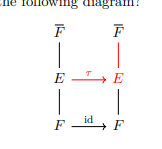

In this case, we define the **Galois group** as
$$\begin{align*}
{ \mathsf{Gal}} (L/k) \mathrel{\vcenter{:}}=\mathop{\mathrm{Aut}}_{{ \mathsf{Fields}_{k} }} (L/k)
.\end{align*}$$

For $L/k$ algebraic and $\operatorname{ch}k = 0$, $L/k$ is Galois $\iff L/k$ is normal.

If $L/k$ is Galois, then $L/F$ is **always** Galois. Moreover, $F/k$ is Galois if and only if ${ \mathsf{Gal}} (L/F) {~\trianglelefteq~}{ \mathsf{Gal}} (L/k)$

[figure not shown]

> Link to diagram

In this case,
$$\begin{align*}
{ \mathsf{Gal}} (F/k) \cong \frac{{ \mathsf{Gal}} (L/k)}{{ \mathsf{Gal}} (L/F)}
.\end{align*}$$

Let $L/K/k$ with $L/k$ Galois. Then
$$\begin{align*}
K/k \text{ is Galois } \iff { \mathsf{Gal}} (L/K){~\trianglelefteq~}{ \mathsf{Gal}} (L/k)
,\end{align*}
and moreover \({ \mathsf{Gal}} (K/k) = G\).$$

**(Click to expand proof)**

- Note separability is distinguished, so $K/k$ is separable.
- $K/k$ is Galois $\iff$ $F/k$ is normal (since we already have separability).
- $\iff \sigma(K) = K$ for all $\sigma\in G$
- $\iff \sigma H \sigma^{-1}= H$ for all $\sigma \in G$.

So $H$ is normal and $G/H$ is a group. For the isomorphism, take
$$\begin{align*}
\rho: { \mathsf{Gal}} (L/k) &\to { \mathsf{Gal}} (K/k) \\
\rho &\mapsto { \left.{{\rho}} \right|_{{K}} }
.\end{align*}
This is well-defined since by normality \(\sigma(K) = K\). Any \(f\in \ker \rho\) is the identity on \(K\), so \(f\in { \mathsf{Gal}} (L/K)\) and \(\ker \phi = H\). Since \(L/K\) is Galois, every \(f\in { \mathsf{Gal}} (K/k)\) lifts to \({ \mathsf{Gal}} (L/k)\), making \(\rho\) surjective.$$

- ${\mathbb{Q}}(\zeta_3, 2^{1/3})$ is normal but ${\mathbb{Q}}(2^{1/3})$ is not since the irreducible polynomial $x^3 - 2$ has only one root in it.
- ${\mathbb{Q}}(2^{1/3})$ is not Galois since its automorphism group is too small (only of size 1 instead of 3?).
- ${\mathbb{Q}}(2^{1/4})$ is not Galois since its automorphism group is too small (only of size 2 instead of 4). However, the intermediate extensions ${\mathbb{Q}}(2^{1/4}) / {\mathbb{Q}}(2^{1/2})$ and ${\mathbb{Q}}(\sqrt 2) / {\mathbb{Q}}$ are Galois since they are quadratic. Slogan: “Being Galois is not transitive in towers.”
- A quadratic extension that is not Galois: $\operatorname{SF}(x^2 + y) \in {\mathbb{F}}_2(y)[x]$, which factors as $(x - \sqrt{y})^2$, making the extension not separable.

## 7.5 Fundamental Theorem of Galois Theory

Let $L/k$ be a Galois extension, then there is a correspondence:
$$\begin{align*}
\left\{{\substack{\text{Subgroups } H \leq { \mathsf{Gal}} (L/k)}}\right\}
&\rightleftharpoons
\left\{{\substack{\text{Fields } F \text{ such}\\ \text{that } L/F/k}}\right\} \\
H &\rightarrow \left\{{\substack{E^H \mathrel{\vcenter{:}}=~\text{The fixed field of $H$}}}\right\} \\
\left\{{\substack{{ \mathsf{Gal}} (L/F) \mathrel{\vcenter{:}}=\left\{{ \sigma \in { \mathsf{Gal}} (L/k) {~\mathrel{\Big|}~}\sigma(F) = F}\right\}}}\right\} &\leftarrow F
\end{align*}$$

- This is contravariant with respect to subgroups/subfields.
- $[F: k] = [G: H]$, so degrees of extensions over the base field correspond to indices of subgroups.
- $[K : F] = {\left\lvert {H} \right\rvert}$
- $L/F$ is Galois and $Gal(K/F) = H$
- $F/k$ is Galois $\iff H$ is normal, and ${ \mathsf{Gal}} (F/k) = { \mathsf{Gal}} (L/k)/H$.
- The compositum $F_1 F_2$ corresponds to $H_1 \cap H_2$.
- The subfield $F_1 \cap F_2$ corresponds to $H_1 H_2$.

A trick for remembering the degree/index correspondence:

[figure not shown]

> Link to Diagram
- If $\operatorname{ch}k = 0$ or $k$ is finite, then $k$ is perfect.
- $k = {\mathbb{C}},{\mathbb{R}}, {\mathbb{Q}}, {\mathbb{F}}_p$ are perfect, so any finite normal extension is Galois.
- Every splitting field of a polynomial over a perfect field is Galois.

If $F/k$ is finite and Galois and $L/k$ is arbitrary, then $FL/L$ is Galois and
$$\begin{align*}
{ \mathsf{Gal}} (FL/L) = { \mathsf{Gal}} (F / F\cap L) \subset { \mathsf{Gal}} (F/k)
.\end{align*}$$

## 7.6 Quadratic Extensions

If ${\mathbb{F}}$ is a field with $\operatorname{ch}({\mathbb{F}})\neq 2$ and $E_{/{\mathbb{F}}}$ is a degree 2 extension, then $E$ is Galois and $E = F(\sqrt{a})$ for some squarefree $a\in {\mathbb{F}}$.

If $E_{/{\mathbb{Q}}}$ is a quadratic extension, $E = {\mathbb{Q}}(\sqrt q)$ for some $q\in {\mathbb{Q}}$ squarefree. Explicitly, use the primitive element theorem to write $E = {\mathbb{Q}}(\alpha)$, let $f$ be the minimal polynomial, then take $q=b^2-4ac$. One can do slightly better by writing $b^2-4ac = a/b$ so that $\sqrt{b^2-4ac}=\sqrt{ab}/b$ and taking $q=ab$.

For ${\mathbb{F}}_p$ a finite field of prime order, all quadratic extensions $E/{\mathbb{F}}_p$ are isomorphic.

# 8 Distinguished Classes

> See http://math.wsu.edu/students/jstreipel/notes/galoistheory.pdf

A collection of field extensions $\mathcal{S}$ is **distinguished** iff

1. (Transitive property) For any tower $L/K/k$, the extension $L/k \in \mathcal{S} \iff L/K \in {\mathcal{S}}$ (upper transitivity) and $K/k\in \mathcal{S}$ (lower transitivity):

[figure not shown]

> Link to Diagram
2. (Lifting property) Lifts of distinguished extensions are distinguished: $K/k\in \mathcal{S}$ and $L/k$ any extension $\implies LK/L \in \mathcal{S}$:

[figure not shown]

> Link to Diagram
3. (Compositing property) Whenever $L/k, K/k\in {\mathcal{S}}$, the amalgam $LK/k \in {\mathcal{S}}$ as well:

[figure not shown]

> Link to Diagram

> One is supposed to think of $LK/L$ as a “lift” of $K/k$.

The following classes of extensions are distinguished:

- Algebraic.
- Finite.
- Separable.
- Purely inseparable.
- Finitely generated.
- Solvable.

Normal extensions are *not* distinguished, since they fail the forward implication for (lower) transitivity. However, they do have the (forward implication) upper transitive, lifting, and compositing properties.

As a consequence, Galois extensions are also not distinguished.

For $L/F/k$: $L/k$ normal/algebraic/Galois $\implies L/F$ normal/algebraic/Galois.

### 8.0.1 Algebraic Extensions

If $L/K/k$ (not necessarily finite) with $L/K$ and $K/k$ both algebraic, then $L/k$ is algebraic.

**(Click to expand proof)**

- We want to show every $\alpha \in L$ is algebraic over $k$, and it suffices to show $\alpha$ is algebraic over some finite subextension $k(S)$.
- Pick $\alpha\in L$, then $\alpha$ is algebraic over $K$ by assumption, so it is a root of some $f\in K[x]$.
- Let $S$ be the finitely many coefficients of $f$, then $\alpha$ is algebraic over $k(S)$.
- Note that $k(S)/k$ is finite and thus algebraic, and $k(S,\alpha)/k(s)$ is finite and also algebraic, so we’re reduced to the finite case.
- It suffices to show $k(S, \alpha)/k(s)/k$ is finite, which follows from multiplicativity of degrees.

If $L/K/k$ with $\alpha$ algebraic over $L$, then $\alpha$ is algebraic over $K$ and $\min_{\alpha, L}$ divides $\min_{\alpha, K}$ (so minimal polynomials only get smaller in extensions).

### 8.0.2 Normal Extensions

$E_1/k$ normal and $E_2/k$ normal $\implies E_1E_2/k$ normal and $E_1 \cap E_2 / k$ normal.

[figure not shown]

> Link to diagram

#### 8.0.2.1 Issues with Normal Towers

One can similarly produce towers where the total extension is normal but the lower iterate is not normal: take
$$\begin{align*}
L/K/k \mathrel{\vcenter{:}}={\mathbb{Q}}(2^{1\over 3}, \zeta_3) / {\mathbb{Q}}(2^{1\over 3}) / {\mathbb{Q}}
.\end{align*}
Now \(K/k\) isn’t normal, since \({ \mathsf{Gal}} (L/k) = S_3\) but \({ \mathsf{Gal}} (L/K) = {\mathbb{Z}}/2 \not{~\trianglelefteq~}S_3\).$$

Another example: let $L/k$ be any algebraic extension that isn’t normal, and take $N_k$ to be the normal closure to get $N_k/L$. Concretely, $N_{\mathbb{Q}}/ {\mathbb{Q}}(2^{1\over 3})/{\mathbb{Q}}$ works.

One can produce towers of successively normal extensions whose total extension is not normal in a cheap way: take
$$\begin{align*}
L/K/k \mathrel{\vcenter{:}}={\mathbb{Q}}(2^{1\over 4}) / {\mathbb{Q}}(2^{1\over 2}) / {\mathbb{Q}}
.\end{align*}
Each iterate is normal since it’s quadratic, but the overall extension misses complex roots and is thus not normal.$$

For $L/k$ finite,

[figure not shown]

> Link to Diagram

**(Click to expand proof)**

- Use the fact that for finite extensions, $L/k$ is normal and separable $\iff L$ is the splitting field of a separable polynomial $f\in k[x]$.
- Now regard $f$ as a polynomial in $K[x]$; then $L$ is still the splitting field of $f$ over $K$, done.

Alternatively,

- Let $\alpha\in L$ be a root of $f\in K[x]$ with $f$ irreducible, it suffices to show all roots of $f$ are in $L$.
- Let $m\in K[x]$ be the minimal polynomial of $\alpha$ over $K$, and let $m'\in k[x]$ be the minimal polynomial of $\alpha$ over $k$.
- Since $L/k$ is normal and $\alpha\in L$, $m'$ splits in $L$.
- Minimal polynomials are divisible in towers, so $m$ divides $m'$. Since $m'$ splits in $L$, so must $m$.

**(Click to expand proof)**

- Suppose $L/K/k$ with $L/k$ normal, we want to show $L/K$ is normal.
- Use the embedding characterization, it suffices to show that every embedding $\sigma: L\hookrightarrow\mkern 1.5mu\overline{\mkern-1.5muK\mkern-1.5mu}\mkern 1.5mu$ satisfies $\operatorname{im}\sigma = L$:

[figure not shown]

> Link to Diagram
- Now just use the fact that $\mkern 1.5mu\overline{\mkern-1.5muk\mkern-1.5mu}\mkern 1.5mu = \mkern 1.5mu\overline{\mkern-1.5muK\mkern-1.5mu}\mkern 1.5mu$, and since $k\subseteq K$, any $K{\hbox{-}}$morphism is also a $k{\hbox{-}}$morphism.
- Since $L/k$ is normal, $\sigma(L) = L$ and $L/K$ is thus normal.

# 9 Galois Theory

> Some useful exercises and solutions: https://feog.github.io/chap4.pdf
- Given $x\mathrel{\vcenter{:}}=\sqrt{a} + \sqrt{b}$, to find a minimal polynomial consider $x^2, x^3,\cdots$ and try to get a linear combination. Then check if its irreducible.
  - General strategy here: try to isolate radicals on one side, then raise both sides to that power.
- To find a minimal polynomial for an element $\alpha$, figure out the dimension of ${\mathbb{Q}}(\alpha)/{\mathbb{Q}}$ – say it’s $n$, then $1, \alpha, \cdots, \alpha^n$ must be a ${\mathbb{Q}}{\hbox{-}}$linearly dependent set, so you compute these powers and fiddle with ${\mathbb{Q}}$ coefficients (or invert a matrix).
- Useful trick: for $x \mathrel{\vcenter{:}}=\sqrt{a} + \sqrt{b}$, compute $x,x^2, x^3, x^4$ and write them in terms of the basis $\left\{{1, \sqrt{a}, \sqrt{b}, \sqrt{ab}}\right\}$. Then put this linear system into a matrix and invert:
  $$\begin{align*}
  A\mathbf{v} = \mathbf{c} \mathrel{\vcenter{:}}= A {\left[ {1, \sqrt a, \sqrt b, \sqrt{ab} } \right]} = {\left[ {x, x^2, x^3, x^4} \right]}
  .\end{align*}
  Once you get \(A^{-1}\mathbf{x} = \mathbf{b}\), read off the first row dotted against \(\mathbf{b}\) to get a polynomial in \(x\).$$
- In general: take $\alpha$, sort out the degree $n$ of the extension ${\mathbb{Q}}(\alpha)/{\mathbb{Q}}$, and use the basis $1,\alpha,\alpha^2,\cdots, \alpha^{n-1}$.
- A trick to remember how degrees, indices and sizes match up: $L/K/F$ corresponds to $1/H/G$, and $[L:K] = [H:1] = \# H$, $[F:K] = [G:H]$, $[L:F] = [G:1] = \# G$, etc.
- Trick: once you find $\operatorname{SF}(f)/{\mathbb{Q}}$, if any subextension is not normal over ${\mathbb{Q}}$, then $G$ can not be abelian.
  - Example: $f(x) = x^3-2$ splits in ${\mathbb{Q}}(\zeta_3, 2^{1\over 3})$ which has a non-normal subextension ${\mathbb{Q}}(2^{1\over 3})$, forcing $G= S_3$.
- If $\alpha\beta \in {\mathbb{Q}}$, then $\alpha \in {\mathbb{Q}}(\beta)$ and vice-versa (I think).
- Checking subgroup lattices: https://hobbes.la.asu.edu/groups/groups.html
- De-nesting radicals:

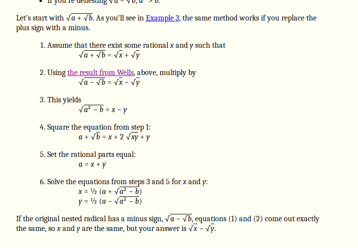

Assume all extensions here are algebraic and finite. Let $f\in {\mathbb{Q}}[x]$ with $n \mathrel{\vcenter{:}}=\deg f$.

- Show your extension is Galois (normal and separable)
  - Show $f$ is irreducible and separable.
- Find the degree of the extension $d$, since then $\# G = d$.
  - Note that in general, $G\leq S_n$ and $n\neq d$, $\# G\neq n$.
- Obtain $n\divides d \mathrel{\vcenter{:}}=\# G \divides n!$ and $G\leq S_n$ is a transitive subgroup, list possibilities.
- Rule out cases or determine the group completely by finding cycle types.

Consider $f(x) \mathrel{\vcenter{:}}= x^5-9x+3$, let $L\mathrel{\vcenter{:}}=\operatorname{SF}(f)/{\mathbb{Q}}$.

- $f$ is irreducible: Apply Eisenstein with $p=3$.
- $f$ is separable:
  - ${\mathbb{Q}}$ is perfect, so irreducible implies separable.
- $L$ is Galois:
  - $L/{\mathbb{Q}}$ is a finite extension over a perfect field and thus automatically separable.
  - $L/{\mathbb{Q}}$ is the splitting field of a separable polynomial, and thus normal.
- Since $L$ is Galois, $\# G = d \mathrel{\vcenter{:}}=[L: {\mathbb{Q}}]$, so try to compute the degree by computing the splitting field (and its degree) explicitly.
  - Here: difficult! The roots are complicated.
- Since $L$ is Galois, $G\leq S_5$ is a transitive subgroup. Possibilities:
  $$\begin{align*}
  S_5, A_5 , F_5\cong C_5\rtimes C_4, D_5, C_5
  .\end{align*}$$
- Claim: $G = S_5$.
  - Reduce mod 2: $(x^2 + x + 1) (x^3 + x^2 + 1)$, yielding a cycle type $(2, 3)$. This rules out
    - $C_5, D_5$ since $3\notdivides 5, 10$.
    - $A_5$, since this is an odd number of even length cycles.
    - $F_5$ since $3\notdivides 20$.
  - So this only leaves $S_5$.

## 9.1 Showing Extensions are Galois

Showing your polynomial is irreducible:

- Eisenstein (including shifting/inverting tricks, see section below)
- To show $f$ is irreducible, it suffices to show it is irreducible over any ${\mathbb{F}}_p[x]$.
- A quadratic with no real roots is irreducible.

Showing your polynomial is separable:

- Show directly that $f$ has distinct roots in $\mkern 1.5mu\overline{\mkern-1.5muk\mkern-1.5mu}\mkern 1.5mu$ by factoring it.
- For perfect fields, irreducibles are automatically separable.
- For $f$ irreducible, $f$ is separable iff $f'(x) \not\equiv 0$.

Showing your *extension* is separable:

- Splitting fields of separable polynomials are automatically separable *and* normal (and thus Galois).
- Algebraic extensions of a perfect field are automatically separable.
  - In particular, extensions over ${\mathbb{Q}}$ or any $\operatorname{ch}k = 0$ are separable, and one only needs to show normality.
- (Hard) Show $[L:k]_s = [L:k]$.
- (Hard) Use that separability is a distinguished class.

Showing your extension is normal:

- Show that $L/k$ is finite and the splitting field of some separable polynomial.

Showing your extension $K/k$ is Galois:

- Show normality and separability.
- Show $K$ is the splitting field of a separable polynomial (“separable splitting field”)
- Automatic when $K/k$ is algebraic and a finite field, since it’s the splitting field of $x^{p^n}-x$.

## 9.2 Irreducibility

If $f\in {\mathbb{Z}}[x]$ is monic and there exists any prime $p$ such that $f\operatorname{mod}p$ is irreducible in ${\mathbb{F}}_p[x]$, then $f$ irreducible in ${\mathbb{Q}}[x]$.

Finding a good prime for this is hard, but irreducibility can be checked exhaustively in small fields: just enumerate all polynomials and try polynomial long division.

$f(x) \mathrel{\vcenter{:}}= x^4 + x + 1$ is irreducible in ${\mathbb{Z}}[x]$, since checking manually in ${\mathbb{F}}_2[x]$ shows that $0, 1$ are not roots $\operatorname{mod}2$ so there is not linear factor. Manually dividing $a_1 x^2 + a_2 x + a_3$ for $a_i\in 0, 1$ leaves remainders, so there are no quadratic factors.

If
$$\begin{align*}
f(x) = \sum_{i=0}^n \alpha_i x^i = a_nx^n + a_{n-1}x^{n-1} + \cdots + a_1 x + a_0 \in {\mathbb{Q}}[x]
.\end{align*}
then \(f\) will be irreducible over \({\mathbb{Q}}[x]\) (and thus over \({\mathbb{Z}}[x]\) by Gauss’ lemma) if \(\exists p\) such that$$

- $p$ divides every coefficient *except* $a_n$ and
- $p^2$ does not divide $a_0$.

Note that if $f$ is monic, it suffices to find any prime dividing all of the non-leading terms.

If $f(x+a)$ satisfies Eisenstein for any $p$, then $f$ is irreducible. This is generally because $\Delta_{f(x)} = \Delta_{f(x + a)}$, and if $p$ works for Eisenstein on any $f$ then $p\divides \Delta_f$.

Set $f(x) \mathrel{\vcenter{:}}= x^2+x+2$, then $f(x+3) = x^2 + 7x + 14$ and Eisenstein applies at $p=7$.

If $n \mathrel{\vcenter{:}}=\deg(f)$ and $x^n f(1/x)$ is irreducible, then $f$ is irreducible. Note that this is just reversing the coefficients.

Take $f(x) \mathrel{\vcenter{:}}= 2x^5 -4x^2-3$, then for $g(x) \mathrel{\vcenter{:}}= 3x^5 +4x^2 - 2$ Eisenstein applies with $p=2$.

If $f(x) \equiv b(x+a)^n\operatorname{mod}p$ for some $p$ where $n\mathrel{\vcenter{:}}=\deg f$, then Eisenstein may work on $f(x-a)$ using the prime $p$. Note the change in signs/reverse translation.

In other words, reduce mod $p$ for various $p$, and if any $p$ collapses $f$ to a power of a linear factor, use that $p$ for Eisenstein.

Check
$$\begin{align*}
f(x) \mathrel{\vcenter{:}}= x^3 + x^2 -48 x + 128 \leadsto f(x)\equiv (x-3)^3 \operatorname{mod}5
,\end{align*}
and Eisenstein on \(f(x+3)\) with \(p=5\) works.$$

## 9.3 Computing

### 9.3.1 Misc Useful Facts

Once you’ve confirmed that you have a Galois extension, some useful tricks are available:

- The size $\# G(f)$ is the degree $[\operatorname{SF}(f) : {\mathbb{Q}}]$.
- The degree of $[{\mathbb{Q}}(\alpha): {\mathbb{Q}}]$ is the degree of $\min_{\alpha}(x)$, or any irreducible polynomial with $\alpha$ as a root.
  - Note that ${\mathbb{Q}}(\alpha)\neq \operatorname{SF}(f)$ in general.
- If $f=\prod(x-r_i)$, then $\operatorname{SF}(f)$ contains every ${\mathbb{Q}}(r_i)$. Thus
  $$\begin{align*}
  [{\mathbb{Q}}(r_i) : {\mathbb{Q}}] = d \implies
  d\divides [\operatorname{SF}(f): {\mathbb{Q}}]
  .\end{align*}
  Note that \(d\neq \deg f\) in general!$$
- Reminder of rational roots test: for $f(x) = a_nx^n + \cdots + a_0$, rational roots are of the form $p_0/p_n$ where $p_i \divides a_i$.
- ${ \mathsf{Gal}} (L/k)$ permutes the roots of any irreducible polynomial in $k[x]$. In particular, if $L=\operatorname{SF}(f)$ with $f$ reducible, then $G$ must send roots of irreducible factors to conjugates of the same factor.
- ${\mathbb{Q}}(\zeta_a) = {\mathbb{Q}}(\zeta_b) \iff a = 2b$ and $b$ is odd.
- If there are $k$ complex conjugate pairs (accounting for $2k$ roots) then $G$ contains a cycle $(1,2)(3,4)\cdots(2k-1,2k)$.
- If all exponents are even, $f(r) = 0 \iff f(-r) = 0$, so roots occur in pairs $(r, -r)$.
  - Pairs are preserved by $G$ in the sense that every $\sigma\in G$ satisfies either $\left\{{r, -r}\right\}\mapsto \left\{{r, -r}\right\}$ or $\left\{{r, -r}\right\} \mapsto \left\{{s, -s}\right\}$ for another pair.
  - Example: $x^4-5x^2+5$ has two pairs.

### 9.3.2 Transitive Subgroups

If $f\in k[x]$ is irreducible, then ${ \mathsf{Gal}} (\operatorname{SF}(f)/k) \leq S_n$ is **always** a transitive subgroup, i.e. it acts transitively on the set of roots.

$$\begin{align*}
n\divides \# { \mathsf{Gal}} (K/{\mathbb{Q}}) \divides n!
.\end{align*}$$

Why: ${ \mathsf{Gal}} (K/{\mathbb{Q}}) \cong G\leq S_n$, and Lagrange yields $\#H \divides n!$. Note that $G$ acts on $R$ the set of $n$ roots, and since it acts transitively, $R$ is a single orbit. By orbit stabilizer, ${\mathcal{O}}_r \cong G/{\operatorname{Stab}}_G(r)$ and thus
$$\begin{align*}
\# G = \# {\mathcal{O}}_r \cdot \# {\operatorname{Stab}}_G(r)
,\end{align*}
so both terms on the right-hand side patently divide \(\# G$$

Write $C_n$ for the cyclic group of order $n$. The following are transitive subgroups of $S_n$ for small $n$, where blue groups are nonabelian:

| $n \text{ in }S_n$ | Transitive Subgroups | Sizes |
| --- | --- | --- |
| 1 | 1 | 1 |
| 2 | $S_2 \cong C_2$ | 2 |
| 3 | ${\color{blue}S_3\cong D_3}, A_3 \cong C_3$ | 6,3 |
| 4 | ${\color{blue}S_4, A_4, D_4}, C_4, C_2^2$ | 24,12,8,4,4 |
| 5 | ${\color{blue}S_5, A_5 , F_5\cong C_5\rtimes C_4, D_5}, C_5$ | 120,60,20,10,5 |

Other useful facts:

- $\# D_n = 2n$, $\#S_n = n!, \# A_n = n!/2$, and $\# F_5 = 20$.
- For degree 8 extensions (which sometimes arise as quadratic extensions of degree 4 extensions): $Q_8 \leq S_8$ is transitive and nonabelian of order 8, and has presentation
  $$\begin{align*}
  Q_{8}=\left\langle\alpha, \beta \mathrel{\Big|}\alpha^{4}=\beta^{4}=1, \alpha \beta \alpha=\beta, \beta^{2}=\alpha^{2}\right\rangle
  .\end{align*}
  Note that \(Q_8 \leq S_8\) but \(Q_8\not\leq S_{<7}\).$$
- $F_5$ has presentation
  $$\begin{align*}
  \left\langle{a,b {~\mathrel{\Big|}~}a^5, b^4, bab^{-1}= a^2}\right\rangle
  .\end{align*}$$

### 9.3.3 Distinguishing Groups

> Material borrowed from https://kconrad.math.uconn.edu/blurbs/galoistheory/galoisSnAn.pdf

By $n$ in $G\leq S_n$:

$n=4$:

The following are the cycle types that can occur:

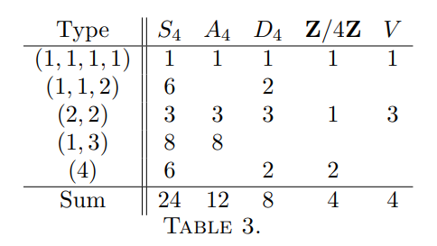

Useful fact: if $G \leq S_n$ for $n$ prime contains a 2-cycle and a $p{\hbox{-}}$cycle, then $G\cong S_n$. Note that for $n$ not prime, a transposition and an $n{\hbox{-}}$cycle isn’t enough, since one needs the specific $n{\hbox{-}}$cycle $(1,2,\cdots,n)$ in general.

If $n>2$ and $G$ contains a 3-cycle and an $n{\hbox{-}}$cycle, then $G = A_n$ or $S_n$. Note that by Orbit-Stabilizer $n\divides \# G$, and if $n$ is prime then by Cauchy there is an $n{\hbox{-}}$cycle (but this is not always the case). In fact, it suffices to find a $k{\hbox{-}}$cycle for any $k\geq n/2$, which can be found by reducing mod $p$ and examining cycle types.

Moreover, if $G$ contains a 2-cycle (transposition), then $G = S_n$.

Some useful generating sets: see https://kconrad.math.uconn.edu/blurbs/grouptheory/genset.pdf

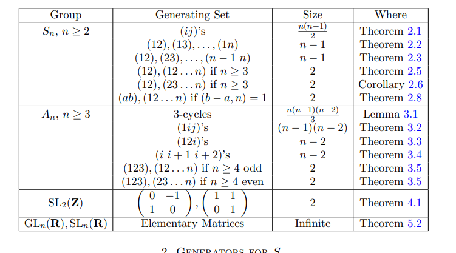

### 9.3.4 Density: Cycle Types

For any $p\not\divides \Delta$, writing $f(x) = \prod_{i=1}^m f_i(x) \operatorname{mod}p$, $G$ contains a cycle of type $(\deg f_1, \deg f_2, \cdots, \deg f_m)$. Equivalently, if $\tilde f \mathrel{\vcenter{:}}= f\operatorname{mod}p$, then $G(\tilde f) \leq G(f)$ is a subgroup.

Warning: this only works if the $f_i$ are distinct, i.e. there are no repeated factors in the factorization $\operatorname{mod}p$.

You can use this to rule out types of groups using Lagrange’s theorem: if you find a cycle of length $m$ which doesn’t divide $\# H$, then $H$ isn’t a possibility! Example: $\deg f=5$ with exactly one conjugate pair of roots, then there is a 5-cycle $\sigma \mathrel{\vcenter{:}}=(1,2,3,4,5)$ because $5\divides \# G$ and a 2-cycle $\tau \mathrel{\vcenter{:}}=(1,2)$ coming from complex conjugation. There check that $a_1 \mathrel{\vcenter{:}}=\sigma \tau \sigma^{-1}= (1, 5)$ and $a_1 \tau = (1, 5, 2)$ is a 3-cycle, so $3\divides \# G$. This rules out $F_5$ which is of order 20, since $3\not\divides 20$.

Consider $f(x) = x^5+2x+1$. Reducing to ${\mathbb{F}}_3$ yields no roots, so $f$ is irreducible, and moreover $G(f)$ contains a 5-cycle. Reducing to ${\mathbb{F}}_7$ splits $f$ as $(x+2)(x+3)(x^3+2x^2+5x+5)$, so $G(f)$ contains a 3-cycle.

Take $f(x) \mathrel{\vcenter{:}}= x^6 + x^4 + x + 3$, then

$$\begin{align*}
f(x) &\equiv (x+1)(x^2 + \cdots)(x^3 + \cdots) \operatorname{mod}2 &\implies \text{type } (1,2,3) \in G \\
f(x) &\equiv x(x+2)(x^4 + \cdots) \operatorname{mod}3 &\implies \text{type } (1,1,4) \in G \\
.\end{align*}$$

Take $f(x) \mathrel{\vcenter{:}}= x^4+x+1$, then
$$\begin{align*}
f(x) &\equiv x^4+x+1 \operatorname{mod}2 &\implies \text{type } (4) \\
f(x) &\equiv (x-1)(x^3+x^2+x-1) \operatorname{mod}3 &\implies \text{type } (1,3) \\
.\end{align*}$$

Let $f(x) = x^6 + x^4 + x + 3$, reduce $\operatorname{mod}11$ to get a cycle type $(1, 5)$. So $G\leq S_6$ contains a 5-cycle, where $5>n/2 \mathrel{\vcenter{:}}= 6/2=3$, meaning $G = A_n, S_n$. Now reduce $\operatorname{mod}p$ for various $p$ to look for a cycle type of the form $(2,1,1,\cdots)$ or $(3,1,1,\cdots)$. This is hard, but $f\operatorname{mod}2$ has type $(1,2,3)$ and $\qty{ (a,b)(c,d,e) }^3 = (a, b)$, so $G$ contains a transposition and thus $G = S_n = S_6$.

Let $f(x) = x^7-x-1$, reduce $\operatorname{mod}2$ to get a 7-cycle, and $\operatorname{mod}3$ to get $(2, 5)$. Then use $(2, 5)^5 = (2,1,1,\cdots)$ to get a transposition, So $G = S_7$.

Let $f(x) \mathrel{\vcenter{:}}= x^7-7x+10$. Reducing $\operatorname{mod}3$ yields $(2, 5)$ and $(2, 5)^5 = (2, \cdots)$ and have a transposition. Since $5>n/2=7/2$, $G = S_7$.

### 9.3.5 Discriminants

For $f = \sum a_k x^k$ monic,
$$\begin{align*}
\Delta_f = \prod_{i < j} (r_i - r_j)^2
.\end{align*}$$

Note that $\Delta = 0$ when $f$ has a repeated root.

For cubics,

- $\Delta > 0 \implies 3$ distinct real roots
- $\Delta < 0 \implies 1$ real root and 1 conjugate pair.

For $f$ a cubic:
$$\begin{align*}
\Delta_f
&= (r_1 - r_2)^2 (r_1 - r_3 )^2 \\
&\quad (r_2 - r_3)^2
.\end{align*}$$

For $f$ a quartic:
$$\begin{align*}
\Delta_f
&= (r_1 - r_2)^2(r_1 - r_3)^2 (r_1 - r_4)^2 \\
& \quad (r_2 - r_3)^2 (r_2 - r_4)^2 \\
& \quad (r_3 - r_4)^2
.\end{align*}$$

In general, for a degree $n$ polynomial this will have $n(n-1)/2$ terms.

In general,
$$\begin{align*}
G \subseteq A_n \iff \sqrt{\Delta} \in k
,\end{align*}
i.e. \(\Delta\) is a perfect square in the ground field \(k\).$$

Some special cases of discriminant values:

- Quadratics:
  $$\begin{align*}
  f(x) = ax^2 + bx + c
  \implies
  \Delta = b^2-4ac
  .\end{align*}$$
- Cubics:
  - General:
    $$\begin{align*}
    f(x) = ax^3 + bx^2 + cx + d \implies \Delta = b²c² - 4ac³ - 4b³d - 27a²d² + 18abc
    .\end{align*}
    Note that you can depress a general cubic by substituting \(t=x - {b\over 3a}\), yielding
    \begin{align*}
    f(t) = t³ + pt + q \implies \Delta = -4p³-27q²
    .\end{align*}$$

Some useful facts:

- $\Delta = 0 \iff f$ has a repeated root.
- $G\hookrightarrow A_n \iff \Delta$ is a perfect square in $k$.

## 9.4 Worked Examples

If $\deg f = 5$ with exactly 3 real roots and one non-real complex conjugate pair, then $G(f) = S_5$. $G$ contains a transposition, namely complex conjugation on the conjugate pair. This already implies $G\neq A_5$, since a transposition is an odd number of even cycles.

The claim is that $G$ contains an element of order 5, i.e. a 5-cycle, which is enough to generate $S_5$. This follows because

- Galois acts transitively, so there is a length 5 orbit.
- By Orbit-Stabilizer, 5 divides $\# G$.
- By Sylow, there is an element of order 5.

So $G = S_5$.

### 9.4.1 Quadratics

Every degree 2 extension $L/k$ is Galois, except possibly in characteristic 2:

- If $\alpha\in L \setminus k$ then $\min_{\alpha}(x) \in L[x]$ must split in $L[x]$, so $L$ is automatically a splitting field.
  - Why? $\alpha\in L \implies \min_{\alpha}(x) = (x- \alpha)g(x)$ which forces $\deg(g) = 1$.
- If $\operatorname{ch}(k) \neq 2$, then $L$ is separable since
  $$\begin{align*}
  \min_{ \alpha}(x)' = 2x + \cdots \not\equiv 0
  ,\end{align*}$$

One can complete the square for quadratics:
$$\begin{align*}
f(x)=x^{2}+\alpha x+\beta=\left(x-\frac{\alpha}{2}\right)^{2}+\beta-\frac{\alpha^{2}}{4} \text { . }
.\end{align*}$$

Thus it suffices to consider quadratics of the form $x^2+a$.

- $G(x^2-m) = C_2$ for $m$ not a perfect square.
  - $x^2-m = (x+\sqrt{m})(x-\sqrt{m})$, so the splitting field is ${\mathbb{Q}}(\sqrt{m})$ of degree 2.
  - Since $G\leq S_2$ and has order 2, $G= S_2 \cong C_2$.
  - Concretely, take $m=2$, then $G = \left\{{\operatorname{id}, \tau}\right\}$ where $\tau: \sqrt{2} \mapsto -\sqrt{2}$, and correspondingly $a+b\sqrt{2} \mapsto a-b\sqrt{2}$.
- $G((x^2-2)(x^2-3)) = C_2\times C_2$.
  - Since $G$ must permute irreducible factors, labeling the roots $r_1, r_2 = \pm \sqrt{2}$ and $r_3, r_4 = \pm \sqrt{3}$, we have
    $$\begin{align*}
    G \subseteq \left\langle{(1, 2), (3, 4)}\right\rangle = \left\{{\operatorname{id}, (1,2), (3,4), (1,2)(3,4)}\right\} \cong C_2\times C_2
    .\end{align*}$$
  - $\# G = 4$, taking the tower ${\mathbb{Q}}(\sqrt 2, \sqrt 3) / {\mathbb{Q}}(\sqrt 2)/ {\mathbb{Q}}$ and noting $\sqrt 3 \not\in {\mathbb{Q}}(\sqrt 2)$ which makes each step degree 2. So this forces $G \cong C_2\times C_2$.

### 9.4.2 Cubics

Tricks/reminders:

- Try the rational roots test to check irreducibility, since reducible implies there’s a linear factor.
- Nice situation: one real and two complex roots. Try Calculus and MVT to reason about real roots. This immediately yields $S_3$.
- Otherwise, 3 real roots (or no easy way to check root types). Try discriminant classification: put in the form $t^3+pt+q$, potentially using $t=x-b/3a$, then $\Delta = -4p^3-27q^2$.

If $n \mathrel{\vcenter{:}}=\deg f$ is odd, then $f$ has at least one real root. If $f$ has two non-real roots, then $G$ contains a transposition. If $n$ is prime, then $G$ contains an $n{\hbox{-}}$cycle (by transitivity and Cauchy), forcing $G = S_n$.

Let $f(x) = x^3-2$.

Then $f'(x) = 3x^2$, so $f$ is monotone increasing. By the MVT, checking $f(-2)<0$ and $f(2)>0$, $f$ has a single real root in $[-2, 2]$. The other two must be a complex conjugate pair.

Alternatively, just factor the darn thing: $f(x) = (x-\omega)(x-\zeta_3\omega)(x-\zeta_3^2\omega)$ where $\omega \mathrel{\vcenter{:}}= 2^{1\over 3}$ and $\zeta_3^3=1$.

So $G(f)$ contains a transposition, and since $\deg f = 3$ is prime, $G$ contains a 3-cycle and $G(f) = S_3$.

Let $f(x) = x^3-4x+5$.

Then $f'(x) = 3x^2-4 = 0$ when $x = \pm \sqrt{4/3}$. Checking $f''(x) = 6x$ yields a max at $-\sqrt{4/3}$ and a min at $\sqrt{4/3}$. Checking
$$\begin{align*}
f(4/3) = (4/3)^3-4(4/3)+5 = (64/27)-(16/3)+5 = 55/27 > 0
,\end{align*}
so knowing the general shape of a cubic, there is exactly one real root, somewhere in \((-\infty ,-\sqrt{4/3})\). So \(G(f) = S_3\).$$

Away from $\operatorname{ch}k = 2$, Galois groups of cubics are entirely determined by discriminants:

**There are only two possibilities**: $S_3$ or $A_3 \cong C_3$.

- If $\sqrt{\Delta}\in k$, then $G\cong A_3$.
- Otherwise, $G\cong S_3$.

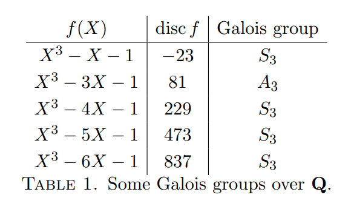

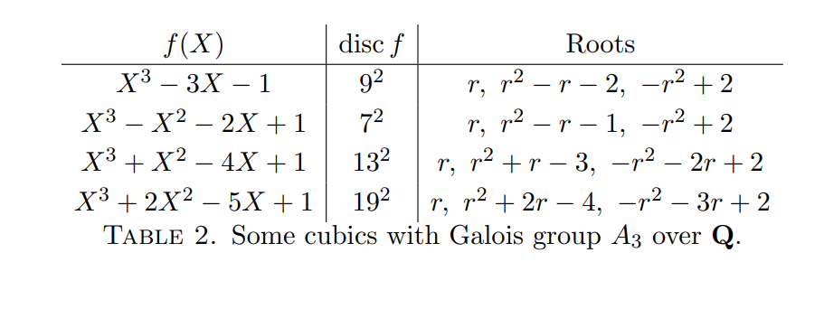

### 9.4.3 Quartics

If
$$\begin{align*}
f(x)=x^{4}+a_{3} x^{3}+a_{2} x^{2}+a_{1} x+a_{0}
\end{align*}
then define the resolvent of \(f\) by
\begin{align*}
R_{4}(t)=t^{3}-a_{2} t^{2}+\left(a_{1} a_{3}-4 a_{0}\right) t+4 a_{0} a_{2}-a_{1}^{2}-a_{0} a_{3}{ }^{2}
.\end{align*}$$

Alternatively, it can be defined in terms of the roots $r_i$:
$$\begin{align*}
\left(x-\left(r_{1} r_{2}+r_{3} r_{4}\right)\right)\left(x-\left(r_{1} r_{3}+r_{2} r_{4}\right)\right)\left(x-\left(r_{1} r_{4}+r_{2} r_{3}\right)\right)
.\end{align*}$$

For depressed quartics,
$$\begin{align*}
f(X)=X^{4}+c X+d \Longrightarrow R_{3}(X)=X^{3}-4 d X-c^{2}
.\end{align*}$$

The Galois groups of irreducible quartics can be determined using discriminants, resolvents, and checking irreducibility:

- If $\sqrt{\Delta}\in {\mathbb{Q}}$, then $G = A_4, C_2^2$.
  - If resolvent is irreducible: $A_4$. Otherwise $C_2^2$.
- If $\sqrt{\Delta}\not\in {\mathbb{Q}}$ then $G = S_4, D_4, C_4$.
  - Is resolvent is irreducible: $S_4$. Otherwise, $D_4$ or $C_4$, argue by cycle types (or if $f$ is irreducible in ${\mathbb{Q}}(\sqrt{\Delta})$, $D_4$).
- Summary:

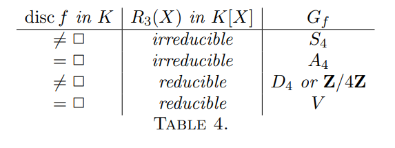

A flow chart summarizing the full process:

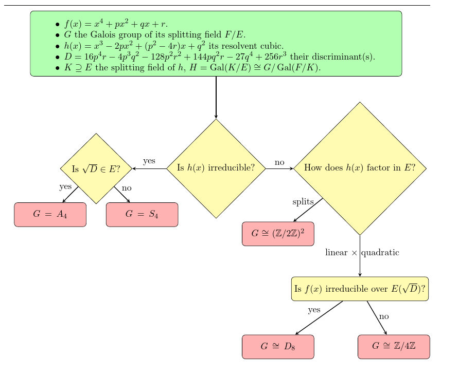

See Hungerford 273 for classification.

- $G(x^4-x-1) = S_4$:
  - Check $f$ is irreducible in ${\mathbb{F}}_2[x]$.
  - $R_3(t) = t^4+4t-1$
- $G(x^4+8x+12) = A_4$:
  - The resolvent cubic is $x^3-48x+64$, which has no rational roots.
  - Now check
    $$\begin{align*}
    \Delta = (-27)(8^4) + (256)(12^3)=(81)(2^{12}) \in {\mathbb{Q}}^2
    ,\end{align*}
    so \(G=A_4\).$$
- $G(x^4+3x+3) = D_4$:
  - The resolvent cubic is $g(x) = x^3-12x+9=(x-3)(x^2+3x-3)$ and $\Delta = 3^3 5^2 7$, so $G = C_4, D_4$.
  - Check $D \mathrel{\vcenter{:}}=\Delta_g = 21$.
  - Check if $g$ is irreducible in ${\mathbb{Q}}(\sqrt{21})$: suppose $x^{4}+3 x+3=\left(x^{2}+a x+b\right)\left(x^{2}-a x+c\right)$, then $-a^{2}+b+c=0, a(c-b)=0, b c=3$
    - From $a(c-b)=0$, if $a=0$ then $b=-c$ and $c^2=3$, but $\sqrt{-3}\not\in {\mathbb{Q}}(D)$. Otherwise $c=b$ and $c^2 = 3$, but $\sqrt{3}\not\in{\mathbb{Q}}(D)$.
  - So $G= D_4$.

### 9.4.4 Cyclotomic Fields

${ \mathsf{Gal}} ({\mathbb{Q}}(\zeta_n)/{\mathbb{Q}}) \cong ({\mathbb{Z}}/n)^{\times}$ and is generated by maps of the form $\zeta_n \mapsto \zeta_n^j$ where $(j, n) = 1$. I.e., the following map is an isomorphism:
$$\begin{align*}
({\mathbb{Z}}/n)^{\times}&\to { \mathsf{Gal}} ({\mathbb{Q}}(\zeta_n), {\mathbb{Q}}) \\
[r] &\mapsto (\phi_r: \zeta_n \mapsto \zeta_n^r )
\end{align*}$$

The splitting field of $x^p-1$ is ${\mathbb{Q}}(\zeta_p)$, and the splitting field of $x^p+1$ is ${\mathbb{Q}}(\zeta_{2p})$.

- $x^p - a$ factors as $\prod_{k=0}^{p-1} (x- \zeta_p^k \omega)$ where $\omega \mathrel{\vcenter{:}}= a^{1\over p}$, so this splits in ${\mathbb{Q}}(\zeta_p, \omega)$ which has degree
  $$\begin{align*}
  \phi(p) \cdot \deg \min_\omega(x) = (p-1)p
  .\end{align*}
  This yields two cyclic subgroups \(C_{p-1}, C_p\) where \(C_p{~\trianglelefteq~}G\), and thus some semidirect product \(C_{p-1} \curvearrowright C_{p}\).$$
- $x^p+a$ factors as $\prod_{k=0}^{p-1}(x - \zeta_p^k \omega )$ for $\omega \mathrel{\vcenter{:}}=(-a)^{1\over p}$.

Also use that splitting fields over ${\mathbb{Q}}$ are always normal, so it suffices to check that $f$ is separable and irreducible to show extensions are Galois.

Degree 3:

- $G(x^3-2): S_3$
  - The roots are $\zeta_3^k \omega$ for $0\leq k \leq 3$, $\omega \mathrel{\vcenter{:}}= 2^{1\over 3}$.
  - The splitting field is ${\mathbb{Q}}(\omega, \zeta_3)$ which has degree $3\phi(3) =6$.
  - The possibilities are $G = A_3\cong C_3, S_3$, and order 6 forces $G=S_3$.
  - Useful alternative:
    - Note that there is exactly one real root and one conjugate pair, so $G$ contains a transposition $(23)$.
    - There is a 3-cycle $(123)$ given by fixing $\omega$ and sending $\zeta_3 \mapsto \zeta_3\omega$, and this is enough to generate $D_3 \cong S_3$.

Degree 4:

- $G(x^4-1) = C_2$:
  - The roots are $\zeta_4^k$ for $0\leq k \leq 3$.
  - The splitting field is ${\mathbb{Q}}(\zeta_4) = {\mathbb{Q}}(i)$ which has degree $\phi(4) = 2$.
  - But this is not a reducible polynomial! Use that that Galois is defined as $\mathop{\mathrm{Aut}}(\operatorname{SF}(f) / {\mathbb{Q}})$ and quadratic extensions are Galois.
- $G(x^4-2) = D_4$:
  - The roots are $\zeta_4^k \omega$ for $0\leq k \leq 3$, where $\zeta_4 = i, \omega = 2^{1\over 4}$.
    - Explicitly, $r_i \in \left\{{\omega, i\omega, -\omega, -i\omega}\right\}$
  - The splitting field is ${\mathbb{Q}}(\omega, \zeta_4)$, which has degree $4\phi(4) = 8$ since $\min_{\zeta_4} = x^2+1$, which is still irreducible over ${\mathbb{Q}}(\omega) \subseteq {\mathbb{R}}$.
  - $D_4 \leq S_4$ is the only transitive subgroup of order 8.
  - Useful note on bounding the size:
    - Any $\sigma \in G$ must preserves roots of $x^4-2$ but also $x^2+1$. So there are at most 4 possibilities for $\sigma(\omega)$, and at most 2 for $\sigma(\zeta_4)$, so $\# G \leq 8$ and $G\neq S_4$.
  - Explicitly, there is a 4-cycle $\sigma = (1,2,3,4)$ generated by $\omega \mapsto \zeta_4 \omega$ and a 2-cycle $(2,4)$ given by complex conjugation, and this generates $D_4$ since $\gcd(4-2, 4) \neq 1$.
    - Why this is a 4-cycle: check $\sigma(i)=i$, and:
      $$\begin{align*}
      \sigma(r_1) &= r_2 = ir_1 \\
      \sigma(r_2) &= \sigma(ir_1) = ir_2 = r_3 \\
      \sigma(r_3) &= \sigma(ir_2) = ir_3 = i(ir_2) = -r_2 = r_4
      .\end{align*}$$

General cases:

- $G(x^p-1) = C_p^{\times}$:
  - ?
- $G(x^4+1) = C_2^2$:
  - This is irreducible because it is irreducible (by having no roots) mod $3$.
  - The roots are $\zeta_8^k$ for $k=1,3,5,7$ coprime to 8, since this is $\Phi_8(x)$.
  - The splitting field is ${\mathbb{Q}}(\zeta_8) = {\mathbb{Q}}(i, \sqrt 2)$, noting that $\zeta_8 = e^{2\pi i \over 8} = e^{\pi i \over 4} = \cos(\pi/4) + i\sin(\pi/4) = (1/2)(\sqrt 2 + i \sqrt{2})$ so we have containment and both are degree $\phi(8)=4$ extensions.
  - This restricts to $C_4, C_2^2$.
  - Reduce $\operatorname{mod}5$ to get $(x^2+2)(x^2+2)$ of cycle type $(2, 2)$, forcing $C_2^2$.
- $G(x^4+2) = D_4$:
  - The roots are $\zeta_8^k \omega$ for $\omega = 2^{1\over 4}, k = 1,3,5,7$ coprime to 8.
  - The splitting field is ${\mathbb{Q}}(\zeta_8, \omega) = {\mathbb{Q}}(\zeta_4, \omega)$.
- $G(x^4+3) = D_4$:
  - The roots are $\zeta_8^k, \omega$ for $\omega = 3^{1\over 4}, k=1,3,5,7$ coprime to 8.
  - The splitting field is ${\mathbb{Q}}(\omega, \zeta_8)$ of degree $\phi(8) = 8$

### 9.4.5 Finite Fields

${ \mathsf{Gal}} ({\mathbb{F}}_{p^n}/{\mathbb{F}}_p) \cong {\mathbb{Z}}/ \left\langle{ n }\right\rangle$, a cyclic group generated by powers of the Frobenius automorphism:
$$\begin{align*}
\varphi_p: {\mathbb{F}}_{p^n} &\to {\mathbb{F}}_{p^n} \\
x &\mapsto x^p
\end{align*}$$

> See D&F p.566 example 7.

## 9.5 Lattices

$n=2$:

- $D_2 \cong 1$
- $A_2 \cong 1$
- $S_2 \cong C_2$

$n=3$:

- $D_3 \cong S_3$
- $A_3 \cong C_3$.

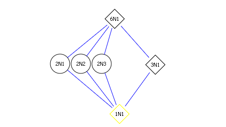

$n=4$:

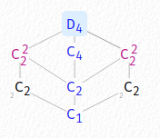

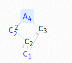

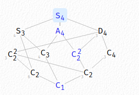

$n=5$:

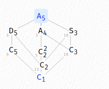

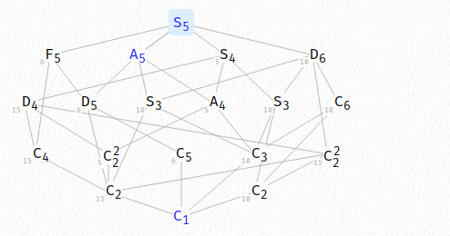

Misc:

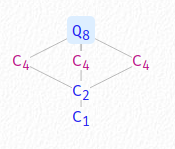

# 10 Modules

## 10.1 Definitions and Basics

Four properties:

- $r(x+y) = rx + ry$
- $(r+s)x = rs + sx$
- $(rs)x= r(s(x))$
- $1_Rx = x$

Note that $M$ is additionally an $R{\hbox{-}}$algebra if the multiplication map is $R{\hbox{-}}$bilinear and so given by $m: M^{\otimes_R 2}\to M$ satisfying
$$\begin{align*}
r. m(a\otimes b) = m(r.a \otimes b) = m(a\otimes r.b) && \forall r\in R, a,b \in M
.\end{align*}$$

$N\subseteq M$ is an $R{\hbox{-}}$submodule iff $N$ is nonempty and for every $r\in R$ and $x, y \in N$, we have $rx+y\in N$.

A map $f: M\to N$ is a **morphism of modules** iff $f(rm + n) = rf(m) + f(n)$.

A map $\phi: M\to N$ is a morphism in ${\mathsf{R}{\hbox{-}}\mathsf{Mod}}$ iff
$$\begin{align*}
\phi(r.x + y) = r.\phi(x) + \phi(y) \in N && \forall r\in R, x,y\in M
.\end{align*}$$

Quotients of modules are easier to reason about additively, writing $M/N = \left\{{x + N}\right\}$ as cosets. Then $(x + N) + (y + N) = (x+y) + N$ and $(x+N)(y+N) = (xy) + N$.

A module is **simple** iff it has no nontrivial proper submodules.

A module $M$ is **decomposable** iff it admits a direct sum decomposition $M \cong M_1 \oplus M_2$ with $M_1, M_2 \neq 0$. An **indecomposable** module is defined in the obvious way.

A module $M$ is **cyclic** if there exists a single generator $m\in M$ such that $M = mR \mathrel{\vcenter{:}}=\left\langle{ m }\right\rangle$.

## 10.2 Structure Theorems

$$\begin{align*}
M / \ker \phi &\cong \operatorname{im}\phi \\
{A+B \over B} &\cong {A\over A \cap B} \\
{M/A \over B/A} &\cong {M\over B} \\
\left\{{\substack{
\text{Submodules of } M \\ \text{containing }N
}}\right\}
&\rightleftharpoons
\left\{{\substack{
\text{Submodules of } M/N
}}\right\}
\\
A &\rightleftharpoons A/N
.\end{align*}$$

Note that the lattice correspondence commutes with sums and intersections of submodules.

If $M_1, M_2 \leq M$ are submodules, then $M = M_1 \oplus M_2$ if the following conditions hold:

- $M_1 + M_2 = M$
- $M_1 \cap M_2 = 0$

## 10.3 Exact Sequences

A sequence of $R{\hbox{-}}$module morphisms \begin{align*} 0 \xrightarrow{d_1} A \xrightarrow{d_2} B \xrightarrow{d_3} C \to 0 \end{align*} is *exact* iff $\operatorname{im}d_i = \ker d_{i+1}$.

Note that $C\cong B/d_1(A)$ always, but $B$ is not a direct sum of the outer terms unless the sequence splits.

A short exact sequence
$$\begin{align*}
\xi: 0 \to A \xrightarrow{d_1} B \xrightarrow{d_2} C \to 0
\end{align*}
has a right-splitting iff there exists a map \(s: C\to B\) such that \(d_2 \circ s = \operatorname{id}_{C}\). \(\xi\) has a left-splitting iff there exists a map \(t:B\to A\) such that \(t \circ d_1 = \operatorname{id}_A\).$$

Let $\xi: 0 \to A \xrightarrow{d_1} B \xrightarrow{d_2} C \to 0$ be a SES, then TFAE

- $\xi$ admits a right-splitting $s: C\to B$.
- $C$ is projective.
- $\xi$ admits a left-splitting $t: B\to A$.
- $A$ is injective.
- $\xi$ is isomorphic to a SES of the form $0\to A \to A \oplus C \to C \to 0$.

**(Click to expand proof)**

Right-splitting implies direct sum:

- Use that $B \subset \ker d_2 + \operatorname{im}s$, writing $b = (b - sd_2(b) ) + sd_2(b)$ and noting
  $$\begin{align*}
  d_2(b - sd_2(b)) = d_2(b) - d_2sd_2(b) = d_2(b) - d_2(b) = 0
  .\end{align*}$$
- Show $\ker d_2 \cap\operatorname{im}s=0$, writing $b$ with $d_2(b) = 0$ and $b = s(c)$ for some $c$ yields
  $$\begin{align*}
  0 = d_2(b) = d_2s(c) = \operatorname{id}_C(c) = c
  .\end{align*}$$

## 10.4 Free and Projective Modules

A **free** module $M$ is a module satisfying any of the following conditions:

- A universal property: There is a set $\mathcal{B}$ and a set map $M \xrightarrow{\iota} \mathcal{B}$ such that every set map $\mathcal{B} \xrightarrow{N}$ lifts:

[figure not shown]

> Link to Diagram
- Existence of a basis:

  There is linearly independent (so $\sum r_i \beta_i = 0 \implies r_i = 0$) spanning set (so $m\in M \implies m = \sum r_i \beta_i$ ) of the form $\mathcal{B} \mathrel{\vcenter{:}}=\left\{{ \beta_i }\right\}_{i\in I}$,
- Direct sum decomposition:

  $M$ decomposes as $M \cong \bigoplus_{i\in I} \beta_i R$, a sum of cyclic submodules.

${\mathbb{Z}}/6$ is a ${\mathbb{Z}}{\hbox{-}}$module that is *not* free, since the element $[3]$ is a torsion element, where $2[3] = [6] = [0]$. This uses the fact that free modules over a PID are torsionfree.

If a module $M$ is free, the **free rank** of $M$ is the cardinality of any basis.

Every free $R{\hbox{-}}$module admits a basis (spanning $R{\hbox{-}}$linearly independent set).

An element $m\in M$ is a **torsion element** if there exists a nonzero $r\in R$ such that $rm = 0_M$. A module $M$ is **torsion-free** if and only if for every $x\in M$, $mx = 0_M \implies m=0_M$, i.e. $M$ has no nonzero torsion elements. Equivalently, defining $M_t \mathrel{\vcenter{:}}=\left\{{ m\in M {~\mathrel{\Big|}~}\exists r\in R, rm = 0_M }\right\}$ as the set of all torsion elements, $M$ is torsion free iff $M_t = 0$. If $M_t = M$, we say $M$ is a **torsion module**.

For $R$ an integral domain, any finitely generated free $R{\hbox{-}}$module $M$ is torsionfree.

**(Click to expand proof)**

- If $M$ is finitely generated, write $M = \left\langle{X}\right\rangle$ with $X\mathrel{\vcenter{:}}=\left\{{x_1, \cdots, x_m}\right\}$ and $\# X<\infty$ a finite generating set.
- Since $M$ is free, there is some maximal subset of generators ${\mathcal{B}}\mathrel{\vcenter{:}}=\left\{{x_1, \cdots, x_n}\right\} \subseteq X$ where $n\leq m$ that is linearly independent.
- Consider $N\leq M$ defined by $\left\langle{{\mathcal{B}}}\right\rangle$; this is a basis for $N$ and makes $N$ free. The claim is now that $M\cong N$, so that any maximal linearly independent subset of generators is all of $X$.
- If $N \not\cong M$, set ${\mathcal{B}}^c \mathrel{\vcenter{:}}= X\setminus{\mathcal{B}}= \left\{{x_{n+1}, \cdots, x_m}\right\}$ to be all generators for $M$ that the basis ${\mathcal{B}}$ misses.
- Then ${\mathcal{B}}^c \cup\left\{{x_{j}}\right\}$ for any $n+1\leq j \leq m$ has a linear dependence, and $r_j x_j + \sum_{k=1}^n r_n x_n = 0$ for some $r_j\neq 0$ implies $r_j x_j = - \sum_{k=1}^n r_n x_n$.
- Let $r$ be the product of all of the scalars obtained this way, so $r = \prod_{k=n+1}^m r_j$, and consider the submodule $rX \leq N \leq M$. We get $rM \leq N \leq M$ since $X$ is a generating set for $M$, so it now suffices to show $rM \cong M$.
- Just define a map $\phi_r: M\twoheadrightarrow rM$ where $m\mapsto rm$, and note $\ker \phi_r =\left\{{ m\in M {~\mathrel{\Big|}~}rm = 0}\right\} = 0$ since $M$ is torsionfree. So $M = M/\ker \phi_r \cong rM$.

${\mathbb{Q}}\in {\mathsf{{\mathbb{Z}}}{\hbox{-}}\mathsf{Mod}}$ is torsionfree, but not free as a ${\mathbb{Z}}{\hbox{-}}$module. This follows because any two elements $a/b, p/q$ are in a single ideal, since taking $d\mathrel{\vcenter{:}}=\gcd(b, q)$ we have $1/a = 1/d + \cdots 1/d$ and similarly $p/q = 1/a + \cdots + 1/a$, so these are in $\left\langle{ 1/d }\right\rangle$. So any basis has size one, which would mean ${\mathbb{Q}}= \left\{{ \pm 1/d, \pm 2/d, \cdots }\right\}$ which in particular doesn’t include the average of the first two terms.

A module $P$ is **projective** iff it satisfies any of the following conditions:

- A universal property: for every surjective $N \xrightarrow{g} M$ and $P \xrightarrow{f} M$, the following lift exists:

[figure not shown]

> Link to Diagram
- Direct summand:

  $P$ is a direct summand of a free module $F$, so $F = P \oplus T$ for some module $T\leq F$.
- Splitting:

  For every SES $0\to A\to B\to P\to 0$, there is a right section $P\to B$ such that $P\to B\to P = \operatorname{id}_P$.

  > Note that this implies $B\cong \operatorname{im}(P\to B) \oplus \ker(B\to P)$.
- Exactness:

  The (always left-exact) covariant hom functor $\mathop{\mathrm{Hom}}(P, {-})$ is right-exact.

There is a nice way to remember the right diagrams for injective and projective modules. The slogan is that morphisms *out* of a projective module can be *pulled* back through epimorphisms/surjections, and morphisms *into* an injective module can be *pushed* forward through monomorphisms/injections.

[figure not shown]

> Link to Diagram

Any free $M\in {\mathsf{R}{\hbox{-}}\mathsf{Mod}}$ is projective.

**(Click to expand proof)**

- Let $M$ be free, so that the universal property gives us this diagram:

[figure not shown]

> Link to Diagram
- To show $M$ is projective, we need to produce a lift in the following diagram, where $B, C$ are arbitrary:

[figure not shown]

> Link to Diagram
- It suffices to produce a map $\mathcal{B}\to B$, since the universal property then provides $M\to B$. Here’s the schematic:

[figure not shown]

> Link to Diagram
- Here we write ${\mathcal{B}}\mathrel{\vcenter{:}}=\left\{{e_i}\right\}$, included into $M$, and mapped by $f$ to $C$. Then use surjectivity to choose preimages in $B$ under $g$ arbitrarily, and this defines a morphism ${\mathcal{B}}\to B$.

Let $R_1, R_2$ be two nontrivial rings and set $R \mathrel{\vcenter{:}}= R_1 \oplus R_2$. Then $R_1, R_2$ are projective $R{\hbox{-}}$modules by construction, but each factor contains $R{\hbox{-}}$torsion: setting $e \mathrel{\vcenter{:}}=(0, 1) \in R$ we have $e \curvearrowright R_1 = 0_{R_1}$. Since free implies torsionfree, $R_1$ can not be a free $R{\hbox{-}}$module.

## 10.5 Classification of Modules over a PID

Let $M$ be a finitely generated modules over a PID $R$. Then there is an **invariant factor** decomposition

$$\begin{align*} M \cong F \bigoplus_{i=1}^m R/(r_i) \quad\text{where } r_1 \divides r_2 \divides \cdots \end{align*}$$

and similarly an **elementary divisor** decomposition: \begin{align*} M \cong F \bigoplus_{i=1}^n R/ \left\langle{p_i^{e_i}}\right\rangle \end{align*} where $F$ is free of finite rank and the $p_i$ are *not necessarily distinct* primes in $R$.

If $I {~\trianglelefteq~}R$ is an ideal of $R$, then $I$ is a free $R{\hbox{-}}$module iff $I$ is a principal ideal.

**(Click to expand proof)**

$\implies$:

Suppose $I$ is free as an $R{\hbox{-}}$module, and let $B = \left\{{\mathbf{m}_j}\right\}_{j\in J} \subseteq I$ be a basis so we can write $M = \left\langle{B}\right\rangle$. Suppose that ${\left\lvert {B} \right\rvert} \geq 2$, so we can pick at least 2 basis elements $\mathbf{m}_1\neq \mathbf{m}_2$, and consider
$$\begin{align*}
\mathbf{c} = \mathbf{m}_1 \mathbf{m}_2 - \mathbf{m}_2 \mathbf{m}_1,
\end{align*}$$

which is also an element of $M$ . Since $R$ is an integral domain, $R$ is commutative, and so
$$\begin{align*}
\mathbf{c} = \mathbf{m}_1 \mathbf{m}_2 - \mathbf{m}_2 \mathbf{m}_1 = \mathbf{m}_1 \mathbf{m}_2 - \mathbf{m}_1 \mathbf{m}_2 = \mathbf{0}_M
\end{align*}$$

However, this exhibits a linear dependence between $\mathbf{m}_1$ and $\mathbf{m}_2$, namely that there exist $\alpha_1, \alpha_2 \neq 0_R$ such that $\alpha_1 \mathbf{m}_1 + \alpha_2 \mathbf{m}_2 = \mathbf{0}_M$; this follows because $M \subset R$ means that we can take $\alpha_1 = -m_2, \alpha_2 = m_1$. This contradicts the assumption that $B$ was a basis, so we must have ${\left\lvert {B} \right\rvert} = 1$ and so $B = \left\{{\mathbf{m}}\right\}$ for some $\mathbf{m} \in I$. But then $M = \left\langle{B}\right\rangle = \left\langle{\mathbf{m}}\right\rangle$ is generated by a single element, so $M$ is principal.

$\impliedby$: Suppose $M{~\trianglelefteq~}R$ is principal, so $M = \left\langle{\mathbf{m}}\right\rangle$ for some $\mathbf{m} \neq \mathbf{0}_M \in M \subset R$.

Then $x\in M \implies x = \alpha\mathbf{m}$ for some element $\alpha\in R$ and we just need to show that $\alpha\mathbf{m} = \mathbf{0}_M \implies \alpha = 0_R$ in order for $\left\{{\mathbf{m}}\right\}$ to be a basis for $M$, making $M$ a free $R{\hbox{-}}$module. But since $M \subset R$, we have $\alpha, m \in R$ and $\mathbf{0}_M = 0_R$, and since $R$ is an integral domain, we have $\alpha m = 0_R \implies \alpha = 0_R$ or $m = 0_R$. Since $m \neq 0_R$, this forces $\alpha = 0_R$, which allows $\left\{{m}\right\}$ to be a linearly independent set and thus a basis for $M$ as an $R{\hbox{-}}$module.

This says every module $M$ decomposes as $M \cong F_M \oplus M_t$ where $F_M$ is free (and thus torsionfree) and $M_t$ is torsion, and moreover $F_M \cong M/M_t$.

That $M/M_t$ is torsionfree: suppose $r(m+ M_t) = M_t$, so $rm\in M_t$ is torsion. Then $r'(rm)=0$ for some $r'$, making $m$ torsion, and $m+ M_t = M_t$ is the zero coset.

That $F_M \cong M/M_t$: take the SES $0\to M_t\to M \to F\to 0$ to get $F\cong M/M_t$. This splits since $F$ is free and thus projective, so $F\cong M \oplus M_t$.

## 10.6 Algebraic Properties

$$\begin{align*}
r\curvearrowright(m\otimes n) \mathrel{\vcenter{:}}=(r\curvearrowright m)\otimes n
.\end{align*}$$

If $\dim_k V, \dim_k W < \infty$ then there is an isomorphism
$$\begin{align*}
V {}^{ \vee }\otimes_k W \xrightarrow{\sim} \mathop{\mathrm{Hom}}_{{\mathsf{k}{\hbox{-}}\mathsf{Mod}}}(V, W) \\
\tilde v \otimes w &\mapsto \tilde v({-}) w
.\end{align*}$$

If either of $\dim_k V, \dim_k W$ is finite, then
$$\begin{align*}
V {}^{ \vee }\otimes_k W {}^{ \vee }\xrightarrow{\sim} (V\otimes W) {}^{ \vee }\\
v\otimes w &\mapsto (x \otimes y \mapsto v(x) w(y))
.\end{align*}$$

$$\begin{align*}
\mathop{\mathrm{Hom}}_{{\mathsf{k}{\hbox{-}}\mathsf{Mod}}}(V, W) \xrightarrow{\sim} \mathop{\mathrm{Hom}}_{{\mathsf{k}{\hbox{-}}\mathsf{Mod}}}(W, V) {}^{ \vee }\\
T &\mapsto \operatorname{Tr}(T \circ {-})
.\end{align*}$$

If $T:V \hookrightarrow W$ is injective, then $T\otimes\one_X: V\otimes X \hookrightarrow W\otimes X$ is also injective for any $X$. Thus $F({-}) = ({-}\otimes X)$ is right-exact for any $X$.

${\mathbb{Z}}/2 \otimes_{\mathbb{Z}}{\mathbb{Z}}/3 = 0$:

[figure not shown]

> Link to Diagram

# 11 Linear Algebra

Algorithm for SNF: D&F page 479.

Some definitions:

- $A^t$ is the usual transpose.
- $A^{\dagger}$ is the conjugate transpose.
- A matrix is $A^{\dagger}$ is **adjoint** to $A$ iff ${\left\langle {A\mathbf{x}},~{\mathbf{y}} \right\rangle} = {\left\langle {\mathbf{x}},~{A^{\dagger} \mathbf{y}} \right\rangle}$.
  - $A$ is **self-adjoint** iff $A$ is an adjoint for itself, so ${\left\langle {A\mathbf{x}},~{\mathbf{y}} \right\rangle} = {\left\langle {\mathbf{x}},~{A \mathbf{y}} \right\rangle}$.
- $A$ is **symmetric** iff $A = A^t$.
  - $A$ is **orthogonal** iff $A^tA = AA^t = I$
- $A$ is **Hermitian** iff $A^{\dagger} = A$.
  - $A$ is **normal** iff $AA^{\dagger} = A^{\dagger} A$.
  - $A$ is **unitary** iff $A^{\dagger}A = AA^{\dagger} = I$.

$$\begin{align*}
\operatorname{det}M = \prod_{\sigma \in S_n} {\varepsilon}(\sigma) \prod_{i=1}^n a_{i, \sigma(i)}
.\end{align*}$$

For example,

$$\begin{align*}
\operatorname{det}\left(\begin{array}{ccc}
a_{11} & a_{12} & a_{13} \\
a_{21} & a_{22} & a_{23} \\
a_{31} & a_{32} & a_{33}
\end{array}\right)=\begin{gathered}
a_{11} a_{22} a_{33}+a_{12} a_{23} a_{31}+a_{13} a_{21} a_{32} \\
-a_{13} a_{22} a_{31}-a_{12} a_{21} a_{33}-a_{11} a_{23} a_{32}
\end{gathered}
.\end{align*}$$

Let ${\operatorname{minor}}_A(i, j)$ denote $A$ with the $i$th row, $j$th column deleted.

One can expand determinants along rows:
$$\begin{align*}
\operatorname{det}(A) = \sum_{j=1}^n (-1)^{i+j} a_{ij} \operatorname{det}{\operatorname{minor}}_A(i, j)
.\end{align*}$$

Also useful, a matrix can be inverted by computing the adjugate:
$$\begin{align*}
A^{-1}= {1\over \operatorname{det}A} \operatorname{adj}(A) && \operatorname{adj}(A)_{ij} \mathrel{\vcenter{:}}=(-1)^{i+j} \operatorname{det}{\operatorname{minor}}_A(j, i)
.\end{align*}$$

The eigenvalues of an upper-triangular matrix are exactly the diagonal entries, and the determinant is their product. More generally, the determinant is always the product of the eigenvalues, and the trace is the sum of the eigenvalues, so ${\mathrm{tr}}(A) = \sum \lambda_i$ and $\operatorname{det}(A) = \prod \lambda_i$.

Matrices can be block-multiplied when all dimensions are compatible:
$$\begin{align*}
\begin{bmatrix}
A & B \\
C & D
\end{bmatrix}
\begin{bmatrix}
E & F \\
G & H
\end{bmatrix}
= {
\begin{bmatrix}
{AE + BG} & {AF + BH}
\\
{CE + DG} & { CF + DH}
\end{bmatrix}
}
.\end{align*}$$

> Note that if any of these matrix multiplications don’t make sense, the results won’t be valid!

If $A$ is upper triangular, some entries of $A^k$ can be computed easily:

$$\begin{align*}
A\mathrel{\vcenter{:}}=\left(\begin{array}{ccc}
a_1 & & * \\
& \ddots & \\
0 & & a_n
\end{array}\right)
\implies
A^k = \left(\begin{array}{ccc}
a_1^k & & * \\
& \ddots & \\
0 & & a_n^k
\end{array}\right)
.\end{align*}$$

Traces of products can be commuted: $\operatorname{tr}(AB) = \operatorname{tr}(BA)$, so similar matrices have identical traces since $\operatorname{tr}(PJP^{-1}) = \operatorname{tr}{PP^{-1}J} = \operatorname{tr}{J}$.

The coefficients of the characteristic polynomial are elementary symmetric functions in the eigenvalues:
$$\begin{align*}
\chi_A(t) = t^n - \qty{\sum_i \lambda_i }t^{n-1} + \qty{\sum_{i < j} \lambda_i \lambda_j }t^{n-2} + \cdots \pm \qty{\prod_i \lambda_i}
.\end{align*}$$

Consider $f(x) \mathrel{\vcenter{:}}= x^3-6x^2+12x-8$, then any rational root is in $\left\{{\pm 8, \pm 4, \pm 2, \pm 1}\right\}$. Testing $f(2) = 0$ works, and dividing by $x-2$ yields

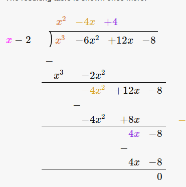

The rest can be factored by inspection:
$$\begin{align*}
f(x) = (x-2)(x^2-4x+4) = (x-2)^3
.\end{align*}$$

## 11.1 Definitions

The main powerhouse: for $T:V\to V$ a linear transformation for $V\in{ \mathsf{Vect} }_k$, map to $V\in \mathsf{k[x]}{\hbox{-}}\mathsf{Mod}$ by letting polynomials act via $p(x)\cdot \mathbf{v} \mathrel{\vcenter{:}}= p(T)(\mathbf{v})$. Using that $k[x]$ is a PID iff $k$ is a field, and we can apply the FTFGMPID to get two decompositions:
$$\begin{align*}
V &\cong \bigoplus_{i=1}^n k[x]/ \left\langle{ q_i(x) }\right\rangle && q_{i}(x) \divides q_{i+1}(x) \divides \cdots \\
V &\cong \bigoplus _{j=1}^m k[x] / \left\langle{ p_i(x)^{e_i} }\right\rangle && \text{ with } p_i \text{ not necessarily distinct.}
\end{align*}$$

- The $q_i$ are the **invariant factors** of $T$
  - $q_i$ is the minimal polynomial of $T$ restricted to $V_i \mathrel{\vcenter{:}}= k[x] / \left\langle{ q_i(x) }\right\rangle$.
  - The largest invariant factor $q_n$ is the **minimal polynomial** of $T$.
  - The product $\prod_{i=1}^n q_i(x)$ is the **characteristic polynomial** of $T$.
- The $p_i$ are the **elementary divisors** of $T$.
  - Todo: what can you read off of this…?

A matrix $A\in \operatorname{Mat}(n\times n; {\mathbb{C}})$ is **normal** iff $A^{\dagger} A = AA^{\dagger}$ where $A^{\dagger}$ is the conjugate transpose.

A matrix $A$ over $k$ is **semisimple** iff $A$ is diagonalizable over $k^\mathsf{Alg}$, the algebraic closure.

A matrix $A$ over $k$ is **nilpotent** iff $A^k = 0$ for some $k\geq 1$.

> Idea: upper triangular matrices.

A element $A$ in a ring $R$ is **unipotent** iff $A-1$ is nilpotent.

> Idea: an upper-triangular matrix with ones on the diagonal.

Any linear map $T:V\to V$ over a perfect field decomposes as $T = S + N$ with $S$ semisimple (diagonal), $N$ nilpotent, and $[DN] = 0$. If $T$ is invertible, then $T$ decomposes as $T = SU$ where $S$ is semisimple, $U$ is unipotent, and $[UN] = 0$.

$$\begin{align*}
\qty{ \sum W_i}^\perp = \displaystyle\bigcap\qty{W_i^\perp}
.\end{align*}$$

Two matrices $A,B$ are **similar** (i.e. $A = PBP^{-1}$) $\iff A,B$ have the same Jordan Canonical Form (JCF).

Two matrices $A, B$ are **equivalent** (i.e. $A = PBQ$) $\iff$

- They have the same rank,
- They have the same invariant factors, *and*
- They have the same (JCF)

### 11.1.1 Matrix Groups

$$\begin{align*}
\operatorname{GL}_n({\mathbb{R}}) = \left\{{ A {~\mathrel{\Big|}~}A = \mkern 1.5mu\overline{\mkern-1.5muA\mkern-1.5mu}\mkern 1.5mu }\right\}
.\end{align*}$$

$$\begin{align*}
{\operatorname{SL}}_n({\mathbb{C}}) \mathrel{\vcenter{:}}=\left\{{ A {~\mathrel{\Big|}~}\operatorname{det}A = 1 }\right\}
.\end{align*}$$

$$\begin{align*}
O_n({\mathbb{C}}) \mathrel{\vcenter{:}}=\left\{{ A {~\mathrel{\Big|}~}A^tA = A A^t = I}\right\}
.\end{align*}$$

Dimension: $n(n-1) / 2$.

$$\begin{align*}
{\operatorname{SO}}_n({\mathbb{R}}) = \left\{{ A {~\mathrel{\Big|}~}AA^t = I}\right\} = \ker(\operatorname{GL}_n({\mathbb{R}}) \to k^{\times})
.\end{align*}$$

$$\begin{align*}
U_n({\mathbb{C}}) \mathrel{\vcenter{:}}=\left\{{ A {~\mathrel{\Big|}~}A^\dagger A = AA^\dagger = 1 }\right\}
.\end{align*}$$

$$\begin{align*}
{\operatorname{SU}}_n({\mathbb{C}}) \mathrel{\vcenter{:}}=\left\{{ A \in U_n({\mathbb{C}}) {~\mathrel{\Big|}~}\operatorname{det}A = 1 }\right\}
.\end{align*}$$

$$\begin{align*}
\mathrm{Sp}_{2n}({\mathbb{C}}) \mathrel{\vcenter{:}}=\left\{{ A \in \operatorname{GL}_{2n}({\mathbb{C}}) {~\mathrel{\Big|}~}A^tJA = J }\right\} &&
J \mathrel{\vcenter{:}}=
\begin{bmatrix}
0 & 1_n
\\
1_n & 0
\end{bmatrix}
.\end{align*}$$

## 11.2 Minimal / Characteristic Polynomials

A trick for finding characteristic polynomials:
$$\begin{align*}
\chi_A(t) &= \sum_{k=0}^n (-1)^k \operatorname{tr}\qty{\bigwedge\nolimits^k A} t^{n-k} \\
&= t^n - \operatorname{tr}\qty{A} t^{n-1} + \operatorname{tr}\qty{\bigwedge\nolimits^2 A}t^{n-2} - \cdots \pm \operatorname{tr}\qty{\bigwedge\nolimits^{n-1} A} t \mp \operatorname{det}(A)
,\end{align*}
using that$$

$$\begin{align*}
{\bigwedge\nolimits^0 A} \mathrel{\vcenter{:}}= 1 \\
{\bigwedge\nolimits^1 A} \mathrel{\vcenter{:}}= A \\
\operatorname{tr}\qty{\bigwedge\nolimits^n A} = \operatorname{det}(A)
.\end{align*}$$

Moreover, the intermediate traces are easy to compute by hand:
$$\begin{align*}
\operatorname{tr}\qty{\bigwedge\nolimits^\ell A} = \sum \operatorname{det}\qty{M^{\ell}}
,\end{align*}
where the sum is taken over all \(\ell\times\ell\) principal minors: determinants of the \(n \choose \ell\) principal matrices which are obtained by choosing \(\ell\) diagonal entries to keep and and deleting the rows and columns for every entry not chosen. Equivalently, one can select \(n-\ell\) diagonal entries and delete the corresponding row/column for each.$$

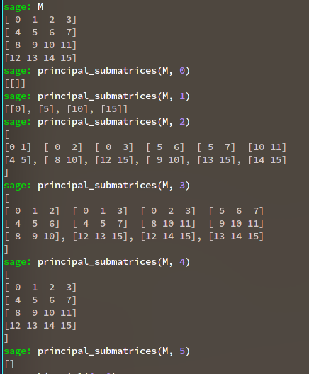

To factor this polynomial, the **rational roots test** can be useful: for $f(t) = a_nt^n + \cdots + a_1 t + a_0$, rational roots are of the form $p/q$ where $p \divides a_n$ and $q\divides a_0$. Note that this simplifies greatly for $f$ monic! Once you have a root, apply **polynomial long division** to get a smaller problem, and hopefully this continues to work until it’s factored.

Fix some notation:
$$\begin{align*}
\min_A(x): \quad & \text{The minimal polynomial of } A \\
\chi_A(x): \quad & \text{The characteristic polynomial of } A
.\end{align*}$$

The **minimal polynomial** of a linear map $T$ is the unique monic polynomial $\min_T(x)$ of minimal degree such that $\min_T(T) = 0$.

The **characteristic polynomial** of $A$ is given by
$$\begin{align*}
\chi_A(x) = \operatorname{det}(A - xI))= \operatorname{det}(SNF(A - xI))
.\end{align*}$$

If $A$ is upper triangular, then $\operatorname{det}(A) = \prod_{i} a_{ii}$

The minimal polynomial divides the characteristic polynomial, and in particular $\chi_A(A) = 0$.

**(Click to expand proof)**

By minimality, $\min_A$ divides $\chi_A$. Every $\lambda_i$ is a root of $\min_A(x)$: Let $(\mathbf{v}_i, \lambda_i)$ be a nontrivial eigenpair. Then by linearity,
$$\begin{align*}
\min_A(\lambda_i)\mathbf{v}_i = \min_A(A)\mathbf{v}_i = \mathbf{0}
,\end{align*}
which forces \(\min_A(\lambda_i) = 0\).$$

## 11.3 Finding Minimal Polynomials

Let $m(x)$ denote the minimal polynomial $A$.

1. Find the characteristic polynomial $\chi(x)$; this annihilates $A$ by Cayley-Hamilton. Then $m(x) \divides \chi(x)$, so just test the finitely many products of irreducible factors.
2. Pick any $\mathbf{v}$ and compute $T\mathbf{v}, T^2\mathbf{v}, \cdots T^k\mathbf{v}$ until a linear dependence is introduced. Write this as $p(T) = 0$; then $\min_A(x) \divides p(x)$.

## 11.4 Other Canonical Forms

Let $T:V\to V$ be a linear map where $n\mathrel{\vcenter{:}}=\dim_k V$. TFAE:

- There exists a basis $\left\{{ e_i }\right\}$ of $V$ such that
  $$\begin{align*}
  T(e_i) =
  \begin{cases}
  e_{i-1} & i \geq 2
  \\
  0 & i=1.
  \end{cases}
  \end{align*}$$
- There exists a cyclic vector $\mathbf{v}$ such that $\left\{{ T^k \mathbf{v} {~\mathrel{\Big|}~}k=1,2,\cdots, n}\right\}$ form a basis for $V$.
- $T^{n-1} \neq 0$
- $\dim_k \ker T^\ell = \ell$ for each $1\leq \ell \leq n$.
- $\dim_k \ker T = 1$.

### 11.4.1 Rational Canonical Form

Corresponds to the **Invariant Factor Decomposition** of $T$.

Given a monic $p(x) = a_0 + a_1 x + a_2 x^2 + \cdots + a_{n-1} x^{n-1} + x^n$, the **companion matrix** of $p$ is given by
$$\begin{align*}
C_p \mathrel{\vcenter{:}}=
\begin{bmatrix}
0 & 0 & \dots & 0 &-a_0 \\
1 & 0 & \dots & 0 & -a_1 \\
0 & 1 & \dots & 0 & -a_2 \\
\vdots & & \ddots & & \vdots \\
0 & 0 & \dots & 1 & -a_{n-1}
\end{bmatrix}
.\end{align*}$$

Let $V$ be finite dimensional and $T\in \operatorname{GL}(V)$. TFAE:

- $V\cong k[x] / \left\langle{p}\right\rangle$ as a $k[x]{\hbox{-}}$module.
- $V$ admits a cyclic vector $\mathbf{v}$ where $p(x)$ is minimal degree monic polynomial such that $p(x)\curvearrowright\mathbf{v} = 0$
- $V$ is a cyclic $k[x]{\hbox{-}}$module with annihilator ideal generated by $p(x)$.
- $T$ is similar to the companion matrix of $p(x)$.
- $\min_T(x) = \chi_T(x)$.
- $T$ has exactly one invariant factor.
- $\operatorname{RCF}(T)$ has a single block.

$\chi_A(x) = \min_A(x)$ iff $A$ admits a cyclic vector.

**(Click to expand proof)**

$\not\implies$: In general, $\min_A \divides \chi_A$, so suppose they’re not equal. Set $n\mathrel{\vcenter{:}}=\deg \chi_A$, then if $n' \mathrel{\vcenter{:}}=\deg \min_A < n$, using that $\min_A(A) = 0$ this exhibits a linear dependence in $\left\{{v, Av, \cdots, A^{n'} v}\right\}$ for any $v$. In particular, since $n>n'$, any set $\left\{{v, Av,\cdots,A^nv}\right\}$ has a linear dependence.

$\implies$: Apply the structure theorem to write $V\cong \bigoplus_{i=1}^m k[x]/\left\langle{p_i}\right\rangle$. Since $\chi_A(x) = \prod p_i(x)$ and $\min_A(x) = p_m(x)$, this forces $m=1$ – one way to see this is that $\dim_k V = \sum_{i=1}^m \dim_k k[x]/\left\langle{p_i}\right\rangle$, where $\deg \chi_A = \dim_k V$ and $\deg \min_A = \dim k[x]/\left\langle{p_m}\right\rangle$. For these to be equal, this forces $\dim_k k[x]/\left\langle{p_i}\right\rangle = 0$ for $1\leq i \leq m-1$, making $V$ a cyclic $k[x]{\hbox{-}}$module. So $V = k[x]\curvearrowright\mathbf{v}$ for some $\mathbf{v}\in V$, which is the desired cyclic vector, and
$$\begin{align*}
V = \left\{{f(x).v {~\mathrel{\Big|}~}f\in k[x]}\right\} = {\operatorname{span}}_k\left\{{A^k v {~\mathrel{\Big|}~}k\geq 0}\right\}
.\end{align*}
By Cayley-Hamilton, \(\chi_A(A) = 0\) and so \(A^n\) is a linear combinations of \(A^k\) for \(0\leq k \leq n-1\), so \(V= {\operatorname{span}}_k \left\{{A^k v {~\mathrel{\Big|}~}0\leq k \leq n-1}\right\}\).$$

$\operatorname{RCF}(A)$ is a block matrix where each block is the companion matrix of an invariant factor of $A$.

Thus the blocks of $\operatorname{RCF}(A)$ biject with invariant factors of $A$. Note that any companion matrix is already in $\operatorname{RCF}$.

**(Click to expand proof)**

- Let $k[x] \curvearrowright V$ by $p(x) \curvearrowright\mathbf{v} \mathrel{\vcenter{:}}= p(T)(\mathbf{v})$, making $V$ into a finitely generated torsion $k[x]{\hbox{-}}$module.
  - Note that $k[x]{\hbox{-}}$submodules are exactly $T{\hbox{-}}$invariant subspaces.
- $k$ a field implies $k[x]$ a PID, so apply structure theorem to obtain an invariant factor decomposition
  $$\begin{align*}
  V \cong k[x] / \left\langle{\chi_T(x)}\right\rangle \cong \bigoplus_{i=1}^m k[x] / \left\langle{ p_i(x) }\right\rangle
  && p_1(x) \divides p_2(x) \divides \cdots p_m(x)
  .\end{align*}$$
- Since each factor is submodule, each corresponds to a $T{\hbox{-}}$invariant subspace $V_i$ where $p_i$ is the minimal polynomial of $T$ restricted to $V_i$.
  - The largest invariant factor $p_m$ is the minimal polynomial of $T$, their product is the characteristic polynomial. This follows because $p_m(x)\curvearrowright V = 0$, since $p_i\divides p_m$ for all $i$, forcing $\min_A \divides p_m$ by minimality.
- Write $V \cong \bigoplus_{i=1}^m V_i$ as a $k[x]{\hbox{-}}$module, where $V_i \mathrel{\vcenter{:}}= k[x] / \left\langle{ p_i(x) }\right\rangle$, then $T$ is a block matrix $\bigoplus_{i=1}^m T_i$ where $T_i$ is the restriction of $T$ to $V_i$:
  $$\begin{align*}
  \left(\begin{array}{ccccc}T_{1} & 0 & 0 & \cdots & 0 \\ 0 & T_{2} & 0 & \cdots & 0 \\ \vdots & & \ddots & & \vdots \\ 0 & \cdots & & & T_{n}\end{array}\right)
  .\end{align*}$$
- It suffices to determine the form of a single $M_i$, so without loss of generality suppose $m=1$ so $V = V_1 = k[x] / \left\langle{ p(x) }\right\rangle$ is a cyclic $k[x]{\hbox{-}}$module with $\deg p(x) = n$.
- $\chi_M(x) = \min_M(x) \iff$ there exists a cyclic vector $\mathbf{v}$, so the set $\left\{{\mathbf{v}_i}\right\}_{i=0}^{n-1} \mathrel{\vcenter{:}}=\left\{{ \mathbf{v}, T\mathbf{v}, T^2\mathbf{v}, \cdots, T^{n-1}\mathbf{v} }\right\}$ is a basis for $V_1$.
  - If there is any linear independence, this gives a polynomial relation $\sum_{i=1}^{n'} a_iT^i\mathbf{v} = 0$ for some $n'<n$, but then $q(x) \mathrel{\vcenter{:}}=\sum_{i=1}^{n'} a_i x^i$ is a polynomial annihilating $T$, contradicting the minimality of $p(x)$.
  - So this yields $n$ linearly independent vectors in $k^n$, so it’s a basis.
- What is $M_i$ in this basis? Check where basis elements are mapped to by $T$, noting that
  $$\begin{align*}
  p(T) = \sum_{i=1}^{n}a_i T^i\mathbf{v} = T^n + a_{n-1} T^{n-1}\mathbf{v} + a_{n-2} T^{n-2} + \cdots + a_1 T\mathbf{v} + a_0 \mathbf{v} = 0
  ,\end{align*}
  using the minimal polynomial we can write$$
  - $T\mathbf{v}_0 = \mathbf{v}_1$
  - $T\mathbf{v}_2 = T^2 \mathbf{v}_0$
  - $T\mathbf{v}_3 = T^3 \mathbf{v}_0$
  - $\cdots$
  - $T\mathbf{v}_{n-2} = T^{n-1}\mathbf{v}$
  - $T\mathbf{v}_{n-1} = T^n\mathbf{v} = -a_{n-1}T^{n-1}\mathbf{v} - \cdots - a_1 T\mathbf{v} - a_0 \mathbf{v}$
- So we have
  $$\begin{align*}
  M_1 =
  \begin{bmatrix}
  0 & & & & -a_0 \\
  1 & 0 & & & -a_1 \\
  & 1 & 0& & -a_2 \\
  & & \ddots & 0 & \vdots \\
  & & & 1 & -a_{n-1}
  \end{bmatrix}
  .\end{align*}$$

### 11.4.2 Smith Normal Form

For $A\in \operatorname{Mat}(m\times n; R)$ over $R$ any PID, $\mathrm{SNF}(A)$ is a matrix whose diagonal entries are the invariant factors. How to compute $\mathrm{SNF}(A)$: take $A = \operatorname{diag}(a_i)$ where $a_i = d_i/d_{i-1}$ and $d_i$ is the $\gcd$ of the determinants of all $i\times i$ minors of $A$. $A\sim B$ are similar $\iff \mathrm{SNF}(A) = \mathrm{SNF}(B)$.

### 11.4.3 Using Canonical Forms

The characteristic polynomial is the *product of the invariant factors*, i.e.
$$\begin{align*}
\chi_A(x) = \prod_{j=1}^n f_j(x)
.\end{align*}$$

The minimal polynomial of $A$ is the *invariant factor of highest degree*, i.e.
$$\begin{align*}
\min_A(x) = f_n(x)
.\end{align*}$$

For a linear operator on a vector space of nonzero finite dimension, TFAE:

- The minimal polynomial is equal to the characteristic polynomial.
- The list of invariant factors has length one.
- The Rational Canonical Form has a single block.
- The operator has a matrix similar to a companion matrix.
- There exists a *cyclic vector* $\mathbf{v}$ such that ${\operatorname{span}}_k\left\{{T^j \mathbf{v} {~\mathrel{\Big|}~}j = 1, 2, \cdots}\right\} = V.$
- $T$ has $\dim V$ distinct eigenvalues

## 11.5 Diagonalizability

*Notation:* $A^{\dagger}$ denotes the conjugate transpose of $A$.

Let $V$ be a vector space over $k$ an algebraically closed and $A \in \mathrm{End}(V)$. Then if $W \subseteq V$ is an invariant subspace, so $A(W) \subseteq W$, the $A$ has an eigenvector in $W$.

1. Hermitian (self-adjoint) matrices (i.e. $A^{\dagger} = A$) are diagonalizable over ${\mathbb{C}}$.
2. Symmetric matrices (i.e. $A^t = A$) are diagonalizable over ${\mathbb{R}}$.

In fact, $A$ is symmetric $\iff \operatorname{Spec}A$ forms an orthonormal basis.

**(Click to expand proof)**

- Suppose $A$ is Hermitian.
- Since $V$ itself is an invariant subspace, $A$ has an eigenvector $\mathbf{v}_1 \in V$.
- Let $W_1 = {\operatorname{span}}_k\left\{{\mathbf{v}_1}\right\}\perp$.
- Then for any $\mathbf{w}_1 \in W_1$,
  $$\begin{align*}
  {\left\langle {\mathbf{v}_1},~{ A \mathbf{w}_1} \right\rangle} =
  {\left\langle {A \mathbf{v}_1},~{\mathbf{w}_1} \right\rangle} =
  \lambda {\left\langle {\mathbf{v}_1},~{\mathbf{w}_1} \right\rangle} = 0,
  \end{align*}
  so \(A(W_1) \subseteq W_1\) is an invariant subspace, etc.$$
- Suppose now that $A$ is symmetric.
- Then there is an eigenvector of norm 1, $\mathbf{v} \in V$.
  $$\begin{align*}
  \lambda = \lambda{\left\langle {\mathbf{v}},~{\mathbf{v}} \right\rangle} = {\left\langle {A\mathbf{v}},~{\mathbf{v}} \right\rangle} = {\left\langle {\mathbf{v}},~{A\mathbf{v}} \right\rangle} = \overline{\lambda} \implies \lambda \in {\mathbb{R}}
  .\end{align*}$$

A set of operators $\left\{{A_i}\right\}$ pairwise commute $\iff$ they are all simultaneously diagonalizable.

**(Click to expand proof)**

By induction on number of operators

- $A_n$ is diagonalizable, so $V = \bigoplus E_i$ a sum of eigenspaces
- Restrict all $n-1$ operators $A$ to $E_n$.
- The commute in $V$ so they commute in $E_n$
- **(Lemma)** They were diagonalizable in $V$, so they’re diagonalizable in $E_n$
- So they’re simultaneously diagonalizable by I.H.
- But these eigenvectors for the $A_i$ are all in $E_n$, so they’re eigenvectors for $A_n$ too.
- Can do this for each eigenspace.

> [Full details here](https://kconrad.math.uconn.edu/blurbs/linmultialg/minpolyandappns.pdf#page=9)

$M$ is diagonalizable over ${\mathbb{F}}\iff \min_M(x, {\mathbb{F}})$ splits into distinct linear factors over ${\mathbb{F}}$, or equivalently iff all of the roots of $\min_M$ lie in ${\mathbb{F}}$.

**(Click to expand proof)**

$\implies$: If $\min_A$ factors into linear factors, so does each invariant factor, so every elementary divisor is linear and $JCF(A)$ is diagonal.

$\impliedby$: If $A$ is diagonalizable, every elementary divisor is linear, so every invariant factor factors into linear pieces. But the minimal polynomial is just the largest invariant factor.

## 11.6 Matrix Counterexamples

A matrix that:

- Is not diagonalizable over ${\mathbb{R}}$ but diagonalizable over ${\mathbb{C}}$
- Has *no* eigenvalues over ${\mathbb{R}}$ but has *distinct* eigenvalues over ${\mathbb{C}}$
- $\min_M(x) = \chi_M(x) = x^2 + 1$

$$\begin{align*}
M = \left(\begin{array}{rr}
0 & 1 \\
-1 & 0
\end{array}\right) \sim
\left(\begin{array}{r|r}
-1 \sqrt{-1} & 0 \\
\hline
0 & 1 \sqrt{-1}
\end{array}
\right)
.\end{align*}$$

A matrix that:

- Is not diagonalizable over ${\mathbb{C}}$,
- Has eigenvalues $[1, 1]$ (repeated, multiplicity 2)
- $\min_M(x) = \chi_M(x) = x^2-2x+1$

$$\begin{align*}
M = \left(\begin{array}{rr}
1 & 1 \\
0 & 1
\end{array}\right)
\sim
\left(
\begin{array}{rr}
1 & 1 \\
0 & 1
\end{array}
\right)
.\end{align*}$$

A full-rank matrix that is not diagonalizable:
$$\begin{align*}
\left(
\begin{array}{ccc}
1 & 1 & 0 \\
0 & 1 & 1 \\
0 & 0 & 1 \\
\end{array}
\right)
.\end{align*}$$

Matrix roots of unity, i.e. representations of $i$:
$$\begin{align*}
M_1
\mathrel{\vcenter{:}}=
{
\begin{bmatrix}
{0} & {-1}
\\
{1} & {0}
\end{bmatrix}
} \quad
M_2
\mathrel{\vcenter{:}}=
{
\begin{bmatrix}
{0} & {1}
\\
{-1} & {0}
\end{bmatrix}
}
.\end{align*}$$

### 11.6.1 Counting

$$\begin{align*}
{\left\lvert {\operatorname{GL}_n({\mathbb{F}}_p)} \right\rvert} = (p^n-1)(p^n-p)(p^n-p^2)\cdots(p^n - p^{n-1})
.\end{align*}$$

It suffices to count ordered bases of ${\mathbb{F}}_p^n$:

- Choose $\mathbf{v}_1$: there are $p$ choices for each coefficient, but leave out the vector $0$, so $p^n-1$ choices.
- Choose any $\mathbf{v}_2 \neq \lambda \mathbf{v}_1$, so $p^n-p$ choices.
- Choose any nonzero $\mathbf{v}_3 \neq \lambda \mathbf{v}_1 + \eta \mathbf{v}_2$, so $p^n-p^2$ choices.
- Etc.

## 11.7 Exercises

Show that normal matrices are diagonalizable.

Consider the Vandermonde matrix:
$$\begin{align*}
A \mathrel{\vcenter{:}}=
\left(\begin{array}{ccc}
1 & \cdots & 1 \\
\lambda_{1} & \cdots & \lambda_{k} \\
\vdots & & \vdots \\
\lambda_{1}^{k-1} & \cdots & \lambda_{k}^{k-1}
\end{array}\right)
.\end{align*}$$

Show that
$$\begin{align*}
\operatorname{det}A = \prod_{i < j} (\lambda_i - \lambda_j)
.\end{align*}$$

Show that a nonzero nilpotent matrix $A$ is not diagonalizable over any field. Some useful facts:

- $\operatorname{Spec}A = \left\{{0}\right\}$, since $Ax=\lambda x \implies A^n=\lambda^nx$, so $A^n=0$ forces $\lambda =0$. This forces $\operatorname{JCF}(A)$ to be strictly upper-triangular.
- $\min_A(x) = x^n$.
- If $A$ were diagonalizable, $\operatorname{JCF}(A) = 0$.

Prove Cayley-Hamilton in the following way. Let $V = {\operatorname{span}}\left\{{\mathbf{v}_1, \cdots, \mathbf{v}_n}\right\}$ and define the $i$th flag as ${\operatorname{Fil}}_i V \mathrel{\vcenter{:}}={\operatorname{span}}\left\{{\mathbf{v}_1, \cdots, \mathbf{v}_i}\right\}$ for all $1\leq i \leq n$, and set ${\operatorname{Fil}}_0 V \mathrel{\vcenter{:}}=\left\{{0}\right\}$. Show that if if $A$ is upper triangular, then $A({\operatorname{Fil}}_i V) \subseteq {\operatorname{Fil}}_i V$. Now supposing $\mathbf{v}_i$ are eigenvectors for $\lambda_i$, show that
$$\begin{align*}
(A-\lambda_n I) {\operatorname{Fil}}_n V &\subseteq {\operatorname{Fil}}_{n-1} V \\
(A-\lambda_{n-1} I) (A-\lambda_n I ) {\operatorname{Fil}}_n V &\subseteq {\operatorname{Fil}}_{n-2} V \\
&\vdots \\
\prod_i (A-\lambda_{n-i} I) {\operatorname{Fil}}_n V &\subseteq {\operatorname{Fil}}_0 V = \left\{{0}\right\}
.\end{align*}
Conclude that \(\chi_A(A) = 0\).$$